# G Luku 1 Yksinkertainen korrespondenssianalyysi

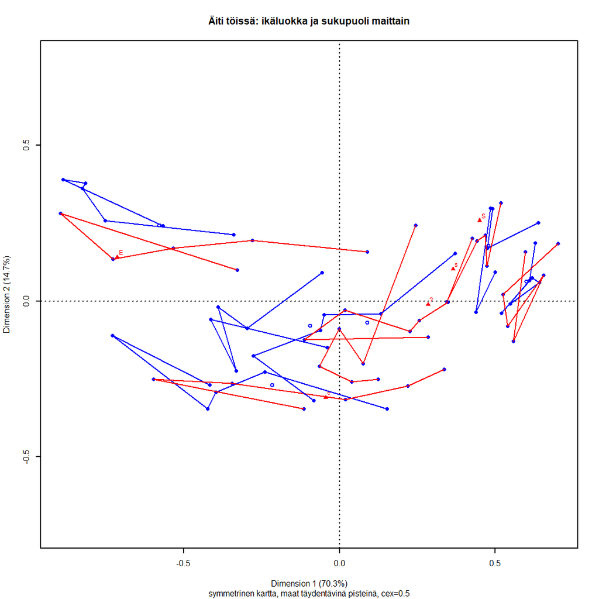

Ikä-sukupuoli-maa

```r
# Onko yhtään vähemmän tukkoinen? Eipä juuri (17.9.20)
par(cex = 0.5)
plot(spCAmaaga1, labels = c(0,2) , main = "Äiti töissä: ikäluokka ja sukupuoli maittain",
                sub = "symmetrinen kartta, maat täydentävinä pisteinä, cex=0.5"
                    )
     lines(maagaLines1[49:54,1],maagaLines1[49:54,2], col="blue") #FIf
     lines(maagaLines1[55:60,1],maagaLines1[55:60,2], col="red")  #FIm
     lines(maagaLines1[25:30,1],maagaLines1[25:30,2], col="blue") #DEf
     lines(maagaLines1[31:36,1],maagaLines1[31:36,2], col="red")  #DEm
     lines(maagaLines1[37:42,1],maagaLines1[37:42,2], col="blue") #DKf
     lines(maagaLines1[43:48,1],maagaLines1[43:48,2], col="red")  #DKm
     lines(maagaLines1[1:6,1],maagaLines1[1:6,2], col="blue") #BEf
     lines(maagaLines1[7:12,1],maagaLines1[7:12,2], col="red")  #BEm
     lines(maagaLines1[13:18,1],maagaLines1[13:18,2], col="blue") #BGf
     lines(maagaLines1[19:24,1],maagaLines1[19:24,2], col="red")  #BGm
     lines(maagaLines1[61:66,1],maagaLines1[61:66,2], col="blue") #HUf
     lines(maagaLines1[67:72,1],maagaLines1[67:72,2], col="red")  #HUm
```

Rivipisteiden tunnisteiden (label) poistaminen tuo pisteparvien ominaisuuden hieman selvemmin esiin. Suomi alimpana ja Tanska ylimpänä vasemmalla ovat melko samanlaisia. Vaihtelu on lähes täysin ensimäisen dimension suuntaan, Molemmilla mailla miesten pisteet ovat oikealla ja alempana. Keskellä Saksan ja Belgian pistejoukoissa vaihtelu toisen dimension suunnassa on jo suurempaa ja miesten pisteet ovat selvästi oikealla verrattuna naisten pisteisiin. Bulgarian ja Unkarin pisteet sijaitsevat kauimpana oikealla, ja vaihtelu on suurimmalta osin toisen dimensio suuntaan, ja pisteet ovat tiukemmin lähellä toisiaan. Kaikissa maissa vanhemmat ikäluokat ovat nuoria konservatiivimsempia, ja kaikissa nuorin ikäluokka on melko konservatiivinen. Keskimmäiset ikäluokat ovat liberaaleimpia. Unkari ja Bulgaria poikkeavat muista selvästi.

## 4.4 Kartan rajaaminen

0. Analyysin voi tehdä vain osalle dataa - vähän kehno ratkaisu, ei yhteyttä koko aineiston antamaan yleiskuvaan muuttujien yhteyksistä.
1. Kartasta voi suurentaa osan käsityönä (“leikkaa ja liimaa”). Toimii, yksinkertainen ja ehkä siksi paras? Mutta ei voi koodata! Sopii eksploratiiviseen vaiheeseen, pdf-kuviin voi liittää kommenteja ja tekstiä jne.
2. BaseR plot-funktiolla voi rakentaa kartan pala kerrallaan ja rajata kuva-alan johonkin kartan osaan. Työlästä, hankalaa? Yllättäen ei, kun asettaa koodilohkon option Rmarkdownissa oikein! (9.9.20). Jos käytetään yhtä ca-funktion tulosobjektia, pelkkiä plot-komentoja.
3. Osajoukon korrespondenssianalyysi (subset ca)

*zxy** Tässä vain lyhyt kuvaus subset ca:n perusideasta

### 4.4.1 Kuva-alueen rajaaminen - ei oikein toimi (16.10.20)

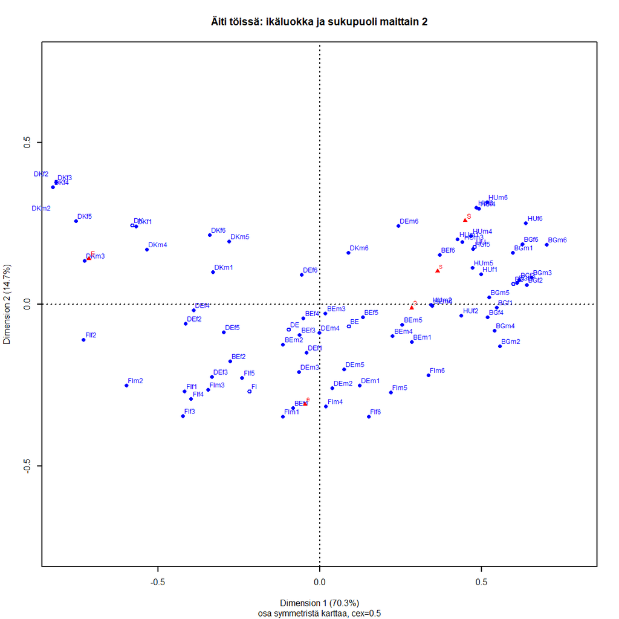

Ikä-sukupuoli-maa

```r
# Zoomaus - esimerkki (24.2.20) xlim=c(-0.5,0.5), ylim=c(-0.6,0.4)
# EI TOIMI - PISTEET piirrettävä, ei voi käyttää ca.plot - funktiota? (4.5.20).
# MG2017 laskarit - day3: mca:n tuloslistaa käytetty luottamusellipseissä ja toimii?
# Piirtää pisteitä koko "plot-alueelle"?

#X11()

# Rivi- ja sarakekoordinaatit (principal coordinates) talteen
maagaCA1.rpc <- spCAmaaga1$rowcoord %*% diag(simpleCA1$sv)
maagaCA1.cpc <- spCAmaaga1$colcoord %*% diag(simpleCA1$sv)
par(cex = 0.5)

plot(spCAmaaga1, xlim = c(-0.75,0.75), ylim = c(-0.75,0.75),
                main = "Äiti töissä: ikäluokka ja sukupuoli maittain 2",
                sub = "osa symmetristä karttaa, cex=0.5"
                    )
```

```r
# TÄTÄ KEHITELLÄÄ CAcalc_1.R - skriptissä (15.6.20)
# ei toimi ihan toivotulla tavalla - tarkoitettu komentoriviltä
# grafiikkaikkunaan tulostukseen ?
# Vai pitääkö ensin piirtää kuvan "kehys" ilman pisteitä xlim- ja ylim- parametreilla
# ja sitten vasta pisteet?
# Kuvasuhde oikein, kun xlim = ylim, miten turhat pisteet pois? (29.5.20).Menevät
# näköjään kuva-alueen ja ulomman marginaalin väliin.

# Voisiko valita objektista vain osan pisteistä? Tai plot ilman tulostusta, tulos
# objektiin ja sieltä pisteet kuvaan? (29.5.20)
# str(spCAmaaga1)
```

Ei toimi ihan odotetulla tavalla, mutta kuvasuhde näyttäisi olevan molemmissa oikea. Hieman hankala menetelmä.

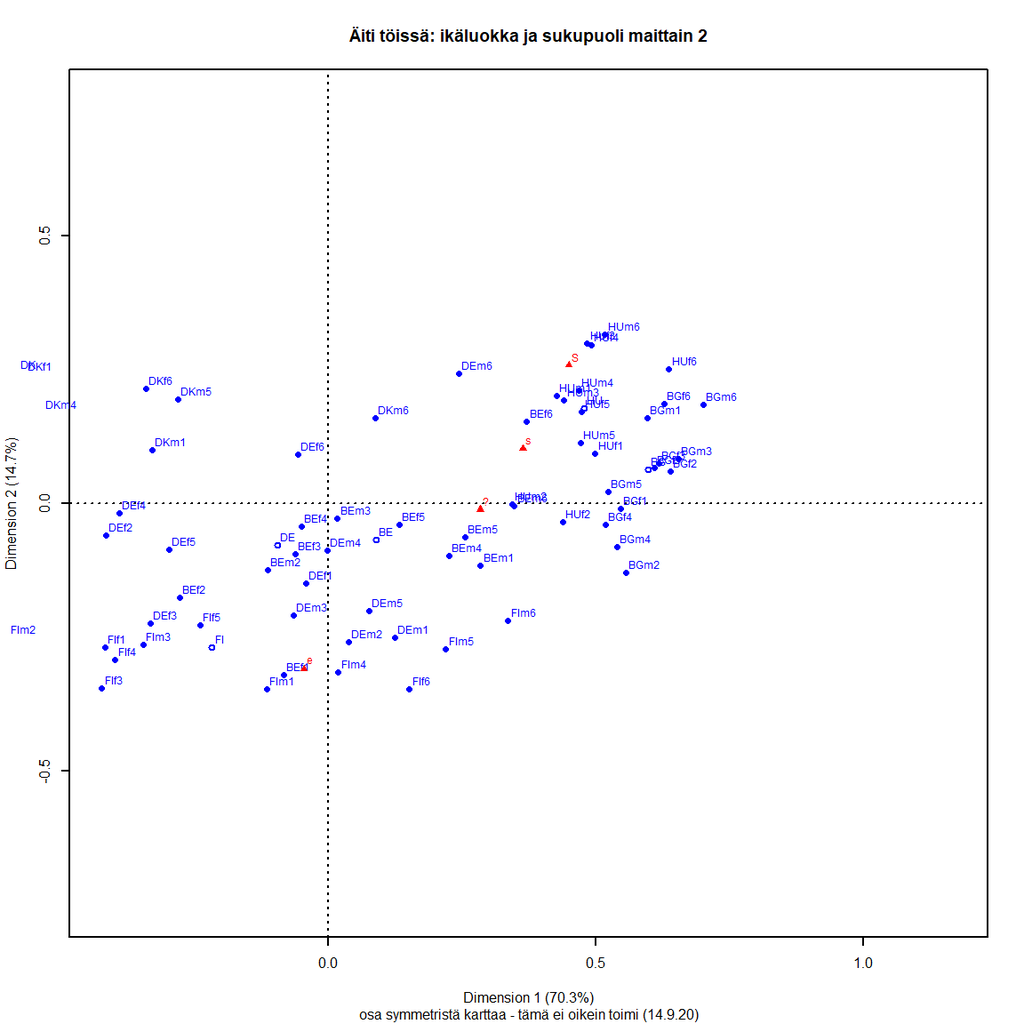

Ikä-sukupuoli-maa

```r
# Zoomaus - esimerkki (24.2.20) xlim=c(-0.5,0.5), ylim=c(-0.6,0.4)
# EI TOIMI - PISTEET piirrettävä, ei voi käyttää ca.plot - funktiota? (4.5.20).
# MG2017 laskarit - day3: mca:n tuloslistaa käytetty luottamusellipseissä ja toimii?
# Piirtää pisteitä koko "plot-alueelle"?


# Rivi- ja sarakekoordinaatit (principal coordinates) talteen
maagaCA1.rpc <- spCAmaaga1$rowcoord %*% diag(simpleCA1$sv)
maagaCA1.cpc <- spCAmaaga1$colcoord %*% diag(simpleCA1$sv)
par(cex = 0.5)

plot(spCAmaaga1, xlim = c(0,0.75), ylim = c(-0.75,0.75),
                main = "Äiti töissä: ikäluokka ja sukupuoli maittain 2",
                sub = "osa symmetristä karttaa - tämä ei oikein toimi (14.9.20)"
                    )
```

```r
# TÄTÄ KEHITELLÄÄ CAcalc_1.R - skriptissä (15.6.20)
# ei toimi ihan toivotulla tavalla - tarkoitettu komentoriviltä
# grafiikkaikkunaan tulostukseen ?
# Vai pitääkö ensin piirtää kuvan "kehys" ilman pisteitä xlim- ja ylim- parametreilla
# ja sitten vasta pisteet?
# Kuvasuhde oikein, kun xlim = ylim, miten turhat pisteet pois? (29.5.20).Menevät
# näköjään kuva-alueen ja ulomman marginaalin väliin.

# Voisiko valita objektista vain osan pisteistä? Tai plot ilman tulostusta, tulos
# objektiin ja sieltä pisteet kuvaan? (29.5.20)
# str(spCAmaaga1)
```

Rivipisteiden inertia on suurempi kuin sarakkeiden. Asymmetrinen kartta näyttää sarakkeet selvemmin.

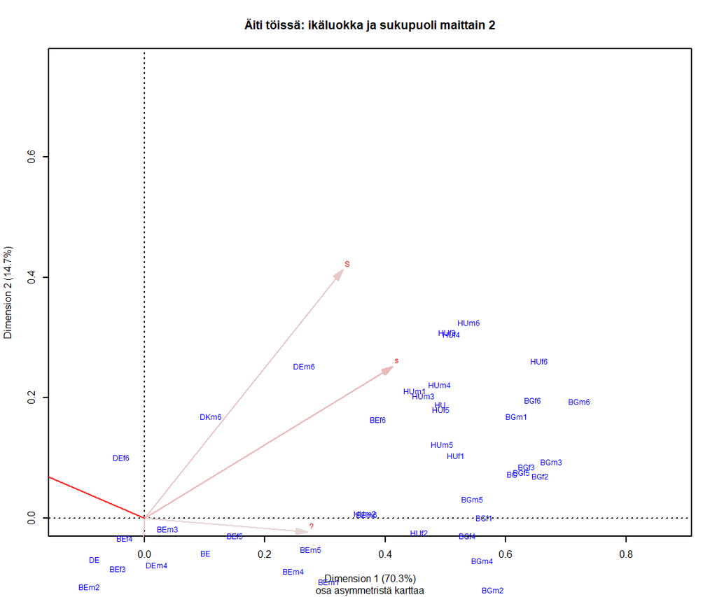

Ikä-sukupuoli-maa

```r
# Zoomaus - esimerkki (24.2.20) xlim=c(-0.5,0.5), ylim=c(-0.6,0.4)
# EI TOIMI - PISTEET piirrettävä, ei voi käyttää ca.plot - funktiota? (4.5.20).
# MG2017 laskarit - day3: mca:n tuloslistaa käytetty luottamusellipseissä ja toimii?
# Piirtää pisteitä koko "plot-alueelle"?


# Rivi- ja sarakekoordinaatit (principal coordinates) talteen
# maagaCA1.rpc <- spCAmaaga1$rowcoord %*% diag(simpleCA1$sv)
# maagaCA1.cpc <- spCAmaaga1$colcoord %*% diag(simpleCA1$sv)

par(cex = 0.5)
plot(spCAmaaga1, map = "rowgreen",
        contrib = c("absolute", "absolute"),
        mass = c(TRUE,TRUE),
        arrows = c(FALSE,TRUE),
        xlim = c(0,0.75), ylim = c(0,0.75),
        main = "Äiti töissä: ikäluokka ja sukupuoli maittain 2",
        sub = "osa asymmetristä karttaa"
        )
```

```r
# TÄTÄ KEHITELLÄÄ CAcalc_1.R - skriptissä (15.6.20)
# ei toimi ihan toivotulla tavalla - tarkoitettu komentoriviltä
# grafiikkaikkunaan tulostukseen ?
# Vai pitääkö ensin piirtää kuvan "kehys" ilman pisteitä xlim- ja ylim- parametreilla
# ja sitten vasta pisteet?
# Kuvasuhde oikein, kun xlim = ylim, miten turhat pisteet pois? (29.5.20).Menevät
# näköjään kuva-alueen ja ulomman marginaalin väliin.

# Voisiko valita objektista vain osan pisteistä? Tai plot ilman tulostusta, tulos
# objektiin ja sieltä pisteet kuvaan? (29.5.20)
# str(spCAmaaga1)
```

Edellinen kartta on vähän epäilyttävä, asettuvatkohan skaalatut sarakevektorin oikein? (9.9.20) ***

## 4.5 Subset CA

Teoria esitetään myöhemnmin, käytännön hyödyllisyys osoitetaan tässä. CA-kartoissa on usein aivan liian paljon pisteitä, vain karkeat yleispiirteet näkyvät. Ovatko kiinnostavat asia piilossa? “Poikkeavat havainnot ovat ainoita todella kiinnostavia havaintoja”.

**Data** Ensimmäinen osajoukko-ca käyttää datan perustiedostoa (ISSP2012esim2.dat). Maa-rivit ovat mukana kokonaislukumatriisissa maagaTab1.

Datassa maa-sukupuoli-ikäluokkarivit ovat näillä riveillä: BE 1-12, BG 13-24, DE 25-36, DK 37-48, FI 49-60, HU 61-72 . Maa-profiilit ovat taulukon(matriisin) maagaTab1 riveillä 73-78 samassa järjestyksessä. **edit 9.9.20** Tarkistettava, miten ca-funktio laskee täydentävien rivien koordinaatit, kun riveistä otetaan analyysiin vain osa.

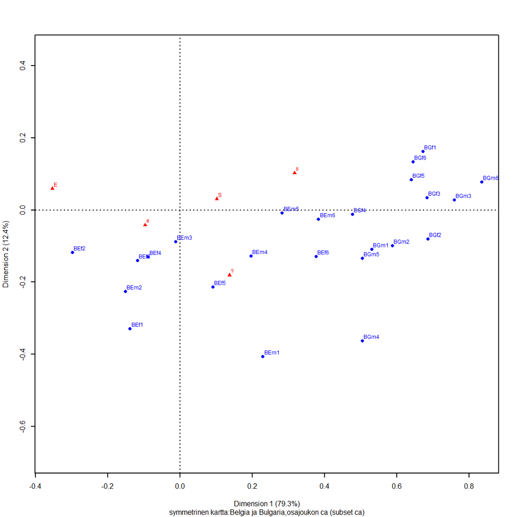

Ikä, sukupuoli ja maa

```r
#31.8.20 Testataan subset ca
#ISSP2012esim2.dat %>% tableX(maaga, Q1b)
maagaCA2subset1BEBG <- ca(~maaga + Q1b,ISSP2012esim1b.dat, subsetrow = 1:24)
par(cex = 0.5)
plot(maagaCA2subset1BEBG,
                sub = "symmetrinen kartta:Belgia ja Bulgaria,osajoukon ca (subset ca)"
        )
```

```r
# main = "Äiti töissä: ikäluokka ja sukupuoli maittain" mikä on plot-funktion
# title-asetusten ja koodilohkon asetusten suhde? Ainakin plot-funkiton
# main = "Äiti töissä: ikäluokka ja sukupuoli maittain" korvaa koodilohkossa
# määritellyn (9.9.20). R-markdownissa kuvan pääotsikko putoaa kokonaan pois,
# mitenköhän tulosteissa?
```

Yhdistetään pisteitä.

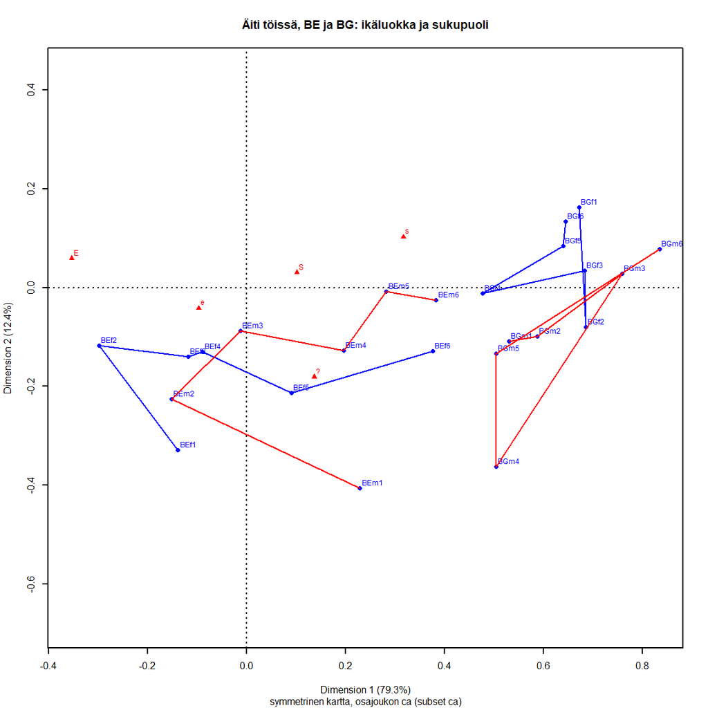

```r
# CA- tulosobjekti maagaCA2subset1

maagaLinesBEBG <- cacoord(maagaCA2subset1BEBG, type = "symmetric")
maagaLinesBEBG <- maagaLinesBEBG$rows[ , 1:2]
par(cex = 0.5)
plot(maagaCA2subset1BEBG,main = "Äiti töissä, BE ja BG: ikäluokka ja sukupuoli",
                sub = "symmetrinen kartta, osajoukon ca (subset ca)"
        )
lines(maagaLinesBEBG[1:6,1],maagaLinesBEBG[1:6,2], col="blue") #BEf
lines(maagaLinesBEBG[7:12,1],maagaLinesBEBG[7:12,2], col="red")  #BEm
lines(maagaLinesBEBG[13:18,1],maagaLinesBEBG[13:18,2], col="blue") #BBGf
lines(maagaLinesBEBG[19:24,1],maagaLinesBEBG[19:24,2], col="red")  #BEm
```

Kartan tulkintaa, kokonaisinertia voidaan esittää maa kerrallaan. (9.9.20)

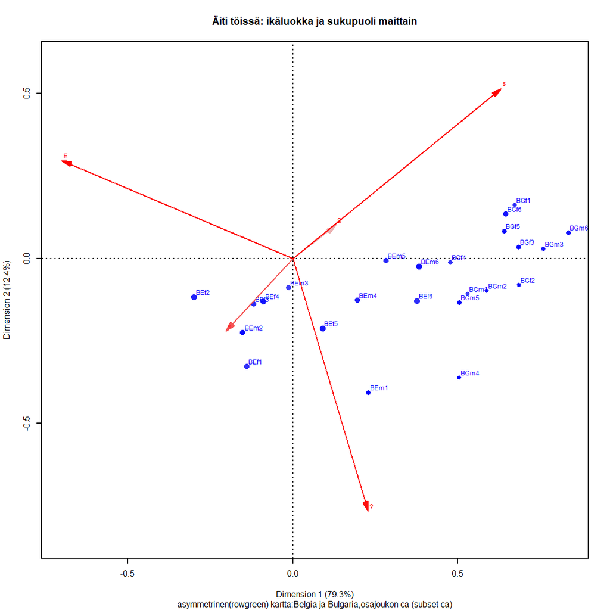

```r
# Datana maagaTab1 - viimeisinä riveinä maarivit

maagaCA2sub1 <- ca(maagaTab1[,1:5], subsetrow = 1:24)
par(cex = 0.5)
plot(maagaCA2sub1, map = "rowgreen",
     contrib = c("relative", "relative"),
     mass = c(TRUE,TRUE),
     arrows = c(FALSE, TRUE),
     main = "Äiti töissä: ikäluokka ja sukupuoli maittain",
     sub = "asymmetrinen(rowgreen) kartta:Belgia ja Bulgaria,osajoukon ca (subset ca)"
        )
```

Lisätään kuvaan täydentävänä (passiivisena) pisteenä Belgian maapiste, tarkistettava tuleeko se “oikeaan” kohtaan. **edit 10.10.20** Ei toimi, maapisteen koordinaatit pitäisi laskea uudelleen. Syy: ca rivien osajoukolle.Maapisteiden osajoukon keskiarvopiste ei ole origo,mutta sarakepisteiden on.

```r
# Datana maagaTab1 - viimeisinä riveinä maarivit
maagaTab1
```

|  | S | s | ? | e | E |
| --- | --- | --- | --- | --- | --- |
| BEf1 | 5 | 15 | 28 | 43 | 25 |
| BEf2 | 10 | 26 | 34 | 66 | 62 |
| BEf3 | 19 | 27 | 33 | 53 | 42 |
| BEf4 | 21 | 34 | 40 | 55 | 49 |
| BEf5 | 21 | 38 | 46 | 48 | 33 |
| BEf6 | 25 | 58 | 50 | 30 | 22 |
| BEm1 | 9 | 19 | 30 | 24 | 10 |
| BEm2 | 10 | 19 | 31 | 40 | 35 |
| BEm3 | 18 | 33 | 31 | 44 | 36 |
| BEm4 | 19 | 46 | 37 | 51 | 23 |
| BEm5 | 15 | 61 | 34 | 49 | 23 |
| BEm6 | 19 | 75 | 44 | 49 | 21 |
| BGf1 | 2 | 21 | 7 | 9 | 1 |
| BGf2 | 7 | 28 | 17 | 12 | 0 |
| BGf3 | 10 | 44 | 21 | 18 | 1 |
| BGf4 | 14 | 30 | 15 | 24 | 2 |
| BGf5 | 16 | 51 | 21 | 25 | 1 |
| BGf6 | 27 | 66 | 26 | 27 | 3 |
| BGm1 | 8 | 12 | 9 | 7 | 1 |
| BGm2 | 4 | 21 | 12 | 14 | 0 |
| BGm3 | 5 | 33 | 16 | 11 | 0 |
| BGm4 | 7 | 19 | 21 | 15 | 1 |
| BGm5 | 12 | 29 | 21 | 19 | 3 |
| BGm6 | 6 | 41 | 19 | 9 | 0 |
| DEf1 | 5 | 28 | 13 | 33 | 23 |
| DEf2 | 9 | 14 | 14 | 37 | 46 |
| DEf3 | 10 | 22 | 12 | 59 | 49 |
| DEf4 | 11 | 31 | 20 | 53 | 71 |
| DEf5 | 8 | 27 | 12 | 43 | 45 |
| DEf6 | 31 | 40 | 15 | 50 | 49 |
| DEm1 | 6 | 26 | 20 | 36 | 15 |
| DEm2 | 7 | 26 | 13 | 39 | 18 |
| DEm3 | 11 | 24 | 15 | 45 | 27 |
| DEm4 | 22 | 39 | 17 | 57 | 37 |
| DEm5 | 11 | 43 | 19 | 54 | 26 |
| DEm6 | 34 | 55 | 28 | 32 | 32 |
| DKf1 | 7 | 11 | 9 | 15 | 41 |
| DKf2 | 4 | 15 | 7 | 13 | 71 |
| DKf3 | 3 | 20 | 15 | 14 | 84 |
| DKf4 | 5 | 24 | 8 | 19 | 90 |
| DKf5 | 6 | 16 | 11 | 22 | 73 |
| DKf6 | 5 | 26 | 11 | 17 | 40 |
| DKm1 | 10 | 21 | 18 | 28 | 47 |
| DKm2 | 2 | 11 | 9 | 16 | 65 |
| DKm3 | 2 | 13 | 12 | 23 | 59 |
| DKm4 | 4 | 24 | 14 | 24 | 59 |
| DKm5 | 11 | 14 | 23 | 18 | 40 |
| DKm6 | 11 | 43 | 15 | 23 | 27 |
| FIf1 | 3 | 9 | 13 | 36 | 33 |
| FIf2 | 5 | 6 | 3 | 34 | 47 |
| FIf3 | 2 | 8 | 13 | 39 | 32 |
| FIf4 | 3 | 15 | 13 | 47 | 40 |
| FIf5 | 6 | 26 | 17 | 52 | 41 |
| FIf6 | 3 | 22 | 21 | 34 | 11 |
| FIm1 | 1 | 9 | 13 | 22 | 13 |
| FIm2 | 2 | 5 | 6 | 28 | 30 |
| FIm3 | 2 | 10 | 9 | 27 | 23 |
| FIm4 | 8 | 23 | 13 | 43 | 18 |
| FIm5 | 5 | 31 | 15 | 35 | 10 |
| FIm6 | 7 | 24 | 13 | 26 | 5 |
| HUf1 | 11 | 13 | 16 | 11 | 3 |
| HUf2 | 15 | 19 | 25 | 22 | 5 |
| HUf3 | 22 | 26 | 26 | 12 | 9 |
| HUf4 | 24 | 25 | 20 | 14 | 8 |
| HUf5 | 21 | 28 | 19 | 19 | 7 |
| HUf6 | 33 | 30 | 18 | 21 | 2 |
| HUm1 | 9 | 15 | 12 | 8 | 5 |
| HUm2 | 18 | 13 | 15 | 22 | 7 |
| HUm3 | 15 | 38 | 24 | 16 | 10 |
| HUm4 | 14 | 29 | 17 | 13 | 7 |
| HUm5 | 19 | 31 | 24 | 21 | 7 |
| HUm6 | 18 | 21 | 9 | 11 | 5 |
| BE | 191 | 451 | 438 | 552 | 381 |
| BG | 118 | 395 | 205 | 190 | 13 |
| DE | 165 | 375 | 198 | 538 | 438 |
| DK | 70 | 238 | 152 | 232 | 696 |
| FI | 47 | 188 | 149 | 423 | 303 |
| HU | 219 | 288 | 225 | 190 | 75 |

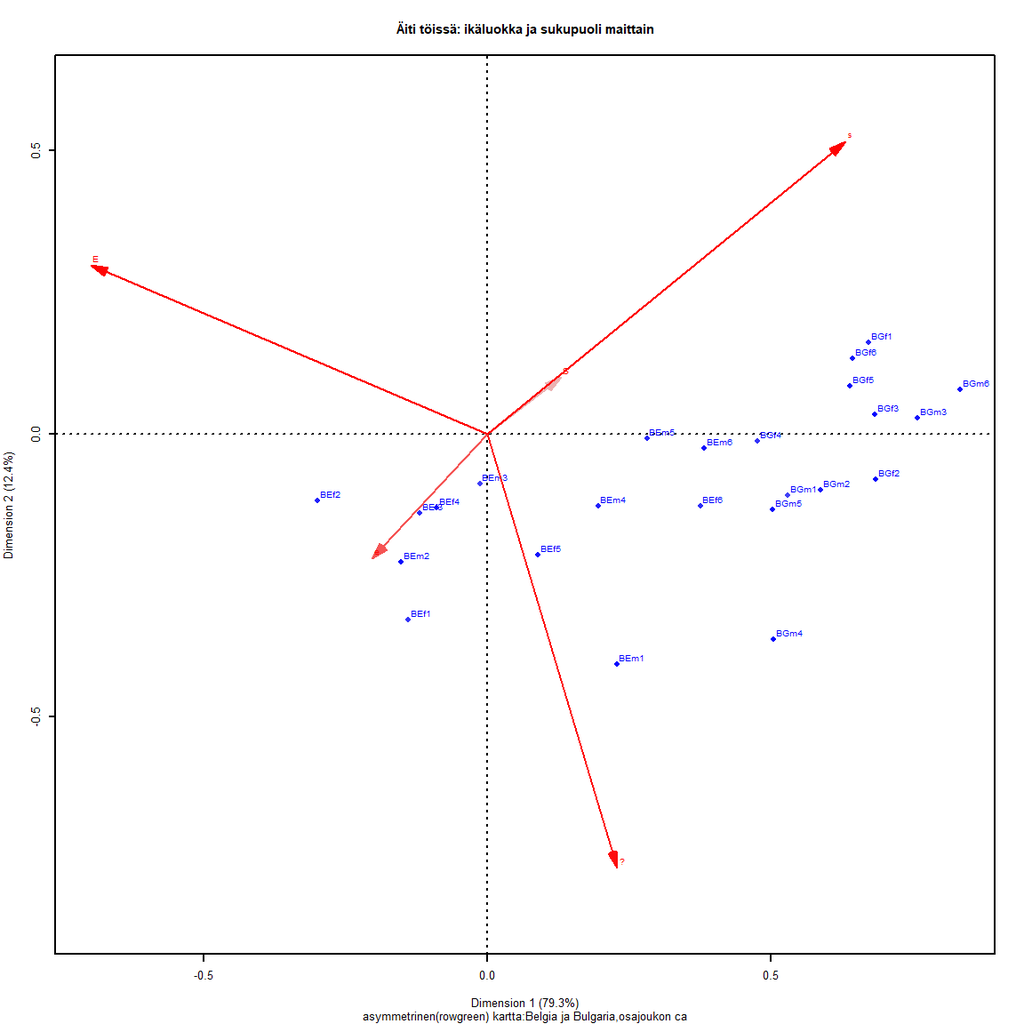

```r
maagaCA2sub2 <- ca(maagaTab1[,1:5], subsetrow = 1:24)
par(cex = 0.4)
plot(maagaCA2sub2, map = "rowgreen",
     contrib = c("relative", "relative"),
     mass = c(FALSE, TRUE),
     arrows = c(FALSE, TRUE),
     main = "Äiti töissä: ikäluokka ja sukupuoli maittain",
     sub = "asymmetrinen(rowgreen) kartta:Belgia ja Bulgaria,osajoukon ca"
        )
```

Belgian kolme aluetta täydentäviksi pisteiksi? **Ei tehdä, aika iso duuni.(9.9.20)**

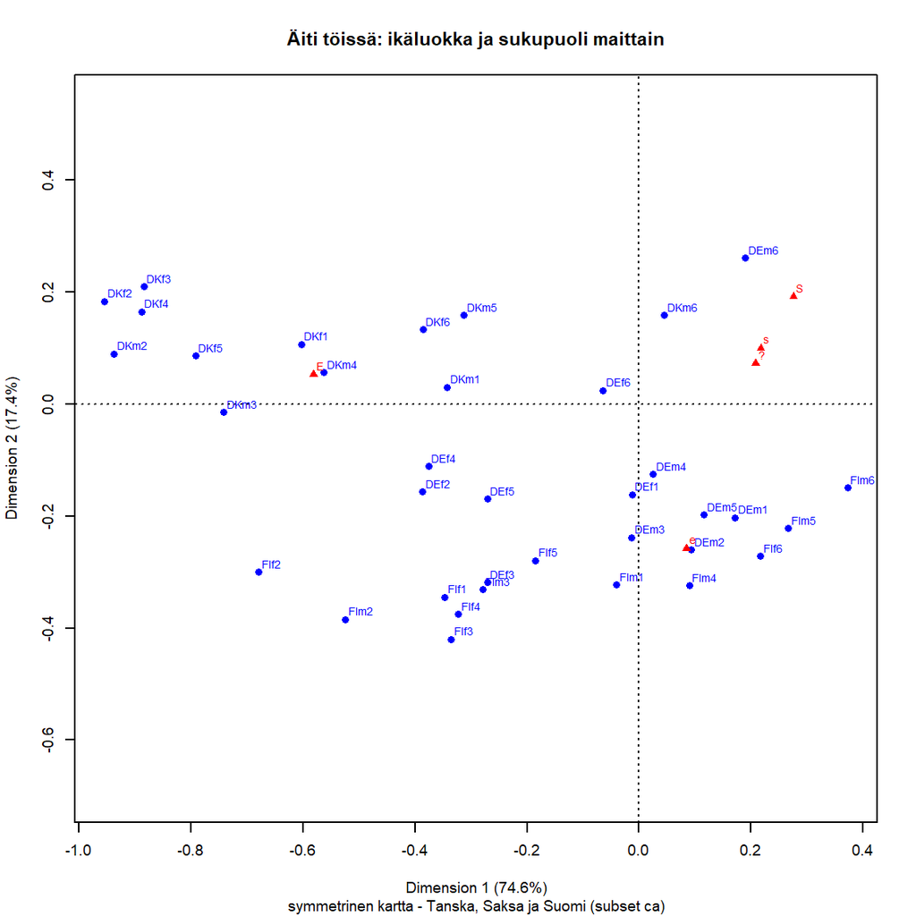

```r
# ISSP2012esim2.dat
# spCAmaaga1    maaga-ca-objekti (täydentävillä maa-pisteillä)
# maagaTab1     taulukko  jossa maaga-rivit ja maat täydentävinä pisteinä
#
# Ongelma 1: miten saa maarivit kätevästi? Tässä tapauksessa näin
# maagaTab1
# Taulukon viimeisillä riveillä maa-profiilit frekvensseinä
# maaga-rivit ovat samassa järjestyksessä, kuusi naisten ja kuusi miesten
# ikäryhmää
# ISSP2012esim2.dat %>% tableX(maaga, Q1b)
#
# BE   191 451 438 552 381
# BG   118 395 205 190  13
# DE   165 375 198 538 438
# DK    70 238 152 232 696
# FI    47 188 149 423 303
# HU   219 288 225 190  75
#
# BE 1-12, BG 13-24, DE 25-36, DK 37-48, FI 49-60, HU 61-72, maarivi
# Hoitaako ca-paketti automaattisesti täydentävien pisteiden "skaalauksen
# subsetCA:ssa? Sarakepisteiden keskiarvo on origossa, mutta rivien osajoukon
# keskiarvo ei ole ja tämä pitäisi korjata.

maagaCA2sub2 <- ca(~maaga + Q1b,ISSP2012esim1b.dat,subsetrow = 25:60)
par(cex = 0.6)
plot(maagaCA2sub2, main = "Äiti töissä: ikäluokka ja sukupuoli maittain",
     sub = "symmetrinen kartta - Tanska, Saksa ja Suomi (subset ca)")
```

Sama kuva - yhdistetään pisteitä janoilla.

```r
# ca-tulosobjekti maagaCA2sub2, DK DE FI

maagaLinesDKDEFI <- cacoord(maagaCA2sub2, type = "symmetric")
maagaLinesDKDEFI <- maagaLinesDKDEFI$rows[ , 1:2]
maagaLinesDKDEFI
```

|  | Dim1 | Dim2 |
| --- | --- | --- |
| DEf1 | -0.0122683 | -0.1617268 |
| DEf2 | -0.3865882 | -0.1566004 |
| DEf3 | -0.2706794 | -0.3184381 |
| DEf4 | -0.3756920 | -0.1108647 |
| DEf5 | -0.2706035 | -0.1694576 |
| DEf6 | -0.0642786 | 0.0244026 |
| DEm1 | 0.1718294 | -0.2031323 |
| DEm2 | 0.0926227 | -0.2603888 |
| DEm3 | -0.0130310 | -0.2383625 |
| DEm4 | 0.0247644 | -0.1255945 |
| DEm5 | 0.1156083 | -0.1981363 |
| DEm6 | 0.1901933 | 0.2611931 |
| DKf1 | -0.6029847 | 0.1067835 |
| DKf2 | -0.9546637 | 0.1836315 |
| DKf3 | -0.8845039 | 0.2100040 |
| DKf4 | -0.8887806 | 0.1653375 |
| DKf5 | -0.7917943 | 0.0864100 |
| DKf6 | -0.3858083 | 0.1333505 |
| DKm1 | -0.3423812 | 0.0299842 |
| DKm2 | -0.9383647 | 0.0897735 |
| DKm3 | -0.7426186 | -0.0144571 |
| DKm4 | -0.5633286 | 0.0565446 |
| DKm5 | -0.3135585 | 0.1585389 |
| DKm6 | 0.0450350 | 0.1583916 |
| FIf1 | -0.3464501 | -0.3449977 |
| FIf2 | -0.6802179 | -0.3000565 |
| FIf3 | -0.3353403 | -0.4203573 |
| FIf4 | -0.3234953 | -0.3751587 |
| FIf5 | -0.1850220 | -0.2795225 |
| FIf6 | 0.2168754 | -0.2714628 |
| FIm1 | -0.0401893 | -0.3226569 |
| FIm2 | -0.5246685 | -0.3847647 |
| FIm3 | -0.2794497 | -0.3311589 |
| FIm4 | 0.0897328 | -0.3241366 |
| FIm5 | 0.2669923 | -0.2222380 |
| FIm6 | 0.3726818 | -0.1495112 |

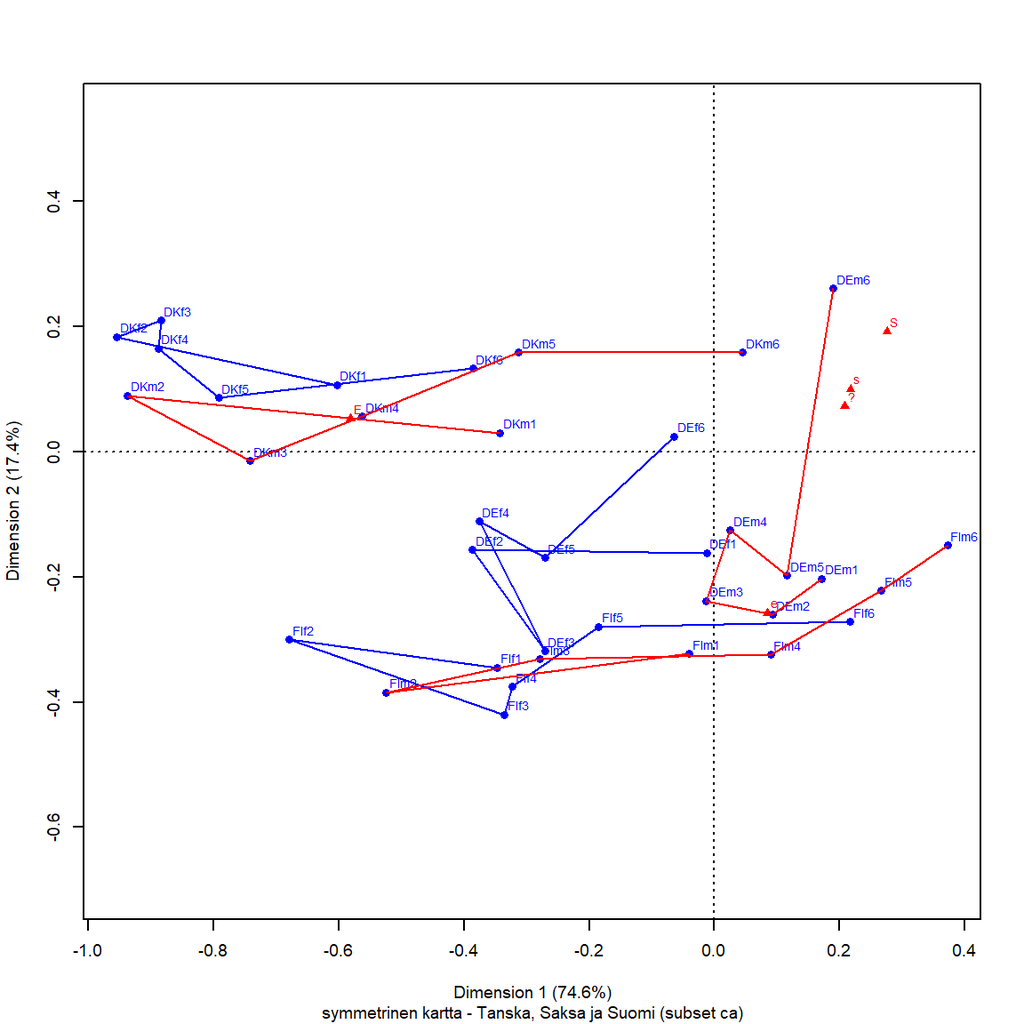

Ikä, sukupuoli ja maa:Tanska-Saksa-Suomi

```r
par(cex = 0.6)
plot(maagaCA2sub2,
     sub = "symmetrinen kartta - Tanska, Saksa ja Suomi (subset ca)")
lines(maagaLinesDKDEFI[1:6,1],maagaLinesDKDEFI[1:6,2], col="blue") #DEf
lines(maagaLinesDKDEFI[7:12,1],maagaLinesDKDEFI[7:12,2], col="red")  #DEm
lines(maagaLinesDKDEFI[13:18,1],maagaLinesDKDEFI[13:18,2], col="blue") #DKf
lines(maagaLinesDKDEFI[19:24,1],maagaLinesDKDEFI[19:24,2], col="red")  #DKm
lines(maagaLinesDKDEFI[25:30,1],maagaLinesDKDEFI[25:30,2], col="blue") #FIf
lines(maagaLinesDKDEFI[31:36,1],maagaLinesDKDEFI[31:36,2], col="red")  #FIm
```

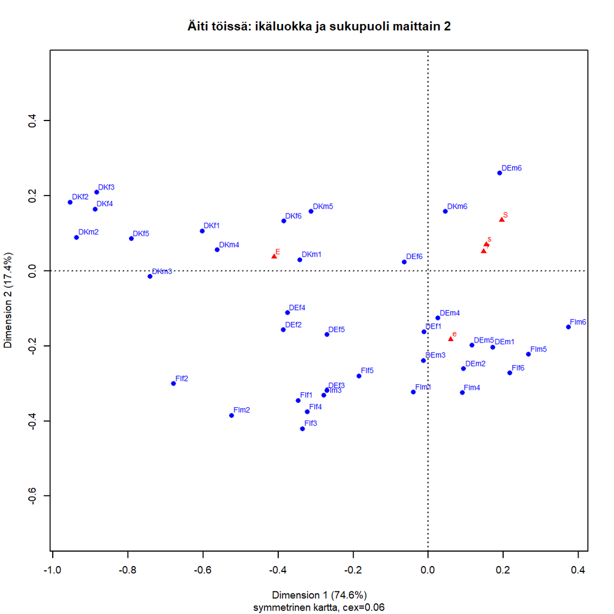

```r
spCAmaagasub1 <- ca(maagaTab1[,1:5], subsetrow = 25:60 )
par(cex = 0.6)
plot(spCAmaagasub1, main = "Äiti töissä: ikäluokka ja sukupuoli maittain 2",
     sub = "symmetrinen kartta, cex=0.06"
    )
```

Sama kartta kuin edellinen, mutta kontribuutiokarttana.

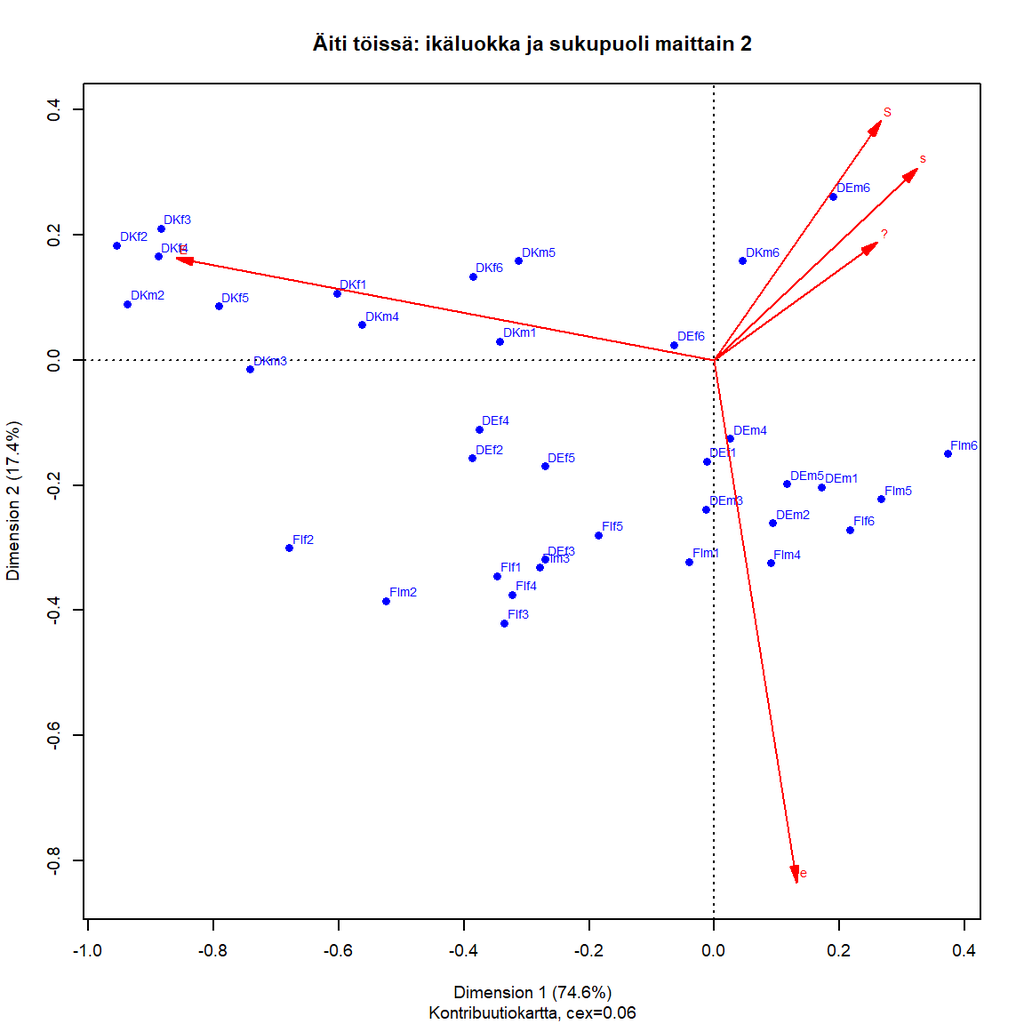

```r
# Osajoukko-ca ja täydentävät maapisteet

par(cex = 0.6)
plot(spCAmaagasub1, map = "rowgreen",
     arrows = c(FALSE, TRUE),
     main = "Äiti töissä: ikäluokka ja sukupuoli maittain 2",
     sub = "Kontribuutiokartta, cex=0.06"
    )
```

**17.10.20** Kontribuutiokartta näyttää paremmalta.

Tutkitaan CA-ratkaisun tuloksia.

```r
summary(spCAmaagasub1)
```

```
##
## Principal inertias (eigenvalues):
##
##  dim    value      %   cum%   scree plot
##  1      0.053545  74.6  74.6  *******************
##  2      0.012492  17.4  92.0  ****
##  3      0.003297   4.6  96.6  *
##  4      0.002441   3.4 100.0  *
##         -------- -----
##  Total: 0.071776 100.0
##
##
## Rows:
##      name   mass  qlt  inr    k=1 cor ctr    k=2 cor ctr
## 1  | DEf1 |    6  467    5 |  -12   3   0 | -162 464  13 |
```

[output cut: 43 more lines]

Kolmen maan osajoukon ratkaisussa 2. dimensiolla (maltillinen liberaali?) on inertiasta 17 prosenttia, edellä ollut paljon yksiulotteisempia ratkaisuja. Huono kvaliteetti on DEf1 (467) ja DEf6 (48!), DEm4 (285). Tanskan havainnoista vanhimmat miehet (DKm6,291) ovat kaikkein huonoimmin esitettyjä ratkaisussa, ja hieman nuoremmatkin (DKm5, 682). Suomen aineistossa vain nuoret miehet (FIm1, 624) on esitetty kartalla huonosti. Kaksi dimensiot selittävät osajoukon kokonaishajonnasta 92%, mutta muutaman ryhmän hajonta on muissa dimensioissa. Saksan naisten iäkkäin ikäluokka (DEf6) ja keski-ikäisen miehet (DEm4) vain näyttävät olevan lähekkäin origon tuntumassa, samoin muutama muu huonosti tasoon sijoitettu piste.

Huonosti kuvatuista pisteistä ei kuva ei siis kerro oikeastaan mitään muuta.

Sarakkeet on esitetty kohtalaisen hyvin, ja symmetrisessä kartassa tärkeimmälle dimensioille projisodut sarakepisteet ovat odotetussa järjestyksessä.

Kontribuutiokartasta nähdään, että tärkein kontrasti on tiukan erimielisyyden (E) ja kaikkien muiden vastausvaihtoehtojen välillä. Epävarmojen tai maltillisten (e) kontrasti hallitsee toista dimensiota, erityisesti S- ja s- kategorioiden kanssa. Samalla kuvasta näkee (ja numeerisist tuloksista voi vahvistaa), että S-piste on on lähempänä (kulma on pienempi) pystyakselia. Kontribuutio on suurempi (147 vs. 71 x-akselille). Toisaalta x-akseli selittää selvästi suurimman osan kaikkien muiden sarakepisteiden inertiasta, ja y-akseli taas lähes täysin e-pisteen inertian.

**Osajoukko-ca neljälle ryhmälle** Belgia on vähän rajatapaus, kokeillaan osajoukko-ca:ta neljällä maaryhmällä. BG-HU, BE-DE-DK-FI,DEDKFI ja BEBGHUsubset

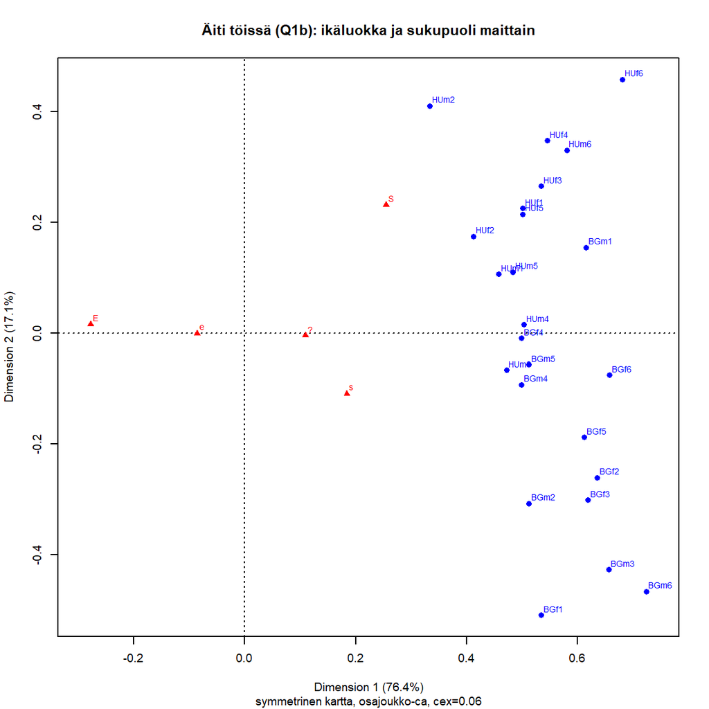

```r
# Neljä maaryhmää
BGHUsubset <- c(13:24,61:72)
BEDEDKFIsubset <- c(1:12, 25:36, 37:48, 49:60)
DEDKFIsubset <- c(25:36, 37:48, 49:60)
BEBGHUsubset <- c(1:12,13:24,61:72)



spCAmaagasub3 <- ca(maagaTab1[,1:5], subsetrow = BGHUsubset)
par(cex = 0.6)

# Käännetään kuva x-akselin ympäri
spCAmaagasub3$rowcoord[, 2] <- -spCAmaagasub3$rowcoord[, 2]
spCAmaagasub3$colcoord[, 2] <- -spCAmaagasub3$colcoord[, 2]


plot(spCAmaagasub3, main = "Äiti töissä (Q1b): ikäluokka ja sukupuoli maittain",
    sub = "symmetrinen kartta, osajoukko-ca, cex=0.06"
    )
```

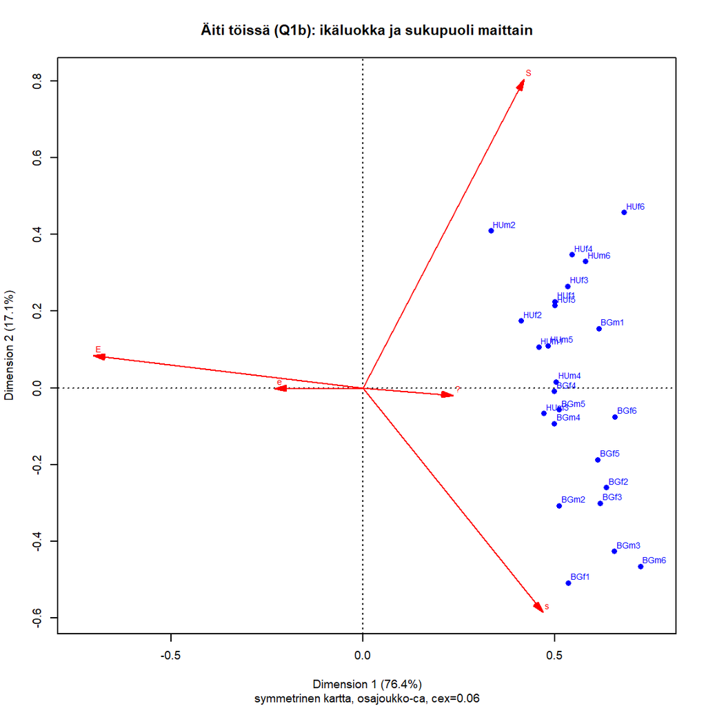

```r
# spCAmaagasub3 <- ca(maagaTab1[,1:5], subsetrow = BGHUsubset)
par(cex = 0.6)
plot(spCAmaagasub3, map = "rowgreen",
     arrows = c(FALSE,TRUE),
     main = "Äiti töissä (Q1b): ikäluokka ja sukupuoli maittain",
    sub = "symmetrinen kartta, osajoukko-ca, cex=0.06"
    )
```

```r
# xlim=c(-0.1,0.8), ylim=c(-0.,0.4) kuvaa voisi säätää, mutta tärkein E-sarake
# jäisi pois
summary(spCAmaagasub3)
```

```
##
## Principal inertias (eigenvalues):
##
##  dim    value      %   cum%   scree plot
##  1      0.036585  76.4  76.4  *******************
##  2      0.008208  17.1  93.5  ****
##  3      0.002065   4.3  97.8  *
##  4      0.001054   2.2 100.0  *
##         -------- -----
##  Total: 0.047912 100.0
##
##
## Rows:
##      name   mass  qlt  inr    k=1 cor ctr    k=2 cor ctr
## 1  | BGf1 |    2  966   29 |  535 507  19 | -509 459  77 |
```

[output cut: 31 more lines]

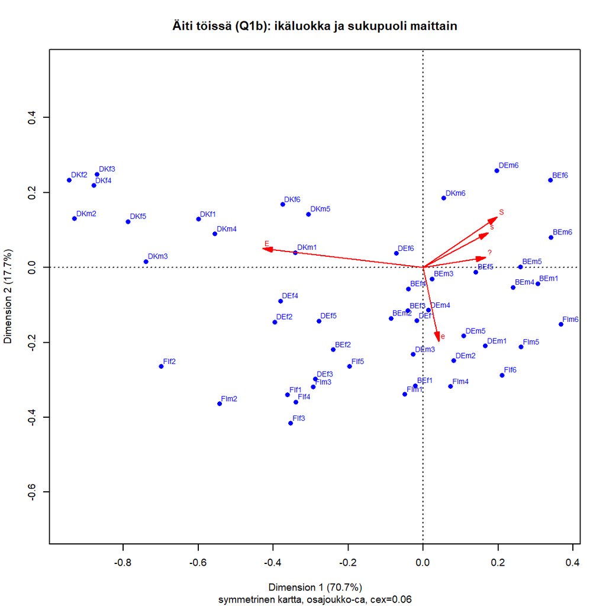

```r
spCAmaagasub4 <- ca(maagaTab1[,1:5], subsetrow = BEDEDKFIsubset)
par(cex = 0.6)
plot(spCAmaagasub4,
     arrows = c(FALSE, TRUE),
     main = "Äiti töissä (Q1b): ikäluokka ja sukupuoli maittain",
     sub = "symmetrinen kartta, osajoukko-ca, cex=0.06"
)
```

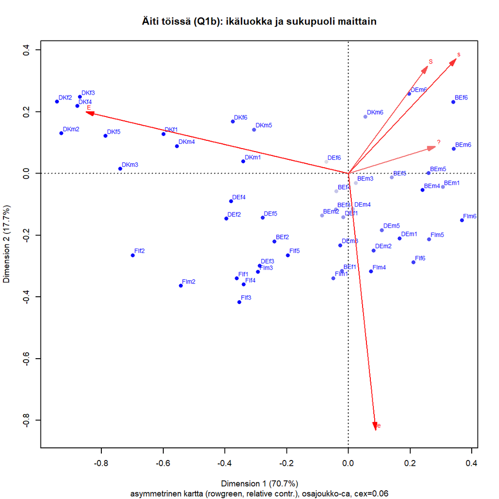

```r
# asymmetrinen kartta
par(cex = 0.6)
plot(spCAmaagasub4,map = "rowgreen",
     contrib = c("relative", "relative"),
     mass = c(FALSE, TRUE),
     arrows = c(FALSE, TRUE),
     main = "Äiti töissä (Q1b): ikäluokka ja sukupuoli maittain",
     sub = "asymmetrinen kartta (rowgreen, relative contr.), osajoukko-ca, cex=0.06"
)
```

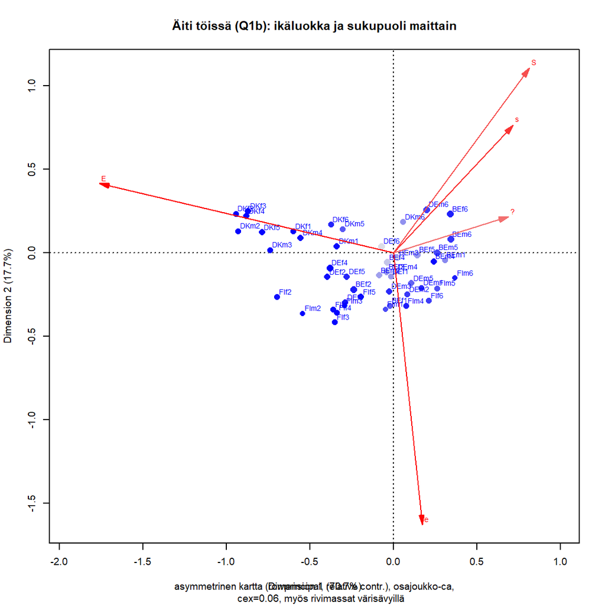

```r
par(cex = 0.6)
plot(spCAmaagasub4,map = "rowprincipal",
     contrib = c("relative", "relative"),
     mass = c(TRUE, TRUE),
     arrows = c(FALSE, TRUE),
     main = "Äiti töissä (Q1b): ikäluokka ja sukupuoli maittain",
     sub = "asymmetrinen kartta (rowprincipal, relative contr.), osajoukko-ca,
     cex=0.06, myös rivimassat värisävyillä"
)
```

**17.10.20** Kontribuutiokartta on paras. Asymmetrinen on liian tukkoinen.

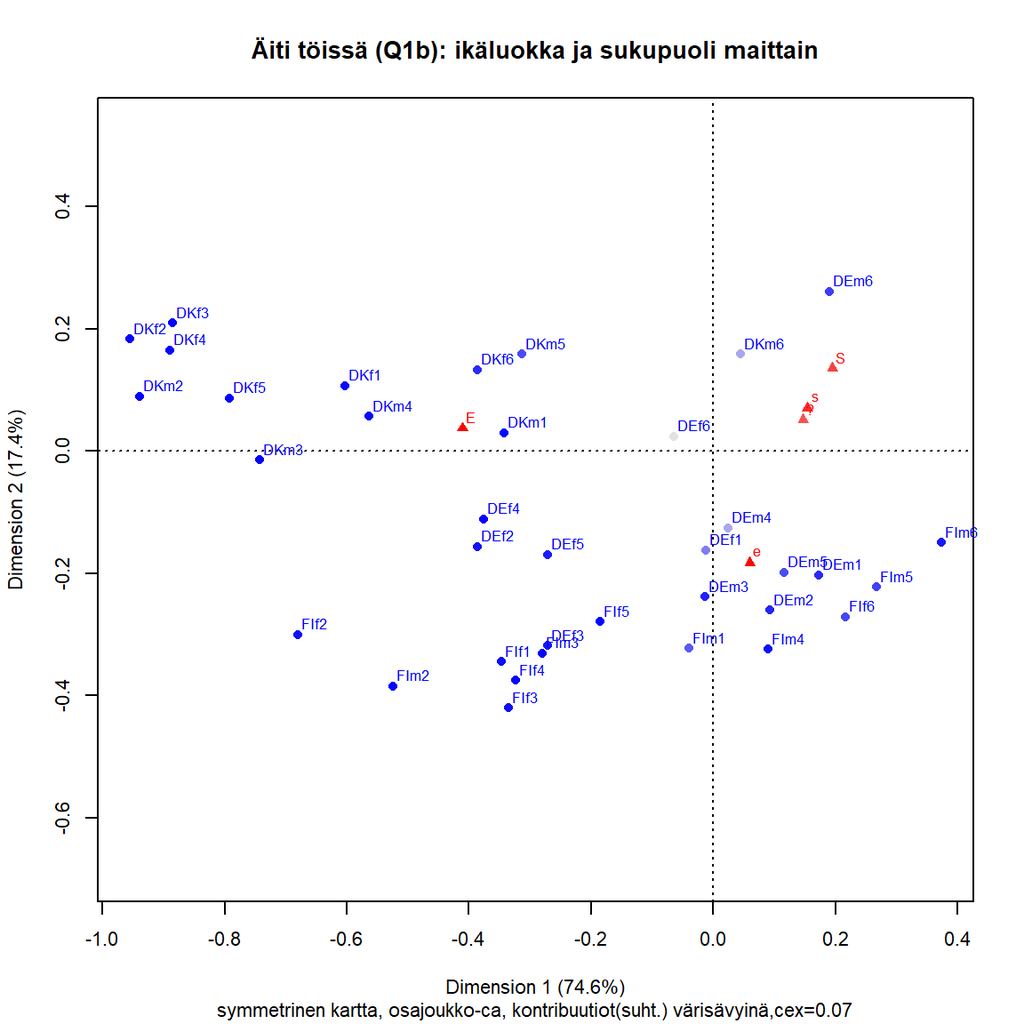

```r
spCAmaagasub5 <- ca(maagaTab1[,1:5], subsetrow = DEDKFIsubset)
par(cex = 0.7)
plot(spCAmaagasub5, main = "Äiti töissä (Q1b): ikäluokka ja sukupuoli maittain",
     contrib = c("relative", "relative"),
     sub = "symmetrinen kartta, osajoukko-ca, kontribuutiot(suht.) värisävyinä,cex=0.07"
)
```

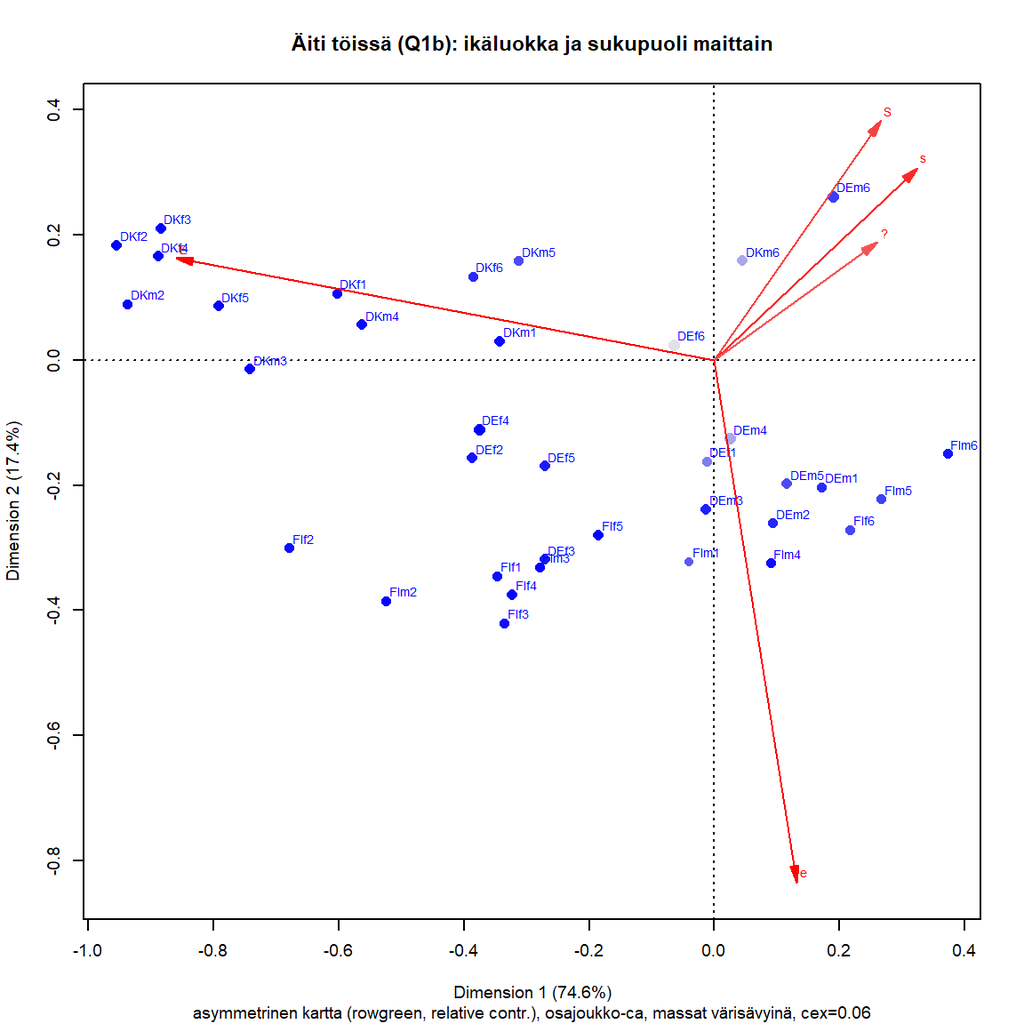

```r
# asymmetrinen kartta
par(cex = 0.6)
plot(spCAmaagasub5,map = "rowgreen",
     contrib = c("relative", "relative"),
     mass = c(TRUE, TRUE),
     arrows = c(FALSE, TRUE),
     main = "Äiti töissä (Q1b): ikäluokka ja sukupuoli maittain",
     sub = "asymmetrinen kartta (rowgreen, relative contr.), osajoukko-ca, massat värisävyinä, cex=0.06"
)
```

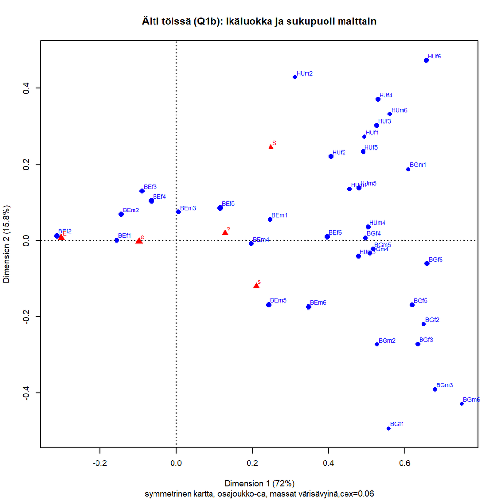

```r
spCAmaagasub6 <- ca(maagaTab1[,1:5], subsetrow = BEBGHUsubset)


par(cex = 0.6)
plot(spCAmaagasub6, main = "Äiti töissä (Q1b): ikäluokka ja sukupuoli maittain",
     mass = c(TRUE, TRUE),
     sub = "symmetrinen kartta, osajoukko-ca, massat värisävyinä,cex=0.06"
)
```

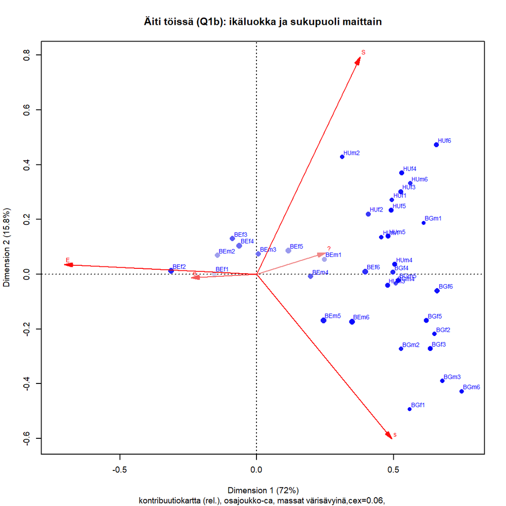

```r
plot(spCAmaagasub6, map = "rowgreen",
     contrib = c("relative", "relative"),
     mass = c(TRUE, TRUE),
    arrows = c(FALSE, TRUE),
    main = "Äiti töissä (Q1b): ikäluokka ja sukupuoli maittain",
    sub = "kontribuutiokartta (rel.), osajoukko-ca, massat värisävyinä,cex=0.06, "
)
```

# 5 Yksinkertaisen korrespondenssianalyysin laajennuksia 2

Kaksi ensimmäistä lukua ehkä omaksi kokonaisuudeksi, ohitetaan aika kevyesti.

## 5.1 Matriisien yhdistäminen (stacked and concatenated matices)

Pinotuista tauluista yksinkertainen esimerkki rajatulla aineistolla, selitetään periaate. Ei laajenneta aineistoa, sillä puuttuvat tiedot aiheuttavat pulmia joihin sopii parhaiten MCA. MCA on muuttujien välisten suhteiden analyysiä, näin puuttuvista tiedosta saadan otetta.

Ref:CAip, CA_Week2.pdf (kalvot MCA-kurssilta 2017)

Concatenated tables (yhdistetyt taulut tai matriisit): (a) kaksi luokittelumuuttujaa (b) useita muuttujia stacked (“pinotaan”).

MCA 2017 laskareissa ja kalvoissa esitetään, miten nämä saadaan kätevästi CA-paketin MJCA-funktion BURT-optiolla.

```r
# Data
ISSP2012Concat1jh.dat <- select(ISSP2012esim1b.dat, Q1b, maa,sp, age_cat)

# mjca-funktiota ->  Burt-matriisi
Concat1jh.Burt <- mjca(ISSP2012Concat1jh.dat, ps="")$Burt

# Burt-matriisi symmetrinen
#dim(Concat1jh.Burt)
# 19 x 19
#rownames(Concat1jh.Burt)
#[1] "Q1bS"     "Q1bs"     "Q1b?"     "Q1be"     "Q1bE"     "maaBE"    "maaBG"    "maaDE"    "maaDK"
#[10] "maaFI"    "maaHU"    "spm"      "spf"      "age_cat1" "age_cat2" "age_cat3" "age_cat4" "age_cat5"
#[19] "age_cat6"

# maat - vastaukset
ISSP2012Concat2jh.dat <- Concat1jh.Burt[6:11, 1:5]
# ISSP2012Concat2jh.dat
# sukupuoli ja vastaukset
ISSP2012Concat2jh.dat <- rbind(ISSP2012Concat2jh.dat, Concat1jh.Burt[12:13 ,1:5])
# ISSP2012Concat2jh.dat
# ikäluokka ja vastaukset
ISSP2012Concat2jh.dat <- rbind(ISSP2012Concat2jh.dat, Concat1jh.Burt[14:19 ,1:5])
# ISSP2012Concat2jh.dat

Concat1jh.CA1 <- ca(ISSP2012Concat2jh.dat)
# plot(Concat1jh.CA1)

# Siistitään muuttujien nimet

Concat1jh.CA1$colnames <- c("S", "s", "?", "e", "E")
Concat1jh.CA1$rownames <- c("BE", "BG", "DE", "DK", "FI", "HU", "m", "f",
                            "a1", "a2", "a3", "a4", "a5", "a6")
# Käännetään kuva x-akselin ympäri
Concat1jh.CA1$rowcoord[, 2] <- -Concat1jh.CA1$rowcoord[, 2]
Concat1jh.CA1$colcoord[, 2] <- -Concat1jh.CA1$colcoord[, 2]
```

Piirretään karttoja.

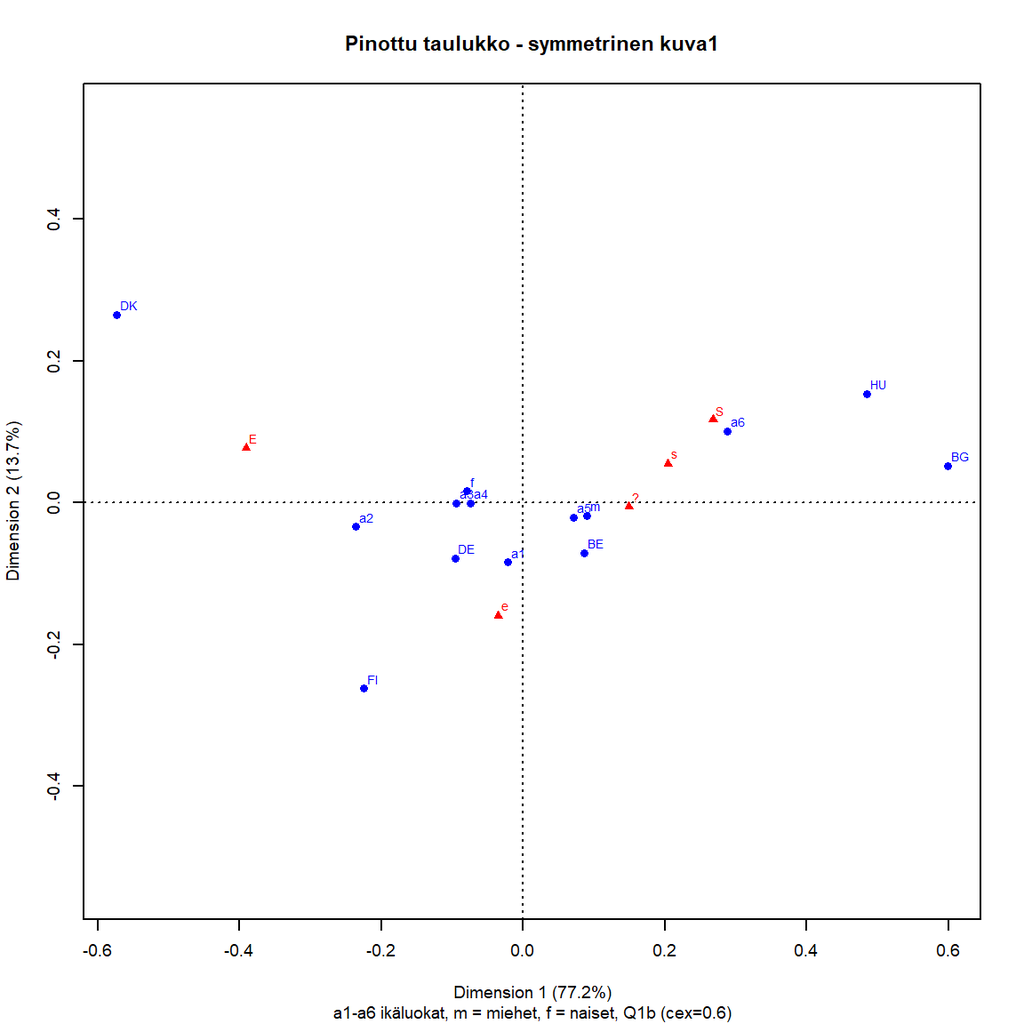

Pinottu matriisi - kartta 1

```r
# Kooridnaatit käännetty edellisessä koodilohkossa
# Symmetrinen kartta paras, kontribuutiokartta vektoireilla myös aika hyvä

par(cex = 0.6)
plot(Concat1jh.CA1,
     main = "Pinottu taulukko - symmetrinen kuva1",
     sub = "a1-a6 ikäluokat, m = miehet, f = naiset, Q1b (cex=0.6)"
     )
```

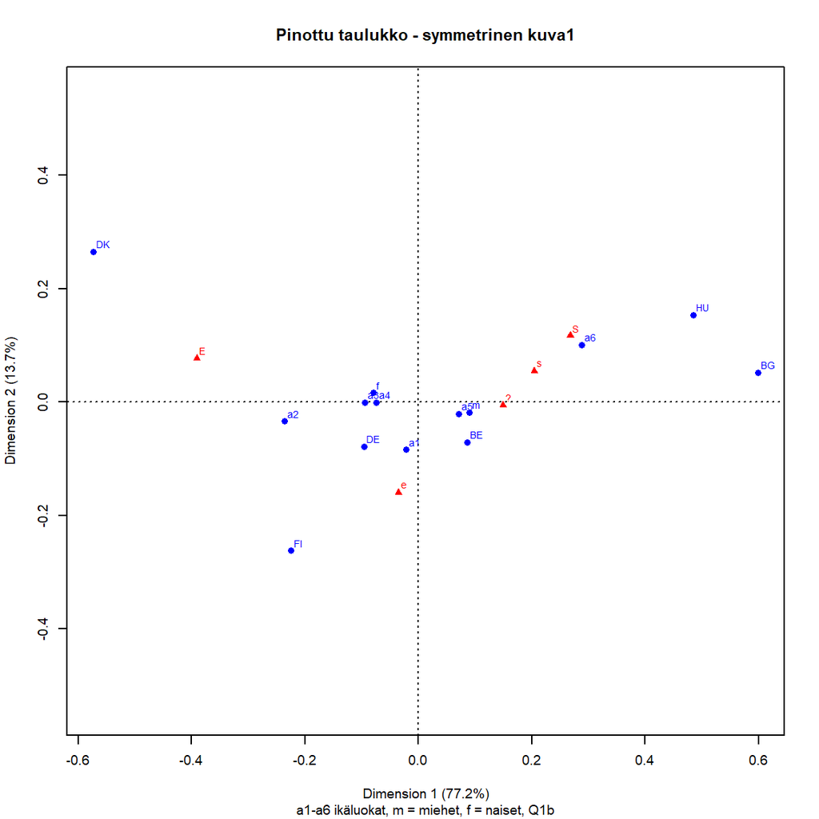

Pinottu matriisi - kartta 1

```r
plot(Concat1jh.CA1,
     main = "Pinottu taulukko - symmetrinen kuva1",
     sub = "a1-a6 ikäluokat, m = miehet, f = naiset, Q1b"
     )
```

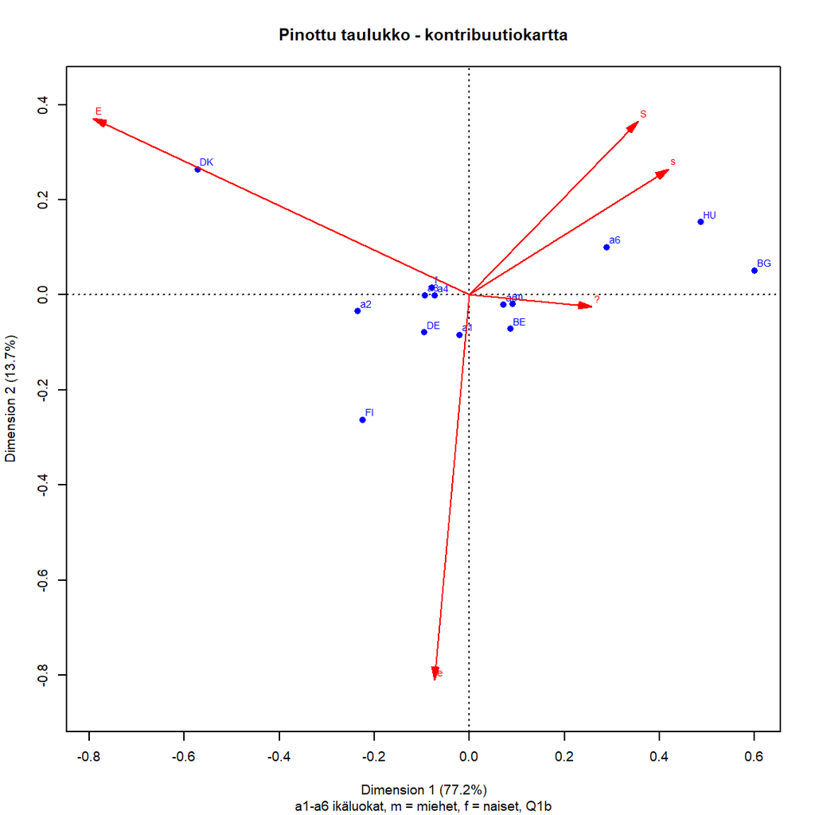

Pinottu matriisi - kartta 1

```r
plot(Concat1jh.CA1, map = "rowgreen",
     arrows = c(FALSE, TRUE),
     main = "Pinottu taulukko - kontribuutiokartta",
     sub = "a1-a6 ikäluokat, m = miehet, f = naiset, Q1b"
     )
```

```r
# Muutama rivipiste ja taustamuuttujat tiukkana nippuna origon ympärillä
#plot(Concat1jh.CA1, map = "rowgreen",
#     main = "Pinottu taulukko - kontribuutiokartta",
#     sub = "a1-a6 ikäluokat, m = miehet, f = naiset, Q1b"
#     )

# Tukkoinen kuva - rajataan pois HU ja BG (rivit 2, 6)
# dim(ISSP2012Concat2jh.dat)
summary(Concat1jh.CA1)
```

```
##
## Principal inertias (eigenvalues):
##
##  dim    value      %   cum%   scree plot
##  1      0.056877  77.2  77.2  *******************
##  2      0.010116  13.7  91.0  ***
##  3      0.003923   5.3  96.3  *
##  4      0.002711   3.7 100.0  *
##         -------- -----
##  Total: 0.073628 100.0
##
##
## Rows:
##      name   mass  qlt  inr    k=1 cor ctr    k=2 cor ctr
## 1  |   BE |   82  498   28 |   86 295  11 |  -71 203  41 |
## 2  |   BG |   38  907  204 |  599 901 238 |   52   7  10 |
## 3  |   DE |   70  498   29 |  -95 298  11 |  -78 200  43 |
## 4  |   DK |   57  990  310 | -573 816 328 |  265 175 394 |
## 5  |   FI |   45  987   75 | -225 419  40 | -262 568 309 |
## 6  |   HU |   41  856  168 |  486 778 169 |  153  78  95 |
## 7  |    m |  156  910   20 |   91 873  22 |  -19  37   5 |
## 8  |    f |  178  910   17 |  -79 873  20 |   16  37   5 |
## 9  |   a1 |   39  501    8 |  -22  31   0 |  -84 470  27 |
## 10 |   a2 |   50  958   40 | -236 939  49 |  -34  19   6 |
## 11 |   a3 |   56  958    7 |  -94 958   9 |   -1   0   0 |
## 12 |   a4 |   63  841    6 |  -74 841   6 |   -1   0   0 |
## 13 |   a5 |   62  868    5 |   71 801   6 |  -21  67   3 |
## 14 |   a6 |   63  957   83 |  288 852  92 |  101 104  63 |
##
## Columns:
##     name   mass  qlt  inr    k=1 cor ctr    k=2 cor ctr
## 1 |    S |   99  786  147 |  268 661 126 |  117 125 134 |
## 2 |    s |  238  843  172 |  205 787 175 |   55  56  70 |
## 3 |      |  168  640   80 |  150 639  66 |   -6   1   1 |
## 4 |    e |  261  970   97 |  -35  44   6 | -160 926 657 |
## 5 |    E |  234 1000  504 | -390 962 628 |   77  38 138 |
```

Kartan tulkinta; miten eroaa yhteisvaikutusmuuttujan analyysistä?

1. Perustulkinta akseleille ei muutu, mutta s-sarake on kiusallisesti enemmän oikealla kuin S. Maapisteiden sijaiti ei juuri muutu.

Mikä on maapisteiden ja kahden selittävän (eksogeenisen) muuttujan pisteiden yhteys sarakepisteisiin?

Koko aineiston kartassa ikäluokkapisteet ja sukupuolipisteet ovat pakkautuneet maapisteitä tiiviimmin origon ympärille. Ikäluokkapisteiden (koko aineiston keskiarvot) selvä kontrasti on vanhimman (a6)ja toiseksi nuorimman välillä 1. dimenision suuntaan.

Ikäluokkapisteet ovat koko aineiston keskiarvopisteitä, niiden sijantia voi tulkita pistejoukko kerrallaan kuten maapisteidenkin. Mitään yhteisvaikutuksia ei analysoida eksplisiittisesti. Karttaa voi verrata sukupuoli-ikäluokka yhteisvaikutusmuuttujan analyysin aiemmin. Naispiste on tiukassa nipussa ikäluokkien a3 ja a4 kanssa aivan origon vasemmalla puolella. Miesten keskiarvopiste on hieman origosta oikealle, yhdessä ikäluokan a5 kanssa.

**Taustamuuttujat: numeeristen tulosten tarkastelua**

Lisäpisteet on hyvin esitetty, niiden etäisyyksiä voi luotettavasti arvioida kuvasta. Poikkeus on nuorin ikäluokka (a1, qlt = 501). Inertian osuudet (inr) ovat yhtä vaatimattomia kuin Belgian (28) ja Saksan (29), (m =20, f = 17, a2 = 40, a6 = 83), samoin kontribuutiot akseleiden inertiaan. 1. dimension kontribuutio (cor) on suuri (>800) kaikilla paitsi nuorimmalla ikäryhmällä (a1) jolla 2. dimension selittää lähes puolet sen inertiasta (470).

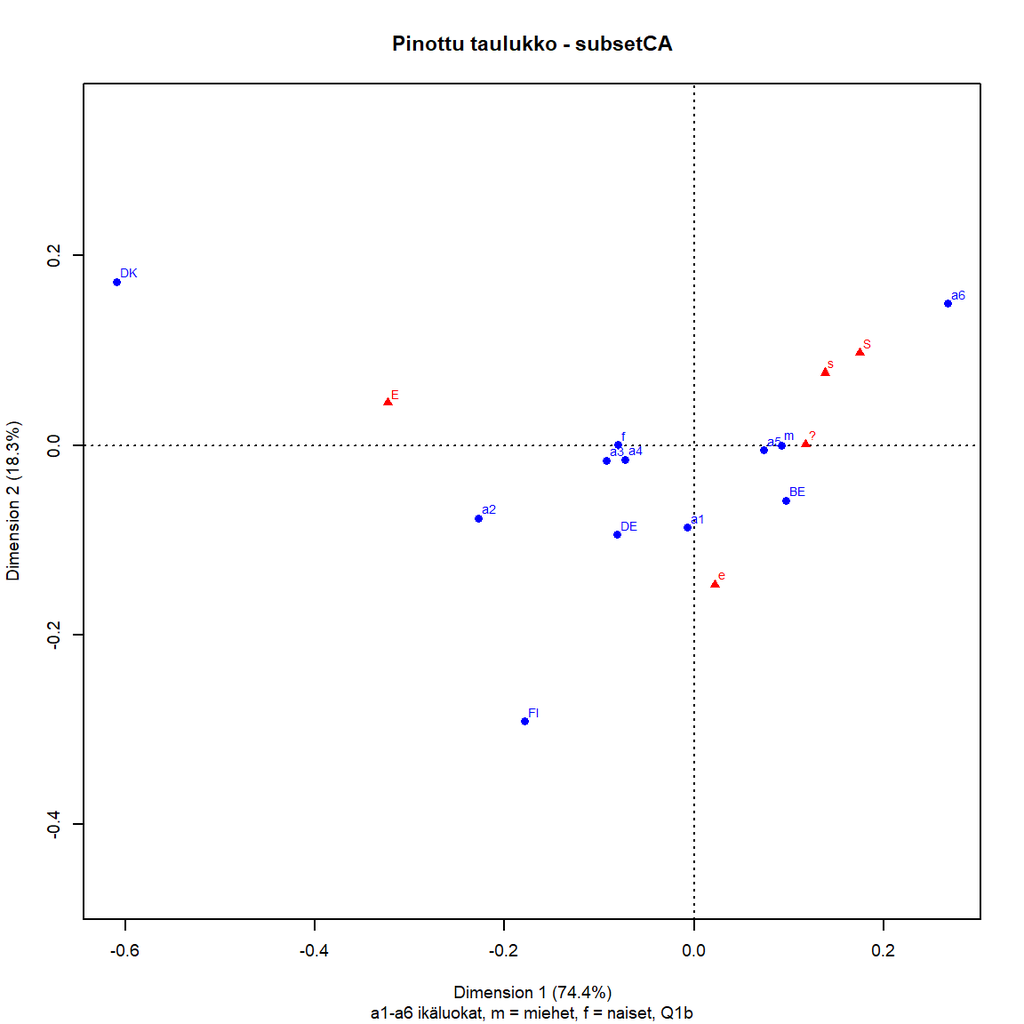

Pinottu matriisi - osajoukko (HU, BG pois)

```r
subConcat2jh.CA1 <- ca(ISSP2012Concat2jh.dat[,1:5], subsetrow = c(1:1, 3:5, 7:14))
subConcat2jh.CA1$colnames <- c("S", "s", "?", "e", "E")
subConcat2jh.CA1$rownames <- c("BE", "DE", "DK", "FI", "m", "f",
                           "a1", "a2", "a3", "a4", "a5", "a6")
par(cex = 0.6)
plot(subConcat2jh.CA1,
     main = "Pinottu taulukko - subsetCA",
     sub = "a1-a6 ikäluokat, m = miehet, f = naiset, Q1b"
     )
```

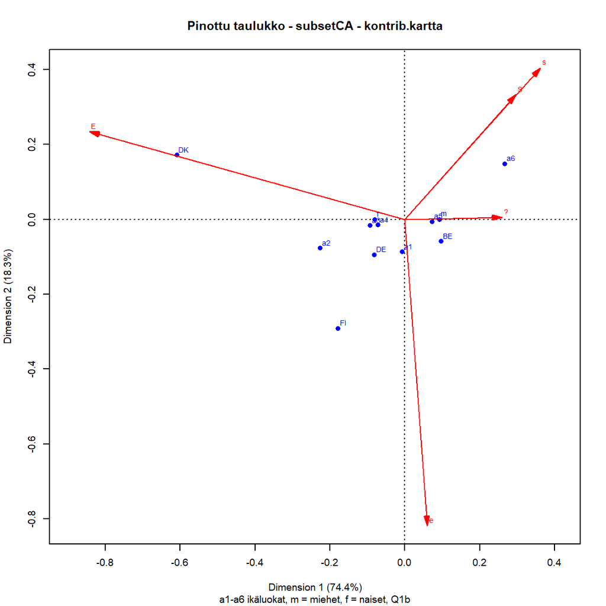

Pinottu matriisi - osajoukko (HU, BG pois)

```r
# Kontribuutiokuva
par(cex = 0.6)
plot(subConcat2jh.CA1, map = "rowgreen",
     arrows = c(FALSE, TRUE),
     main = "Pinottu taulukko - subsetCA - kontrib.kartta",
     sub = "a1-a6 ikäluokat, m = miehet, f = naiset, Q1b"
     )
```

```r
summary(subConcat2jh.CA1)
```

```
##
## Principal inertias (eigenvalues):
##
##  dim    value      %   cum%   scree plot
##  1      0.034433  74.4  74.4  *******************
##  2      0.008459  18.3  92.7  *****
##  3      0.002735   5.9  98.6  *
##  4      0.000627   1.4 100.0
##         -------- -----
##  Total: 0.046253 100.0
##
##
## Rows:
##      name   mass  qlt  inr    k=1 cor ctr    k=2 cor ctr
## 1  |   BE |   82  511   44 |   97 374  22 |  -58 137  33 |
## 2  |   DE |   70  505   46 |  -81 216  13 |  -94 289  74 |
## 3  |   DK |   57  996  494 | -609 922 612 |  172  74 200 |
## 4  |   FI |   45  967  119 | -179 266  42 | -291 701 455 |
## 5  |    m |  156  903   32 |   92 903  38 |    0   0   0 |
## 6  |    f |  178  903   28 |  -81 903  33 |    0   0   0 |
## 7  |   a1 |   39  504   13 |   -7   4   0 |  -87 500  35 |
## 8  |   a2 |   50  967   64 | -227 867  74 |  -77  99  35 |
## 9  |   a3 |   56  958   11 |  -93 930  14 |  -16  27   2 |
## 10 |   a4 |   63  847    9 |  -72 811  10 |  -15  35   2 |
## 11 |   a5 |   62  853    9 |   73 849  10 |   -5   4   0 |
## 12 |   a6 |   63  963  132 |  267 734 130 |  149 229 165 |
##
## Columns:
##     name   mass  qlt  inr    k=1 cor ctr    k=2 cor ctr
## 1 |    S |   99  869   99 |  175 664  88 |   97 206 111 |
## 2 |    s |  238  923  139 |  138 706 131 |   76 216 164 |
## 3 |      |  168  525   95 |  117 525  67 |    1   0   0 |
## 4 |    e |  261  970  129 |   22  21   4 | -147 949 670 |
## 5 |    E |  234 1000  538 | -323 981 710 |   45  19  55 |
```

Kun Bulgaria ja Unkari jätetään pois, origon lähelle pakkautuneet pistet erottuvat hieman paremmin (osajoukon CA).

Osajoukon analyysin kontribuutiokartta muuttuu:

Iän ja sukupuolen erilliset vaikutukset eivät ole aivan yksinkertaisia. **edit 17.10.20** Barysentrisen ominaisuudet?

Inertian dekomponointi alimatriiseille.

Tärkeä oletus: reunajakaumat tauluissa samat, ei puuttuvia tietoja muuttujissa.

### 5.1.1 Matched matrices

**Huom! (16.10.20** Jos ja kun ei tehdä analyysiä, ei tarvitse omaa jaksoa. Kannattaa mainita, ehkävain teoriajaksossa? Idea: matriisien yhdistämisellä saadaan ote monenlaiseen tutkimusongelmaan. Benzecri: data-analyysissä on vain löydettävä oikea matriisi joka diagonalisoidaan.

Ref:CAip ss. 177, HY2017_MCA, Greenacre JAS 2013 (sovellus ISSP 1989,4 kysymystä ‘pitäisikö äidin olla kotona’, 8 maata), tässä artikkelissa “SVD-based methods”, joista yksi CA (muut biplots, PCA, compositional data/log ratios).

Edellisen menetelmän variantti, jossa ryhmien väliset ja sisäiset erot saadaan esiin. Inertian jakaminen.

Samanlaisten rivien ja sarakkeiden kaksi samankokoista taulua, esimerkiksi sukupuolivaikutusten arviointi. Alkuperäinen taulukko jaetaan kahdeksi tauluksi sukupuolen mukaan. Matriisien yhdistäminen (concatenation) riveittäin tai sarakkeittain ei näytä optimaalisesti mm - matriisien eroja.

Ryhmien välisen ja ryhmien sisäinen inertian erottaminen, **ABBA** on yksi ratkaisu (ABBA matrix, teknisesti block circular matrix).

Luokittelu voi olla myös kahden indikaattorimuuttujan avulla jako neljään taulukkoon (esim. miehet vs. naiset länsieuroopassa verratuna samaan asetelmaan itä-Euroopassa). Samaa ideaa laajennetaan.

Esimerkkinä “Attitudes to women working in 2012”.

## 5.2 MCA - multiple correspondence analysis

MCA on samantyyppisten luokitteluasteikon muuttujien välisten yhteyksien analyysiä.

**Data** Substanssimuuttujien (kysymysten) ja taustamuuttujien (demografiset, koulutus, asuinpaikka) analyysissä ydin on substanssimuuttujien välisissä suhteissa.

Subsanssimuuttujista valitaan seitsemän kysymystä (naisten rooli työmarkkinoilla) joissa vastausvaihtoehtoja on viisi. Tämä on suositus tai yleinen käytäntö, joka yksinkertaistaa analyysiä.

Taustamuuttujista valitaan kolme: koulutustaso edu ja asuinpaikka urbru ovat (jos tiedokeruun erot unohdetaan) taustatietoja.Kolmas muuttujasosta/“Top-Bottom self-placement”) on kysymys mutta ei pohdita tätä enempää.

Lisämuuttujina ovat sukupuoli (sp), maa ja ikä. Ikä luokitellaan kuuteen ryhmään ja luodaan ikäluokan ja sukupuolen yhteisvaikutusmuuttuja ga.

```r
# str(ISSP2012jh1d.dat) - luotu skripteissä G1_1_data2.Rmd ja G1_1_data_fct1.Rmd

#Valitaan muuttujat joissa puuttuva tieto on koodattu muuttujan arvoksi

MCAvars1 <-  c("Q1am","Q1bm", "Q1cm", "Q1dm","Q1em","Q2am","Q2bm","edum",
                 "sostam", "urbrum", "maa", "ika", "sp" )

MCAdata1jh.dat <- ISSP2012jh1d.dat %>% select(all_of(MCAvars1))
dim(MCAdata1jh.dat)
```

```
## [1] 32823    13
```

```r
names(MCAdata1jh.dat)
```

```
##  [1] "Q1am"   "Q1bm"   "Q1cm"   "Q1dm"   "Q1em"   "Q2am"   "Q2bm"   "edum"
##  [9] "sostam" "urbrum" "maa"    "ika"    "sp"
```

```r
# luodaan ikaluokka-muuttuja ja ikäluokka-sukupuoli - muuttuja
#age_cat
#ikä 1=15-25, 2 =26-35, 3=36-45, 4=46-55, 5=56-65, 6= 66 and older
MCAdata1jh.dat <- mutate(MCAdata1jh.dat, age_cat = ifelse(ika %in% 15:25, "1",
                                ifelse(ika %in% 26:35, "2",
                                ifelse(ika %in% 36:45, "3",
                                ifelse(ika %in% 46:55, "4",
                                ifelse(ika %in% 56:65, "5", "6"))))))

# str(MCAdata1jh.dat$age_cat)

MCAdata1jh.dat <- MCAdata1jh.dat %>%
        mutate(age_cat = as_factor(age_cat))
#tarkastuksia - outo järjestys
#levels(MCAdata1jh.dat$age_cat)
# str(MCAdata1jh.dat$age_cat)
MCAdata1jh.dat<- MCAdata1jh.dat %>%
        mutate(age_cat = fct_relevel(age_cat,
                                   "1",
                                   "2",
                                   "3",
                                   "4",
                                   "5",
                                   "6"))

# Tarkistuksia(16.10.20)

MCAdata1jh.dat %>%
        tableX(maa,age_cat,type = "count") #%>%
```

| maa/age_cat | 1 | 2 | 3 | 4 | 5 | 6 | Total |
| --- | --- | --- | --- | --- | --- | --- | --- |
| AU | 109 | 134 | 265 | 332 | 353 | 364 | 1557 |
| AT | 115 | 228 | 206 | 228 | 182 | 223 | 1182 |
| BG | 89 | 123 | 169 | 157 | 210 | 255 | 1003 |
| CA | 112 | 32 | 72 | 156 | 260 | 321 | 953 |
| HR | 136 | 201 | 177 | 198 | 166 | 119 | 997 |
| CZ | 195 | 278 | 377 | 361 | 279 | 314 | 1804 |
| DK | 210 | 214 | 252 | 273 | 235 | 219 | 1403 |
| FI | 160 | 171 | 171 | 230 | 254 | 185 | 1171 |
| FR | 149 | 357 | 426 | 451 | 466 | 560 | 2409 |
| HU | 106 | 163 | 201 | 172 | 197 | 173 | 1012 |
| IS | 224 | 187 | 188 | 201 | 194 | 178 | 1172 |
| IE | 26 | 161 | 255 | 266 | 234 | 224 | 1166 |
| LV | 168 | 159 | 187 | 216 | 203 | 67 | 1000 |
| LT | 151 | 169 | 186 | 220 | 203 | 258 | 1187 |
| NL | 60 | 129 | 191 | 250 | 283 | 402 | 1315 |
| NO | 165 | 205 | 256 | 309 | 264 | 245 | 1444 |
| PL | 158 | 173 | 185 | 178 | 219 | 202 | 1115 |
| RU | 222 | 232 | 254 | 253 | 276 | 288 | 1525 |
| SK | 75 | 116 | 189 | 254 | 264 | 230 | 1128 |
| SI | 97 | 157 | 161 | 178 | 202 | 239 | 1034 |
| SE | 80 | 134 | 164 | 211 | 196 | 274 | 1059 |
| CH | 137 | 184 | 217 | 265 | 185 | 249 | 1237 |
| BE | 216 | 346 | 349 | 400 | 399 | 482 | 2192 |
| DE | 208 | 229 | 275 | 370 | 300 | 379 | 1761 |
| PT | 115 | 144 | 185 | 174 | 166 | 213 | 997 |
| Total | 3483 | 4626 | 5558 | 6303 | 6190 | 6663 | 32823 |

```r
        #kable(digits = 2, caption = "Ikäluokka age_cat")

MCAdata1jh.dat %>%
        tableX(maa,age_cat,type = "row_perc") #%>%
```

| maa/age_cat | 1 | 2 | 3 | 4 | 5 | 6 | Total |
| --- | --- | --- | --- | --- | --- | --- | --- |
| AU | 7.00 | 8.61 | 17.02 | 21.32 | 22.67 | 23.38 | 100.00 |
| AT | 9.73 | 19.29 | 17.43 | 19.29 | 15.40 | 18.87 | 100.00 |
| BG | 8.87 | 12.26 | 16.85 | 15.65 | 20.94 | 25.42 | 100.00 |
| CA | 11.75 | 3.36 | 7.56 | 16.37 | 27.28 | 33.68 | 100.00 |
| HR | 13.64 | 20.16 | 17.75 | 19.86 | 16.65 | 11.94 | 100.00 |
| CZ | 10.81 | 15.41 | 20.90 | 20.01 | 15.47 | 17.41 | 100.00 |
| DK | 14.97 | 15.25 | 17.96 | 19.46 | 16.75 | 15.61 | 100.00 |
| FI | 13.66 | 14.60 | 14.60 | 19.64 | 21.69 | 15.80 | 100.00 |
| FR | 6.19 | 14.82 | 17.68 | 18.72 | 19.34 | 23.25 | 100.00 |
| HU | 10.47 | 16.11 | 19.86 | 17.00 | 19.47 | 17.09 | 100.00 |
| IS | 19.11 | 15.96 | 16.04 | 17.15 | 16.55 | 15.19 | 100.00 |
| IE | 2.23 | 13.81 | 21.87 | 22.81 | 20.07 | 19.21 | 100.00 |
| LV | 16.80 | 15.90 | 18.70 | 21.60 | 20.30 | 6.70 | 100.00 |
| LT | 12.72 | 14.24 | 15.67 | 18.53 | 17.10 | 21.74 | 100.00 |
| NL | 4.56 | 9.81 | 14.52 | 19.01 | 21.52 | 30.57 | 100.00 |
| NO | 11.43 | 14.20 | 17.73 | 21.40 | 18.28 | 16.97 | 100.00 |
| PL | 14.17 | 15.52 | 16.59 | 15.96 | 19.64 | 18.12 | 100.00 |
| RU | 14.56 | 15.21 | 16.66 | 16.59 | 18.10 | 18.89 | 100.00 |
| SK | 6.65 | 10.28 | 16.76 | 22.52 | 23.40 | 20.39 | 100.00 |
| SI | 9.38 | 15.18 | 15.57 | 17.21 | 19.54 | 23.11 | 100.00 |
| SE | 7.55 | 12.65 | 15.49 | 19.92 | 18.51 | 25.87 | 100.00 |
| CH | 11.08 | 14.87 | 17.54 | 21.42 | 14.96 | 20.13 | 100.00 |
| BE | 9.85 | 15.78 | 15.92 | 18.25 | 18.20 | 21.99 | 100.00 |
| DE | 11.81 | 13.00 | 15.62 | 21.01 | 17.04 | 21.52 | 100.00 |
| PT | 11.53 | 14.44 | 18.56 | 17.45 | 16.65 | 21.36 | 100.00 |
| All | 10.61 | 14.09 | 16.93 | 19.20 | 18.86 | 20.30 | 100.00 |

```r
        #kable(digits = 2, caption = "age_cat: suhteelliset frekvenssit")


# Ikäluokka-sukupuoli - muuttuja
MCAdata1jh.dat <- mutate(MCAdata1jh.dat,
                             ga = case_when((age_cat == "1")&(sp == "m") ~ "m1",
                                (age_cat == "2")&(sp == "m") ~ "m2",
                                (age_cat == "3")&(sp == "m") ~ "m3",
                                (age_cat == "4")&(sp == "m") ~ "m4",
                                (age_cat == "5")&(sp == "m") ~ "m5",
                                (age_cat == "6")&(sp == "m") ~ "m6",
                                (age_cat == "1")&(sp == "f") ~ "f1",
                                (age_cat == "2")&(sp == "f") ~ "f2",
                                (age_cat == "3")&(sp == "f") ~ "f3",
                                (age_cat == "4")&(sp == "f") ~ "f4",
                                (age_cat == "4")&(sp == "f") ~ "f4",
                                (age_cat == "5")&(sp == "f") ~ "f5",
                                (age_cat == "6")&(sp == "f") ~ "f6",
                                TRUE ~ "missing"
                                ))


#Sosiaalinen status: oma arvio "Top-Bottom self-placement"
str(ISSP2012jh1d.dat$sosta)
```

```
##  Factor w/ 10 levels "Lowest, Bottom, 01",..: 3 7 8 NA 7 2 7 NA 10 6 ...
##  - attr(*, "label")= chr "Top-Bottom self-placement"
```

```r
str(ISSP2012jh1d.dat$urbru)
```

```
##  Factor w/ 5 levels "A big city","The suburbs or outskirts of a big city",..: 1 1 1 NA 1 2 NA 2 2 NA ...
##  - attr(*, "label")= chr "Place of living: urban - rural"
```

```r
str(ISSP2012jh1d.dat$edu)
```

```
##  Factor w/ 7 levels "No formal education",..: 3 6 6 4 3 NA NA 7 6 7 ...
##  - attr(*, "label")= chr "Highest completed degree of education: Categories for international comparison"
```

```r
#Koulutustaso
str(ISSP2012jh1d.dat$edu)
```

```
##  Factor w/ 7 levels "No formal education",..: 3 6 6 4 3 NA NA 7 6 7 ...
##  - attr(*, "label")= chr "Highest completed degree of education: Categories for international comparison"
```

```r
#Asuipaikka
str(ISSP2012jh1d.dat$urbru)
```

```
##  Factor w/ 5 levels "A big city","The suburbs or outskirts of a big city",..: 1 1 1 NA 1 2 NA 2 2 NA ...
##  - attr(*, "label")= chr "Place of living: urban - rural"
```

```r
# Muunnetaan faktorimuuttujia, mahdollisimman lyhyet tunnisteet kategorioille
MCAdata1jh.dat <- MCAdata1jh.dat %>%
mutate(E = fct_recode(edum,
        "1" = "No formal education",
        "2" = "Primary school (elementary school)",
        "3" = "Lower secondary (secondary completed does not allow entry to university: obligatory school)",
        "4" = "Upper secondary (programs that allows entry to university",
        "5" = "Post secondary, non-tertiary (other upper secondary programs toward labour market or technical formation)",
        "6" = "Lower level tertiary, first stage (also technical schools at a tertiary level)",
        "7" = "Upper level tertiary (Master, Dr.)",
        "P" = "missing"),
       S = fct_recode(sostam,
         "1" = "Lowest, Bottom, 01",
         "2" = "02",
         "3" = "03",
         "4" = "04",
         "5" = "05",
         "6" = "06",
         "7" = "07",
         "8" = "08",
         "9" = "09",
         "10"= "Highest, Top, 10",
         "P" = "missing"),
       U = fct_recode(urbrum,
        "1" = "A big city",
        "2" = "The suburbs or outskirts of a big city",
        "3" = "A town or a small city",
        "4" = "A country village",
        "5" = "A farm or home in the country",
        "P" = "missing")
        )

names(MCAdata1jh.dat)
```

```
##  [1] "Q1am"    "Q1bm"    "Q1cm"    "Q1dm"    "Q1em"    "Q2am"    "Q2bm"
##  [8] "edum"    "sostam"  "urbrum"  "maa"     "ika"     "sp"      "age_cat"
## [15] "ga"      "E"       "S"       "U"
```

```r
dim(MCAdata1jh.dat)
```

```
## [1] 32823    18
```

```r
MCAdata1jh.dat$E %>% levels()
```

```
## [1] "1" "2" "3" "4" "5" "6" "7" "P"
```

```r
MCAdata1jh.dat$S %>% levels()
```

```
##  [1] "1"  "2"  "3"  "4"  "5"  "6"  "7"  "8"  "9"  "10" "P"
```

```r
MCAdata1jh.dat$U %>% levels()
```

```
## [1] "1" "2" "3" "4" "5" "P"
```

```r
MCAdata1jh.dat$age_cat %>% levels()
```

```
## [1] "1" "2" "3" "4" "5" "6"
```

```r
str(MCAdata1jh.dat$ga) # toimiikohan - chr-muuttuja? (16.10.20)
```

```
##  chr [1:32823] "m5" "f5" "f3" "f1" "f6" "m6" "f5" "m5" "f3" "f6" "m1" "m3" ...
```

```r
MCAdata1jh.dat <- MCAdata1jh.dat %>%
mutate(gaf = as_factor(ga))

str(MCAdata1jh.dat$gaf)
```

```
##  Factor w/ 12 levels "m5","f5","f3",..: 1 2 3 4 5 6 2 1 3 5 ...
```

```r
levels(MCAdata1jh.dat$gaf) # järjestyksellä ei liene väliä? (16.10.20)
```

```
##  [1] "m5" "f5" "f3" "f1" "f6" "m6" "m1" "m3" "f2" "f4" "m4" "m2"
```

```r
# gaf ja ga: sama järjestys

MCAdata1jh.dat <- MCAdata1jh.dat %>%
       mutate(gaf = fct_relevel(gaf,
                                 "f1",
                                 "f2",
                                 "f3",
                                 "f4",
                                 "f5",
                                 "f6",
                                 "m1",
                                 "m2",
                                 "m3",
                                 "m4",
                                 "m5",
                                 "m6"))

# Lopuksi substanssimuuttutien nimet lyhyiksi

MCAdata1jh.dat <- MCAdata1jh.dat %>% mutate(a1 = Q1am,
                                            b1 = Q1bm,
                                            c1 = Q1cm,
                                            d1 = Q1dm,
                                            e1 = Q1em,
                                            a2 = Q2am,
                                            b2 = Q2bm)

#Tarkistus

# MCAdata1jh.dat %>% tableX (a1, Q1am)
# MCAdata1jh.dat %>% tableX (b1, Q1bm)
# MCAdata1jh.dat %>% tableX (c1, Q1cm)
# MCAdata1jh.dat %>% tableX (d1, Q1dm)
# MCAdata1jh.dat %>% tableX (e1, Q1em)
# MCAdata1jh.dat %>% tableX (a2, Q2am)
# MCAdata1jh.dat %>% tableX (b2, Q2bm)
# MCAdata1jh.dat %>% tableX(gaf, ga)

# Perustietoja

MCAdata1jh.dat %>% tableX (maa,a1, type = "row_perc")
```

| maa/a1 | S | s | ? | e | E | P | Total |
| --- | --- | --- | --- | --- | --- | --- | --- |
| AU | 22.16 | 44.32 | 10.40 | 16.89 | 3.79 | 2.44 | 100.00 |
| AT | 36.46 | 34.60 | 9.39 | 12.69 | 3.98 | 2.88 | 100.00 |
| BG | 13.96 | 42.37 | 15.65 | 20.54 | 3.59 | 3.89 | 100.00 |
| CA | 28.75 | 40.82 | 9.44 | 13.96 | 5.98 | 1.05 | 100.00 |
| HR | 29.59 | 41.32 | 8.22 | 15.15 | 5.12 | 0.60 | 100.00 |
| CZ | 33.09 | 27.83 | 17.52 | 11.97 | 6.10 | 3.49 | 100.00 |
| DK | 60.51 | 26.51 | 3.42 | 5.77 | 3.14 | 0.64 | 100.00 |
| FI | 39.03 | 35.87 | 8.37 | 10.42 | 2.13 | 4.18 | 100.00 |
| FR | 51.39 | 28.89 | 6.64 | 8.14 | 3.07 | 1.87 | 100.00 |
| HU | 29.35 | 31.92 | 19.17 | 12.25 | 5.53 | 1.78 | 100.00 |
| IS | 41.98 | 44.62 | 6.14 | 6.31 | 0.77 | 0.17 | 100.00 |
| IE | 29.50 | 41.60 | 9.09 | 15.18 | 2.83 | 1.80 | 100.00 |
| LV | 31.70 | 34.50 | 11.10 | 16.70 | 5.50 | 0.50 | 100.00 |
| LT | 8.42 | 44.48 | 21.57 | 19.55 | 2.11 | 3.88 | 100.00 |
| NL | 13.54 | 45.40 | 14.68 | 16.43 | 4.79 | 5.17 | 100.00 |
| NO | 23.61 | 47.09 | 9.56 | 14.34 | 1.80 | 3.60 | 100.00 |
| PL | 17.76 | 44.04 | 9.24 | 22.69 | 4.57 | 1.70 | 100.00 |
| RU | 27.02 | 37.44 | 15.28 | 14.10 | 2.03 | 4.13 | 100.00 |
| SK | 54.43 | 24.20 | 9.04 | 7.45 | 2.66 | 2.22 | 100.00 |
| SI | 41.39 | 42.17 | 6.87 | 6.09 | 0.87 | 2.61 | 100.00 |
| SE | 36.45 | 39.66 | 11.52 | 7.55 | 2.08 | 2.74 | 100.00 |
| CH | 30.32 | 47.78 | 7.68 | 12.29 | 1.54 | 0.40 | 100.00 |
| BE | 33.21 | 35.90 | 11.18 | 10.17 | 2.83 | 6.71 | 100.00 |
| DE | 58.83 | 27.31 | 2.56 | 8.01 | 2.10 | 1.19 | 100.00 |
| PT | 24.47 | 50.75 | 7.22 | 14.84 | 2.01 | 0.70 | 100.00 |
| All | 33.87 | 37.63 | 10.30 | 12.41 | 3.20 | 2.58 | 100.00 |

```r
MCAdata1jh.dat %>% tableX (maa,b1, type = "row_perc")
```

| maa/b1 | S | s | ? | e | E | P | Total |
| --- | --- | --- | --- | --- | --- | --- | --- |
| AU | 5.01 | 25.18 | 17.85 | 35.45 | 13.23 | 3.28 | 100.00 |
| AT | 18.44 | 37.82 | 14.47 | 17.34 | 8.29 | 3.64 | 100.00 |
| BG | 11.76 | 39.38 | 20.44 | 18.94 | 1.30 | 8.18 | 100.00 |
| CA | 5.35 | 22.14 | 18.78 | 32.21 | 20.15 | 1.36 | 100.00 |
| HR | 7.52 | 26.48 | 19.06 | 32.60 | 13.34 | 1.00 | 100.00 |
| CZ | 9.65 | 21.73 | 22.34 | 23.00 | 19.68 | 3.60 | 100.00 |
| DK | 4.99 | 16.96 | 10.83 | 16.54 | 49.61 | 1.07 | 100.00 |
| FI | 4.01 | 16.05 | 12.72 | 36.12 | 25.88 | 5.21 | 100.00 |
| FR | 10.63 | 22.87 | 17.60 | 19.47 | 25.90 | 3.53 | 100.00 |
| HU | 21.64 | 28.46 | 22.23 | 18.77 | 7.41 | 1.48 | 100.00 |
| IS | 1.11 | 11.77 | 15.87 | 47.10 | 23.12 | 1.02 | 100.00 |
| IE | 4.37 | 20.58 | 16.38 | 39.71 | 16.21 | 2.74 | 100.00 |
| LV | 18.80 | 39.50 | 15.60 | 20.90 | 3.80 | 1.40 | 100.00 |
| LT | 4.21 | 36.90 | 33.36 | 18.53 | 1.85 | 5.14 | 100.00 |
| NL | 4.49 | 22.51 | 18.40 | 33.84 | 14.90 | 5.86 | 100.00 |
| NO | 1.59 | 12.88 | 15.65 | 40.10 | 25.28 | 4.50 | 100.00 |
| PL | 9.87 | 35.43 | 13.90 | 32.74 | 5.74 | 2.33 | 100.00 |
| RU | 16.00 | 35.54 | 23.61 | 16.66 | 2.75 | 5.44 | 100.00 |
| SK | 10.37 | 21.81 | 20.30 | 26.42 | 17.55 | 3.55 | 100.00 |
| SI | 3.77 | 26.31 | 19.34 | 35.30 | 12.67 | 2.61 | 100.00 |
| SE | 2.74 | 11.71 | 20.68 | 26.06 | 33.33 | 5.48 | 100.00 |
| CH | 7.19 | 34.84 | 17.95 | 29.51 | 9.05 | 1.46 | 100.00 |
| BE | 8.71 | 20.57 | 19.98 | 25.18 | 17.38 | 8.17 | 100.00 |
| DE | 9.37 | 21.29 | 11.24 | 30.55 | 24.87 | 2.67 | 100.00 |
| PT | 7.32 | 49.55 | 15.55 | 21.46 | 5.22 | 0.90 | 100.00 |
| All | 8.37 | 25.56 | 18.12 | 27.43 | 16.90 | 3.62 | 100.00 |

```r
MCAdata1jh.dat %>% tableX (maa,c1, type = "row_perc")
```

| maa/c1 | S | s | ? | e | E | P | Total |
| --- | --- | --- | --- | --- | --- | --- | --- |
| AU | 6.55 | 28.45 | 16.76 | 29.54 | 15.74 | 2.95 | 100.00 |
| AT | 17.26 | 36.38 | 15.57 | 18.02 | 10.07 | 2.71 | 100.00 |
| BG | 8.37 | 30.21 | 24.73 | 26.32 | 5.28 | 5.08 | 100.00 |
| CA | 4.83 | 21.09 | 15.01 | 34.00 | 23.40 | 1.68 | 100.00 |
| HR | 8.32 | 24.97 | 18.05 | 33.30 | 14.34 | 1.00 | 100.00 |
| CZ | 9.37 | 21.01 | 25.83 | 21.29 | 18.90 | 3.60 | 100.00 |
| DK | 5.49 | 12.54 | 8.48 | 14.68 | 58.16 | 0.64 | 100.00 |
| FI | 2.65 | 10.25 | 11.61 | 33.30 | 37.06 | 5.12 | 100.00 |
| FR | 11.58 | 21.59 | 17.39 | 21.00 | 25.16 | 3.28 | 100.00 |
| HU | 17.59 | 27.57 | 25.89 | 18.68 | 8.79 | 1.48 | 100.00 |
| IS | 2.22 | 14.33 | 17.15 | 40.78 | 25.09 | 0.43 | 100.00 |
| IE | 6.69 | 26.67 | 13.04 | 32.68 | 17.92 | 3.00 | 100.00 |
| LV | 18.50 | 33.00 | 19.50 | 22.50 | 5.20 | 1.30 | 100.00 |
| LT | 3.37 | 34.04 | 32.35 | 23.08 | 2.70 | 4.47 | 100.00 |
| NL | 5.55 | 27.45 | 19.01 | 28.37 | 14.75 | 4.87 | 100.00 |
| NO | 2.15 | 17.38 | 18.35 | 36.29 | 20.84 | 4.99 | 100.00 |
| PL | 7.17 | 28.43 | 13.81 | 39.28 | 8.43 | 2.87 | 100.00 |
| RU | 17.84 | 36.39 | 22.16 | 16.92 | 3.02 | 3.67 | 100.00 |
| SK | 12.85 | 24.91 | 22.25 | 24.02 | 14.27 | 1.68 | 100.00 |
| SI | 5.03 | 32.88 | 21.18 | 27.95 | 10.06 | 2.90 | 100.00 |
| SE | 2.83 | 13.22 | 16.62 | 27.20 | 35.79 | 4.34 | 100.00 |
| CH | 10.35 | 36.62 | 16.65 | 27.08 | 8.08 | 1.21 | 100.00 |
| BE | 9.08 | 24.04 | 17.66 | 23.68 | 17.47 | 8.07 | 100.00 |
| DE | 10.39 | 20.73 | 12.10 | 28.00 | 26.12 | 2.67 | 100.00 |
| PT | 6.32 | 36.11 | 19.16 | 29.29 | 8.22 | 0.90 | 100.00 |
| All | 8.65 | 25.17 | 18.28 | 26.52 | 18.16 | 3.22 | 100.00 |

```r
MCAdata1jh.dat %>% tableX (maa,d1, type = "row_perc")
```

| maa/d1 | S | s | ? | e | E | P | Total |
| --- | --- | --- | --- | --- | --- | --- | --- |
| AU | 5.59 | 20.81 | 23.96 | 30.44 | 14.96 | 4.24 | 100.00 |
| AT | 7.87 | 21.24 | 20.73 | 21.74 | 19.37 | 9.05 | 100.00 |
| BG | 8.18 | 39.28 | 28.32 | 14.06 | 1.69 | 8.47 | 100.00 |
| CA | 3.57 | 14.80 | 27.39 | 30.64 | 20.25 | 3.36 | 100.00 |
| HR | 11.13 | 28.49 | 24.67 | 24.47 | 9.43 | 1.81 | 100.00 |
| CZ | 16.41 | 29.43 | 30.27 | 12.36 | 5.76 | 5.76 | 100.00 |
| DK | 4.92 | 11.33 | 14.68 | 21.74 | 42.34 | 4.99 | 100.00 |
| FI | 4.95 | 22.29 | 20.67 | 24.94 | 14.35 | 12.81 | 100.00 |
| FR | 11.50 | 22.58 | 20.22 | 18.35 | 21.75 | 5.60 | 100.00 |
| HU | 20.95 | 32.81 | 30.34 | 9.49 | 3.85 | 2.57 | 100.00 |
| IS | 2.82 | 20.65 | 21.50 | 32.17 | 20.73 | 2.13 | 100.00 |
| IE | 4.97 | 20.24 | 20.41 | 30.53 | 19.55 | 4.29 | 100.00 |
| LV | 16.10 | 32.40 | 24.80 | 19.50 | 3.60 | 3.60 | 100.00 |
| LT | 3.62 | 23.76 | 32.52 | 22.83 | 3.03 | 14.24 | 100.00 |
| NL | 1.29 | 13.38 | 17.11 | 34.07 | 26.24 | 7.91 | 100.00 |
| NO | 2.15 | 12.47 | 18.63 | 35.04 | 22.99 | 8.73 | 100.00 |
| PL | 9.51 | 29.69 | 18.30 | 31.75 | 4.75 | 6.01 | 100.00 |
| RU | 14.30 | 29.84 | 26.95 | 18.82 | 3.87 | 6.23 | 100.00 |
| SK | 23.32 | 36.97 | 27.30 | 7.09 | 1.42 | 3.90 | 100.00 |
| SI | 6.67 | 31.24 | 22.53 | 24.27 | 9.48 | 5.80 | 100.00 |
| SE | 3.49 | 14.16 | 23.80 | 20.02 | 27.29 | 11.24 | 100.00 |
| CH | 6.95 | 27.41 | 23.44 | 32.26 | 8.33 | 1.62 | 100.00 |
| BE | 9.35 | 18.11 | 20.99 | 23.81 | 17.61 | 10.13 | 100.00 |
| DE | 5.91 | 14.88 | 12.32 | 32.65 | 28.79 | 5.45 | 100.00 |
| PT | 6.82 | 33.80 | 21.36 | 26.48 | 9.03 | 2.51 | 100.00 |
| All | 8.59 | 23.37 | 22.55 | 23.96 | 15.28 | 6.25 | 100.00 |

```r
MCAdata1jh.dat %>% tableX (maa,e1, type = "row_perc")
```

| maa/e1 | S | s | ? | e | E | P | Total |
| --- | --- | --- | --- | --- | --- | --- | --- |
| AU | 12.46 | 35.32 | 25.11 | 16.96 | 5.33 | 4.82 | 100.00 |
| AT | 12.61 | 20.39 | 21.83 | 18.10 | 16.07 | 11.00 | 100.00 |
| BG | 10.67 | 36.89 | 25.62 | 16.95 | 2.39 | 7.48 | 100.00 |
| CA | 11.54 | 30.95 | 26.23 | 17.63 | 8.29 | 5.35 | 100.00 |
| HR | 9.73 | 24.57 | 18.15 | 27.38 | 16.55 | 3.61 | 100.00 |
| CZ | 9.20 | 18.63 | 31.43 | 19.90 | 12.69 | 8.15 | 100.00 |
| DK | 11.69 | 17.03 | 19.67 | 19.53 | 22.31 | 9.76 | 100.00 |
| FI | 10.25 | 22.80 | 20.67 | 23.06 | 10.08 | 13.15 | 100.00 |
| FR | 10.75 | 17.10 | 23.41 | 22.62 | 18.76 | 7.35 | 100.00 |
| HU | 15.51 | 25.99 | 29.94 | 19.86 | 6.13 | 2.57 | 100.00 |
| IS | 8.36 | 32.08 | 30.97 | 21.76 | 4.35 | 2.47 | 100.00 |
| IE | 12.78 | 31.56 | 22.13 | 22.04 | 7.03 | 4.46 | 100.00 |
| LV | 13.90 | 30.60 | 24.60 | 21.30 | 4.50 | 5.10 | 100.00 |
| LT | 4.55 | 22.07 | 34.71 | 18.96 | 2.78 | 16.93 | 100.00 |
| NL | 3.50 | 21.67 | 25.48 | 26.16 | 13.84 | 9.35 | 100.00 |
| NO | 3.53 | 17.24 | 23.89 | 31.09 | 13.64 | 10.60 | 100.00 |
| PL | 10.13 | 34.08 | 20.18 | 27.62 | 4.13 | 3.86 | 100.00 |
| RU | 13.57 | 30.89 | 26.82 | 16.39 | 3.41 | 8.92 | 100.00 |
| SK | 16.67 | 23.32 | 25.09 | 21.28 | 8.78 | 4.88 | 100.00 |
| SI | 5.51 | 29.69 | 19.83 | 29.21 | 9.19 | 6.58 | 100.00 |
| SE | 5.67 | 15.20 | 32.58 | 18.51 | 11.14 | 16.90 | 100.00 |
| CH | 10.75 | 46.00 | 16.98 | 20.21 | 3.88 | 2.18 | 100.00 |
| BE | 12.59 | 23.31 | 22.35 | 19.57 | 10.58 | 11.59 | 100.00 |
| DE | 10.85 | 19.42 | 13.52 | 27.88 | 20.39 | 7.95 | 100.00 |
| PT | 7.22 | 27.48 | 18.86 | 32.10 | 10.83 | 3.51 | 100.00 |
| All | 10.23 | 25.42 | 23.89 | 22.14 | 10.55 | 7.78 | 100.00 |

```r
MCAdata1jh.dat %>% tableX (maa,a2,type = "row_perc")
```

| maa/a2 | S | s | ? | e | E | P | Total |
| --- | --- | --- | --- | --- | --- | --- | --- |
| AU | 13.87 | 36.87 | 31.28 | 13.17 | 1.99 | 2.83 | 100.00 |
| AT | 27.24 | 41.62 | 16.50 | 9.05 | 1.86 | 3.72 | 100.00 |
| BG | 42.97 | 48.95 | 4.99 | 1.10 | 0.70 | 1.30 | 100.00 |
| CA | 15.74 | 39.45 | 27.39 | 12.80 | 2.83 | 1.78 | 100.00 |
| HR | 41.02 | 45.24 | 9.33 | 3.41 | 0.60 | 0.40 | 100.00 |
| CZ | 56.10 | 30.32 | 9.15 | 2.00 | 1.00 | 1.44 | 100.00 |
| DK | 58.95 | 20.74 | 13.90 | 2.42 | 3.42 | 0.57 | 100.00 |
| FI | 33.13 | 43.30 | 14.43 | 6.06 | 0.85 | 2.22 | 100.00 |
| FR | 50.56 | 29.51 | 13.33 | 3.15 | 1.41 | 2.03 | 100.00 |
| HU | 33.60 | 39.33 | 20.36 | 4.64 | 0.99 | 1.09 | 100.00 |
| IS | 30.38 | 51.11 | 13.57 | 4.01 | 0.68 | 0.26 | 100.00 |
| IE | 24.61 | 33.53 | 23.67 | 13.46 | 1.63 | 3.09 | 100.00 |
| LV | 34.40 | 42.90 | 15.30 | 5.90 | 0.80 | 0.70 | 100.00 |
| LT | 13.65 | 59.22 | 19.63 | 4.55 | 0.34 | 2.61 | 100.00 |
| NL | 16.58 | 42.28 | 25.32 | 8.75 | 2.66 | 4.41 | 100.00 |
| NO | 29.22 | 53.67 | 12.74 | 2.15 | 0.42 | 1.80 | 100.00 |
| PL | 22.33 | 53.18 | 12.11 | 10.49 | 1.17 | 0.72 | 100.00 |
| RU | 25.70 | 46.30 | 18.03 | 5.64 | 0.59 | 3.74 | 100.00 |
| SK | 46.99 | 33.95 | 14.63 | 2.84 | 0.80 | 0.80 | 100.00 |
| SI | 41.78 | 48.94 | 6.67 | 1.06 | 0.29 | 1.26 | 100.00 |
| SE | 46.74 | 38.53 | 10.58 | 1.98 | 0.47 | 1.70 | 100.00 |
| CH | 16.33 | 49.64 | 18.67 | 13.90 | 0.65 | 0.81 | 100.00 |
| BE | 37.04 | 34.58 | 16.10 | 6.11 | 1.37 | 4.79 | 100.00 |
| DE | 35.83 | 41.40 | 10.05 | 7.61 | 1.76 | 3.35 | 100.00 |
| PT | 46.14 | 47.74 | 4.21 | 1.60 | 0.20 | 0.10 | 100.00 |
| All | 34.44 | 41.02 | 15.35 | 5.88 | 1.23 | 2.08 | 100.00 |

```r
MCAdata1jh.dat %>% tableX (maa,b2,type = "row_perc")
```

| maa/b2 | S | s | ? | e | E | P | Total |
| --- | --- | --- | --- | --- | --- | --- | --- |
| AU | 3.02 | 12.97 | 19.33 | 36.22 | 25.63 | 2.83 | 100.00 |
| AT | 9.98 | 22.59 | 22.67 | 20.98 | 20.98 | 2.79 | 100.00 |
| BG | 12.86 | 25.22 | 27.82 | 24.43 | 6.78 | 2.89 | 100.00 |
| CA | 2.20 | 9.97 | 16.16 | 37.15 | 33.47 | 1.05 | 100.00 |
| HR | 5.62 | 14.24 | 18.66 | 39.02 | 21.56 | 0.90 | 100.00 |
| CZ | 18.40 | 28.05 | 23.95 | 17.85 | 9.87 | 1.88 | 100.00 |
| DK | 2.35 | 4.49 | 8.84 | 11.55 | 72.49 | 0.29 | 100.00 |
| FI | 2.13 | 6.66 | 14.52 | 37.32 | 35.53 | 3.84 | 100.00 |
| FR | 4.11 | 8.14 | 13.53 | 19.80 | 52.59 | 1.83 | 100.00 |
| HU | 17.19 | 26.28 | 32.11 | 16.80 | 6.42 | 1.19 | 100.00 |
| IS | 0.85 | 5.63 | 9.39 | 43.09 | 40.87 | 0.17 | 100.00 |
| IE | 3.60 | 8.58 | 13.64 | 41.08 | 30.62 | 2.49 | 100.00 |
| LV | 23.30 | 28.50 | 23.60 | 19.60 | 3.30 | 1.70 | 100.00 |
| LT | 9.52 | 23.67 | 41.95 | 19.04 | 2.02 | 3.79 | 100.00 |
| NL | 2.97 | 9.66 | 18.40 | 35.13 | 29.28 | 4.56 | 100.00 |
| NO | 1.45 | 3.60 | 11.08 | 39.13 | 42.17 | 2.56 | 100.00 |
| PL | 15.78 | 28.79 | 15.87 | 31.66 | 7.00 | 0.90 | 100.00 |
| RU | 21.97 | 30.75 | 26.49 | 15.15 | 1.70 | 3.93 | 100.00 |
| SK | 22.87 | 30.85 | 26.60 | 13.56 | 5.50 | 0.62 | 100.00 |
| SI | 2.71 | 17.89 | 18.09 | 35.98 | 23.69 | 1.64 | 100.00 |
| SE | 1.70 | 3.97 | 11.61 | 25.59 | 54.30 | 2.83 | 100.00 |
| CH | 5.17 | 19.56 | 15.84 | 37.27 | 21.67 | 0.49 | 100.00 |
| BE | 6.93 | 10.72 | 16.74 | 27.24 | 33.90 | 4.47 | 100.00 |
| DE | 6.93 | 9.48 | 11.02 | 34.70 | 35.78 | 2.10 | 100.00 |
| PT | 5.92 | 17.65 | 19.16 | 36.11 | 21.16 | 0.00 | 100.00 |
| All | 8.24 | 15.73 | 18.61 | 28.06 | 27.17 | 2.19 | 100.00 |

```r
MCAdata1jh.dat %>% tableX(gaf, ga,type = "row_perc")
```

| gaf/ga | f1 | f2 | f3 | f4 | f5 | f6 | m1 | m2 | m3 | m4 | m5 | m6 | Total |
| --- | --- | --- | --- | --- | --- | --- | --- | --- | --- | --- | --- | --- | --- |
| f1 | 100.00 | 0.00 | 0.00 | 0.00 | 0.00 | 0.00 | 0.00 | 0.00 | 0.00 | 0.00 | 0.00 | 0.00 | 100.00 |
| f2 | 0.00 | 100.00 | 0.00 | 0.00 | 0.00 | 0.00 | 0.00 | 0.00 | 0.00 | 0.00 | 0.00 | 0.00 | 100.00 |
| f3 | 0.00 | 0.00 | 100.00 | 0.00 | 0.00 | 0.00 | 0.00 | 0.00 | 0.00 | 0.00 | 0.00 | 0.00 | 100.00 |
| f4 | 0.00 | 0.00 | 0.00 | 100.00 | 0.00 | 0.00 | 0.00 | 0.00 | 0.00 | 0.00 | 0.00 | 0.00 | 100.00 |
| f5 | 0.00 | 0.00 | 0.00 | 0.00 | 100.00 | 0.00 | 0.00 | 0.00 | 0.00 | 0.00 | 0.00 | 0.00 | 100.00 |
| f6 | 0.00 | 0.00 | 0.00 | 0.00 | 0.00 | 100.00 | 0.00 | 0.00 | 0.00 | 0.00 | 0.00 | 0.00 | 100.00 |
| m1 | 0.00 | 0.00 | 0.00 | 0.00 | 0.00 | 0.00 | 100.00 | 0.00 | 0.00 | 0.00 | 0.00 | 0.00 | 100.00 |
| m2 | 0.00 | 0.00 | 0.00 | 0.00 | 0.00 | 0.00 | 0.00 | 100.00 | 0.00 | 0.00 | 0.00 | 0.00 | 100.00 |
| m3 | 0.00 | 0.00 | 0.00 | 0.00 | 0.00 | 0.00 | 0.00 | 0.00 | 100.00 | 0.00 | 0.00 | 0.00 | 100.00 |
| m4 | 0.00 | 0.00 | 0.00 | 0.00 | 0.00 | 0.00 | 0.00 | 0.00 | 0.00 | 100.00 | 0.00 | 0.00 | 100.00 |
| m5 | 0.00 | 0.00 | 0.00 | 0.00 | 0.00 | 0.00 | 0.00 | 0.00 | 0.00 | 0.00 | 100.00 | 0.00 | 100.00 |
| m6 | 0.00 | 0.00 | 0.00 | 0.00 | 0.00 | 0.00 | 0.00 | 0.00 | 0.00 | 0.00 | 0.00 | 100.00 | 100.00 |
| All | 5.69 | 8.08 | 9.69 | 10.69 | 9.96 | 10.84 | 4.92 | 6.01 | 7.24 | 8.52 | 8.90 | 9.46 | 100.00 |

```r
MCAdata1jh.dat %>% tableX(maa, age_cat,type = "row_perc")
```

| maa/age_cat | 1 | 2 | 3 | 4 | 5 | 6 | Total |
| --- | --- | --- | --- | --- | --- | --- | --- |
| AU | 7.00 | 8.61 | 17.02 | 21.32 | 22.67 | 23.38 | 100.00 |
| AT | 9.73 | 19.29 | 17.43 | 19.29 | 15.40 | 18.87 | 100.00 |
| BG | 8.87 | 12.26 | 16.85 | 15.65 | 20.94 | 25.42 | 100.00 |
| CA | 11.75 | 3.36 | 7.56 | 16.37 | 27.28 | 33.68 | 100.00 |
| HR | 13.64 | 20.16 | 17.75 | 19.86 | 16.65 | 11.94 | 100.00 |
| CZ | 10.81 | 15.41 | 20.90 | 20.01 | 15.47 | 17.41 | 100.00 |
| DK | 14.97 | 15.25 | 17.96 | 19.46 | 16.75 | 15.61 | 100.00 |
| FI | 13.66 | 14.60 | 14.60 | 19.64 | 21.69 | 15.80 | 100.00 |
| FR | 6.19 | 14.82 | 17.68 | 18.72 | 19.34 | 23.25 | 100.00 |
| HU | 10.47 | 16.11 | 19.86 | 17.00 | 19.47 | 17.09 | 100.00 |
| IS | 19.11 | 15.96 | 16.04 | 17.15 | 16.55 | 15.19 | 100.00 |
| IE | 2.23 | 13.81 | 21.87 | 22.81 | 20.07 | 19.21 | 100.00 |
| LV | 16.80 | 15.90 | 18.70 | 21.60 | 20.30 | 6.70 | 100.00 |
| LT | 12.72 | 14.24 | 15.67 | 18.53 | 17.10 | 21.74 | 100.00 |
| NL | 4.56 | 9.81 | 14.52 | 19.01 | 21.52 | 30.57 | 100.00 |
| NO | 11.43 | 14.20 | 17.73 | 21.40 | 18.28 | 16.97 | 100.00 |
| PL | 14.17 | 15.52 | 16.59 | 15.96 | 19.64 | 18.12 | 100.00 |
| RU | 14.56 | 15.21 | 16.66 | 16.59 | 18.10 | 18.89 | 100.00 |
| SK | 6.65 | 10.28 | 16.76 | 22.52 | 23.40 | 20.39 | 100.00 |
| SI | 9.38 | 15.18 | 15.57 | 17.21 | 19.54 | 23.11 | 100.00 |
| SE | 7.55 | 12.65 | 15.49 | 19.92 | 18.51 | 25.87 | 100.00 |
| CH | 11.08 | 14.87 | 17.54 | 21.42 | 14.96 | 20.13 | 100.00 |
| BE | 9.85 | 15.78 | 15.92 | 18.25 | 18.20 | 21.99 | 100.00 |
| DE | 11.81 | 13.00 | 15.62 | 21.01 | 17.04 | 21.52 | 100.00 |
| PT | 11.53 | 14.44 | 18.56 | 17.45 | 16.65 | 21.36 | 100.00 |
| All | 10.61 | 14.09 | 16.93 | 19.20 | 18.86 | 20.30 | 100.00 |

```r
MCAdata1jh.dat %>% tableX(maa, gaf,type = "row_perc")
```

| maa/gaf | f1 | f2 | f3 | f4 | f5 | f6 | m1 | m2 | m3 | m4 | m5 | m6 | Total |
| --- | --- | --- | --- | --- | --- | --- | --- | --- | --- | --- | --- | --- | --- |
| AU | 4.50 | 5.59 | 10.47 | 12.33 | 11.11 | 11.62 | 2.50 | 3.02 | 6.55 | 8.99 | 11.56 | 11.75 | 100.00 |
| AT | 6.26 | 11.00 | 8.80 | 10.49 | 8.38 | 9.64 | 3.47 | 8.29 | 8.63 | 8.80 | 7.02 | 9.22 | 100.00 |
| BG | 4.59 | 6.78 | 9.87 | 8.77 | 11.67 | 16.25 | 4.29 | 5.48 | 6.98 | 6.88 | 9.27 | 9.17 | 100.00 |
| CA | 7.76 | 1.78 | 3.57 | 7.97 | 8.92 | 9.76 | 3.99 | 1.57 | 3.99 | 8.39 | 18.36 | 23.92 | 100.00 |
| HR | 6.32 | 10.23 | 8.83 | 11.13 | 9.53 | 7.52 | 7.32 | 9.93 | 8.93 | 8.73 | 7.12 | 4.41 | 100.00 |
| CZ | 6.15 | 9.04 | 11.75 | 10.53 | 8.09 | 9.70 | 4.66 | 6.37 | 9.15 | 9.48 | 7.37 | 7.71 | 100.00 |
| DK | 5.92 | 7.84 | 9.98 | 10.55 | 9.19 | 7.13 | 9.05 | 7.41 | 7.98 | 8.91 | 7.56 | 8.48 | 100.00 |
| FI | 8.03 | 8.28 | 8.20 | 10.33 | 12.55 | 8.71 | 5.64 | 6.32 | 6.40 | 9.31 | 9.14 | 7.09 | 100.00 |
| FR | 3.90 | 10.05 | 12.41 | 12.29 | 12.20 | 13.82 | 2.28 | 4.77 | 5.27 | 6.43 | 7.14 | 9.42 | 100.00 |
| HU | 5.43 | 8.50 | 9.58 | 8.99 | 9.29 | 10.47 | 5.04 | 7.61 | 10.28 | 8.00 | 10.18 | 6.62 | 100.00 |
| IS | 8.53 | 8.79 | 8.96 | 7.94 | 7.42 | 6.66 | 10.58 | 7.17 | 7.08 | 9.22 | 9.13 | 8.53 | 100.00 |
| IE | 1.54 | 10.12 | 16.38 | 16.38 | 10.21 | 10.03 | 0.69 | 3.69 | 5.49 | 6.43 | 9.86 | 9.18 | 100.00 |
| LV | 8.50 | 9.80 | 10.90 | 12.30 | 12.40 | 4.50 | 8.30 | 6.10 | 7.80 | 9.30 | 7.90 | 2.20 | 100.00 |
| LT | 6.57 | 8.34 | 9.27 | 10.78 | 9.10 | 14.41 | 6.15 | 5.90 | 6.40 | 7.75 | 8.00 | 7.33 | 100.00 |
| NL | 3.12 | 5.86 | 8.52 | 11.94 | 10.27 | 13.92 | 1.44 | 3.95 | 6.01 | 7.07 | 11.25 | 16.65 | 100.00 |
| NO | 7.41 | 7.20 | 9.70 | 10.80 | 9.35 | 7.76 | 4.02 | 6.99 | 8.03 | 10.60 | 8.93 | 9.21 | 100.00 |
| PL | 5.65 | 8.34 | 9.15 | 8.79 | 11.12 | 10.94 | 8.52 | 7.17 | 7.44 | 7.17 | 8.52 | 7.17 | 100.00 |
| RU | 7.93 | 9.18 | 11.08 | 10.43 | 12.00 | 13.51 | 6.62 | 6.03 | 5.57 | 6.16 | 6.10 | 5.38 | 100.00 |
| SK | 3.72 | 6.12 | 8.33 | 11.26 | 12.77 | 11.44 | 2.93 | 4.17 | 8.42 | 11.26 | 10.64 | 8.95 | 100.00 |
| SI | 4.45 | 8.12 | 8.12 | 9.09 | 11.03 | 13.15 | 4.93 | 7.06 | 7.45 | 8.12 | 8.51 | 9.96 | 100.00 |
| SE | 4.91 | 7.74 | 8.31 | 11.05 | 9.25 | 12.94 | 2.64 | 4.91 | 7.18 | 8.88 | 9.25 | 12.94 | 100.00 |
| CH | 5.98 | 6.79 | 9.22 | 10.43 | 7.19 | 10.27 | 5.09 | 8.08 | 8.33 | 10.99 | 7.76 | 9.86 | 100.00 |
| BE | 5.38 | 9.35 | 8.26 | 9.44 | 8.94 | 10.49 | 4.47 | 6.43 | 7.66 | 8.80 | 9.26 | 11.50 | 100.00 |
| DE | 5.85 | 6.98 | 8.63 | 10.85 | 8.06 | 10.96 | 5.96 | 6.02 | 6.98 | 10.16 | 8.97 | 10.56 | 100.00 |
| PT | 5.52 | 7.12 | 9.73 | 10.13 | 9.33 | 12.94 | 6.02 | 7.32 | 8.83 | 7.32 | 7.32 | 8.43 | 100.00 |
| All | 5.69 | 8.08 | 9.69 | 10.69 | 9.96 | 10.84 | 4.92 | 6.01 | 7.24 | 8.52 | 8.90 | 9.46 | 100.00 |

```r
MCAdata1jh.dat %>% tableX(maa, S, type = "row_perc")
```

| maa/S | 1 | 2 | 3 | 4 | 5 | 6 | 7 | 8 | 9 | 10 | P | Total |
| --- | --- | --- | --- | --- | --- | --- | --- | --- | --- | --- | --- | --- |
| AU | 1.35 | 1.22 | 2.25 | 3.98 | 16.89 | 19.52 | 21.58 | 17.02 | 3.34 | 2.76 | 10.08 | 100.00 |
| AT | 0.34 | 0.59 | 2.62 | 6.85 | 27.75 | 28.17 | 18.53 | 9.90 | 2.28 | 2.96 | 0.00 | 100.00 |
| BG | 4.99 | 9.37 | 23.63 | 21.83 | 25.92 | 9.27 | 3.09 | 1.20 | 0.40 | 0.10 | 0.20 | 100.00 |
| CA | 1.26 | 0.63 | 2.41 | 3.78 | 11.02 | 17.63 | 23.29 | 20.57 | 4.30 | 3.57 | 11.54 | 100.00 |
| HR | 1.50 | 2.61 | 7.72 | 10.33 | 34.50 | 18.46 | 13.04 | 6.42 | 1.10 | 0.70 | 3.61 | 100.00 |
| CZ | 1.22 | 2.99 | 8.98 | 16.30 | 29.38 | 15.35 | 12.31 | 6.93 | 1.33 | 0.39 | 4.82 | 100.00 |
| DK | 0.57 | 0.50 | 2.71 | 3.71 | 14.83 | 21.03 | 27.01 | 18.46 | 2.99 | 2.64 | 5.56 | 100.00 |
| FI | 1.11 | 1.45 | 3.07 | 6.66 | 13.58 | 20.58 | 26.90 | 19.30 | 3.42 | 1.37 | 2.56 | 100.00 |
| FR | 1.83 | 2.16 | 9.34 | 12.16 | 23.95 | 19.22 | 12.87 | 5.02 | 0.95 | 0.66 | 11.83 | 100.00 |
| HU | 3.46 | 10.87 | 19.27 | 22.53 | 21.05 | 11.26 | 6.62 | 3.75 | 0.49 | 0.10 | 0.59 | 100.00 |
| IS | 0.85 | 1.28 | 2.39 | 5.29 | 20.90 | 22.27 | 19.20 | 9.90 | 1.11 | 1.19 | 15.61 | 100.00 |
| IE | 1.80 | 1.20 | 3.17 | 4.12 | 9.69 | 25.64 | 20.50 | 16.12 | 6.00 | 4.72 | 7.03 | 100.00 |
| LV | 2.30 | 3.20 | 11.60 | 18.70 | 26.50 | 18.90 | 11.90 | 4.00 | 0.90 | 0.20 | 1.80 | 100.00 |
| LT | 1.43 | 4.97 | 10.78 | 16.43 | 21.74 | 18.11 | 14.74 | 8.09 | 1.26 | 0.34 | 2.11 | 100.00 |
| NL | 1.90 | 1.67 | 4.49 | 8.67 | 13.08 | 19.70 | 27.30 | 14.07 | 3.57 | 1.37 | 4.18 | 100.00 |
| NO | 1.18 | 1.25 | 2.49 | 5.68 | 19.32 | 26.11 | 22.85 | 13.43 | 2.84 | 1.04 | 3.81 | 100.00 |
| PL | 1.17 | 3.32 | 7.26 | 11.75 | 27.09 | 25.92 | 13.00 | 7.62 | 1.43 | 1.43 | 0.00 | 100.00 |
| RU | 5.90 | 7.67 | 15.34 | 16.13 | 17.84 | 25.77 | 6.56 | 3.28 | 0.85 | 0.52 | 0.13 | 100.00 |
| SK | 0.80 | 2.66 | 8.16 | 17.11 | 26.33 | 22.70 | 14.63 | 6.91 | 0.35 | 0.35 | 0.00 | 100.00 |
| SI | 0.58 | 1.06 | 4.45 | 9.86 | 32.79 | 23.02 | 13.83 | 6.48 | 1.64 | 1.16 | 5.13 | 100.00 |
| SE | 0.94 | 0.57 | 3.40 | 5.38 | 20.11 | 26.16 | 23.98 | 11.14 | 0.85 | 2.36 | 5.10 | 100.00 |
| CH | 0.32 | 0.89 | 3.31 | 8.08 | 20.61 | 19.89 | 21.10 | 18.19 | 2.91 | 1.21 | 3.48 | 100.00 |
| BE | 3.24 | 1.78 | 3.56 | 5.61 | 15.65 | 20.48 | 23.72 | 12.73 | 1.69 | 1.41 | 10.13 | 100.00 |
| DE | 0.45 | 1.19 | 3.01 | 5.85 | 10.68 | 30.04 | 25.04 | 17.49 | 3.12 | 0.97 | 2.16 | 100.00 |
| PT | 1.40 | 4.21 | 9.73 | 15.75 | 27.08 | 14.04 | 7.12 | 2.51 | 1.60 | 0.90 | 15.65 | 100.00 |
| All | 1.71 | 2.64 | 6.77 | 10.19 | 20.71 | 20.99 | 17.60 | 10.59 | 2.03 | 1.35 | 5.41 | 100.00 |

```r
MCAdata1jh.dat %>% tableX(maa, U, type = "row_perc")
```

| maa/U | 1 | 2 | 3 | 4 | 5 | P | Total |
| --- | --- | --- | --- | --- | --- | --- | --- |
| AU | 26.40 | 31.98 | 17.79 | 9.06 | 11.88 | 2.89 | 100.00 |
| AT | 35.62 | 7.45 | 26.73 | 27.41 | 2.79 | 0.00 | 100.00 |
| BG | 46.16 | 2.99 | 14.96 | 35.79 | 0.10 | 0.00 | 100.00 |
| CA | 31.37 | 20.46 | 36.41 | 5.14 | 5.98 | 0.63 | 100.00 |
| HR | 25.68 | 15.05 | 32.60 | 26.68 | 0.00 | 0.00 | 100.00 |
| CZ | 35.75 | 4.55 | 35.42 | 24.06 | 0.17 | 0.06 | 100.00 |
| DK | 27.58 | 22.38 | 27.87 | 14.47 | 7.27 | 0.43 | 100.00 |
| FI | 8.28 | 34.67 | 24.68 | 18.70 | 11.96 | 1.71 | 100.00 |
| FR | 16.81 | 15.86 | 31.13 | 29.97 | 5.65 | 0.58 | 100.00 |
| HU | 34.68 | 2.77 | 30.93 | 31.62 | 0.00 | 0.00 | 100.00 |
| IS | 31.14 | 31.74 | 22.53 | 5.97 | 4.69 | 3.92 | 100.00 |
| IE | 13.46 | 23.58 | 28.82 | 14.07 | 19.73 | 0.34 | 100.00 |
| LV | 41.70 | 6.10 | 28.40 | 19.30 | 4.50 | 0.00 | 100.00 |
| LT | 36.56 | 0.42 | 34.29 | 28.31 | 0.42 | 0.00 | 100.00 |
| NL | 18.40 | 6.62 | 32.55 | 38.17 | 2.74 | 1.52 | 100.00 |
| NO | 23.68 | 12.53 | 25.69 | 21.05 | 16.62 | 0.42 | 100.00 |
| PL | 26.10 | 5.47 | 31.03 | 36.86 | 0.45 | 0.09 | 100.00 |
| RU | 49.18 | 1.18 | 24.39 | 25.25 | 0.00 | 0.00 | 100.00 |
| SK | 8.78 | 2.66 | 36.97 | 50.62 | 0.98 | 0.00 | 100.00 |
| SI | 14.22 | 9.77 | 19.25 | 23.21 | 33.27 | 0.29 | 100.00 |
| SE | 24.46 | 18.04 | 27.86 | 18.70 | 10.20 | 0.76 | 100.00 |
| CH | 8.57 | 9.78 | 24.25 | 53.19 | 4.12 | 0.08 | 100.00 |
| BE | 23.04 | 12.96 | 21.35 | 36.13 | 3.83 | 2.69 | 100.00 |
| DE | 21.24 | 10.56 | 33.79 | 32.82 | 1.59 | 0.00 | 100.00 |
| PT | 21.97 | 24.07 | 32.50 | 20.76 | 0.30 | 0.40 | 100.00 |
| All | 25.72 | 13.36 | 28.04 | 26.34 | 5.79 | 0.74 | 100.00 |

```r
MCAdata1jh.dat %>% tableX(maa, E, type = "row_perc")
```

| maa/E | 1 | 2 | 3 | 4 | 5 | 6 | 7 | P | Total |
| --- | --- | --- | --- | --- | --- | --- | --- | --- | --- |
| AU | 0.32 | 2.70 | 22.35 | 15.22 | 8.54 | 30.44 | 15.35 | 5.07 | 100.00 |
| AT | 0.00 | 0.00 | 69.71 | 7.78 | 8.80 | 0.00 | 13.71 | 0.00 | 100.00 |
| BG | 1.40 | 5.78 | 19.24 | 23.53 | 26.32 | 4.29 | 19.44 | 0.00 | 100.00 |
| CA | 0.31 | 2.41 | 6.93 | 14.27 | 23.92 | 38.30 | 13.43 | 0.42 | 100.00 |
| HR | 3.21 | 0.90 | 27.58 | 48.24 | 7.32 | 12.34 | 0.00 | 0.40 | 100.00 |
| CZ | 0.28 | 0.00 | 38.19 | 48.56 | 1.44 | 1.72 | 8.31 | 1.50 | 100.00 |
| DK | 2.85 | 1.14 | 5.27 | 6.27 | 26.30 | 40.06 | 18.10 | 0.00 | 100.00 |
| FI | 0.00 | 9.99 | 6.83 | 31.43 | 22.72 | 16.48 | 11.96 | 0.60 | 100.00 |
| FR | 4.77 | 9.71 | 30.47 | 14.78 | 0.00 | 20.71 | 18.22 | 1.33 | 100.00 |
| HU | 0.79 | 2.47 | 47.04 | 27.77 | 5.43 | 11.86 | 4.55 | 0.10 | 100.00 |
| IS | 0.85 | 1.96 | 27.56 | 9.30 | 19.80 | 22.35 | 13.74 | 4.44 | 100.00 |
| IE | 0.69 | 0.69 | 17.75 | 21.61 | 21.10 | 15.18 | 22.90 | 0.09 | 100.00 |
| LV | 0.30 | 0.70 | 15.70 | 27.00 | 32.30 | 0.00 | 24.00 | 0.00 | 100.00 |
| LT | 0.42 | 3.12 | 23.84 | 15.50 | 37.07 | 17.19 | 2.36 | 0.51 | 100.00 |
| NL | 0.84 | 2.28 | 25.63 | 11.41 | 18.63 | 21.52 | 18.25 | 1.44 | 100.00 |
| NO | 0.97 | 0.00 | 23.27 | 19.18 | 3.88 | 12.81 | 39.34 | 0.55 | 100.00 |
| PL | 1.08 | 13.09 | 6.37 | 55.07 | 4.84 | 4.75 | 14.80 | 0.00 | 100.00 |
| RU | 3.93 | 0.00 | 9.25 | 16.92 | 44.72 | 25.18 | 0.00 | 0.00 | 100.00 |
| SK | 0.35 | 0.89 | 44.41 | 37.06 | 2.13 | 2.04 | 13.12 | 0.00 | 100.00 |
| SI | 1.35 | 4.74 | 37.91 | 30.66 | 6.77 | 17.02 | 1.45 | 0.10 | 100.00 |
| SE | 0.66 | 9.35 | 26.53 | 19.64 | 0.00 | 15.01 | 26.35 | 2.46 | 100.00 |
| CH | 0.08 | 2.10 | 18.11 | 4.45 | 47.70 | 15.12 | 12.29 | 0.16 | 100.00 |
| BE | 3.47 | 8.53 | 19.62 | 24.86 | 6.98 | 19.07 | 15.88 | 1.60 | 100.00 |
| DE | 0.00 | 1.02 | 9.88 | 4.20 | 57.64 | 8.63 | 18.46 | 0.17 | 100.00 |
| PT | 4.41 | 36.81 | 19.56 | 23.37 | 1.00 | 7.42 | 7.32 | 0.10 | 100.00 |
| All | 1.50 | 4.66 | 23.80 | 21.68 | 17.24 | 15.68 | 14.51 | 0.94 | 100.00 |

Taustamuuttujien taulukoissa on yllättävän isoja eroja, jotkut taulukoiden luokat ovat nollia tai hyvin vähän havaintoja. Luokkia pitäisi ehkä yhdistellä,jo pelkästään “kuvaroskan” takia. Ei tehdä.

**Puuttuneisuuden yleiskuva**

```r
# Puuttuvien tietojen yleiskuva

# Puuttuvat tiedot aineistossa - viite datan dokumentointiin jossa taulukot.
# Vaihtelee maittain ja muuttujittain, paljon.

# Koko data (G1_1_data2.Rmd - skriptissä valitut muuttujat ja 25 maata)
#
#sum(!complete.cases(ISSP2012jh1d.dat)) = 9455
#dim(ISSP2012jh1d.dat) = 32823
#9455/32823 = 0.2880602

# Puuttuvat tiedot valitussa MCA-aineistossa

#missingMCAvars1 <-  c("Q1a","Q1b", "Q1c", "Q1d","Q1e","Q2a","Q2b","edu",
#                 "sosta", "urbru", "maa", "ika", "sp" )
#missingTestMCA1.dat <- ISSP2012jh1d.dat %>% select(all_of(missingMCAvars1))

#sum(!complete.cases(missingTestMCA1.dat)) = 6101
#dim(missingTestMCA1.dat) = 32823
#6101/32823 = 0.1858758 Puuttellisten havaintojen osuus.
```

Koko tähän tutkimukseen valitussa aineistossa (25 maata ja muuttujat, poistettu havainnot joissa ikä tai sukupuoli puuttuu) 71% havainnoista on kaikki tiedot.

MCA-analyyseihin valitun 7 + 3 = 10 muuttujan aineiston havainnoista 81% on vailla puuttuvia tietoja. Jos puuttuvat tiedot poistetaan (ns. “listwise delete” poistetaan jos yksi tai useampi tieto puuttuu) viidesosa datasta jää pois. Kannattaako puuttuvia tietoja hieman analysoida?

Datassa edellisen luvun ikäluokka-sukupuoli - muuttuja.

**edit** Tässä keskityttävä data-analyysin **tutkimusongelmiin**, johdantoa MCA-lukuun.

## 5.3 MCA

```r
# Ensimmäiset MCA-kartat - viiden vastausvaihtoehdon kysymykset ja puuttuvat tiedot

# glimpse((MCAdata1jh.dat))
mcaDat11jh.dat <- MCAdata1jh.dat %>% select(a1,b1,c1, d1, e1,a2,b2)
 glimpse(mcaDat11jh.dat)
```

```
## Rows: 32,823
## Columns: 7
## $ a1 <fct> E, S, s, s, S, P, s, e, s, s, e, s, s, s, S, P, s, ?, s, s, s, S...
## $ b1 <fct> S, E, e, e, e, P, e, ?, e, ?, ?, E, e, e, ?, ?, e, ?, P, e, e, e...
## $ c1 <fct> ?, E, s, e, e, P, e, s, e, s, s, ?, e, e, ?, s, e, s, ?, e, e, ?...
## $ d1 <fct> ?, E, E, s, e, P, e, E, e, E, ?, e, e, E, ?, s, ?, e, s, P, e, ?...
## $ e1 <fct> ?, S, s, ?, e, P, s, e, e, S, e, s, s, e, s, s, S, s, s, s, e, s...
## $ a2 <fct> S, ?, e, s, s, P, s, E, s, S, s, s, s, s, S, s, s, ?, s, s, s, S...
## $ b2 <fct> ?, E, e, e, e, P, s, E, e, S, e, e, e, e, E, e, ?, E, s, e, e, ?...
```

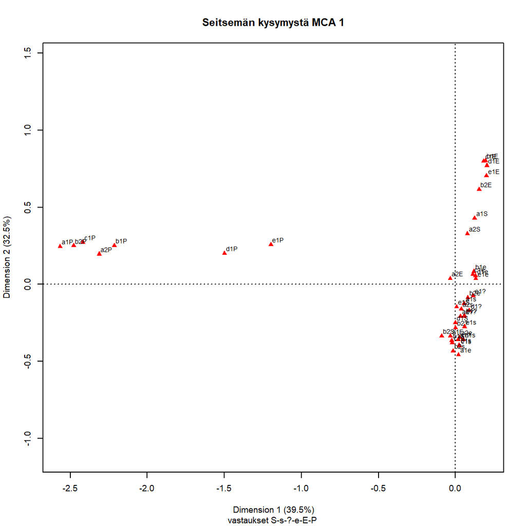

MCA-kartta: viiden vastausvaihtoehdon kysymykset

```r
Qmuuttujat1.mca <- mjca(mcaDat11jh.dat, ps="")

# ps="" muuttujan ja sen kategorian eroitinmerkki
par(cex=0.6)
plot.mjca(Qmuuttujat1.mca,
          main = "Seitsemän kysymystä MCA 1",
          sub = "vastaukset S-s-?-e-E-P ")
```

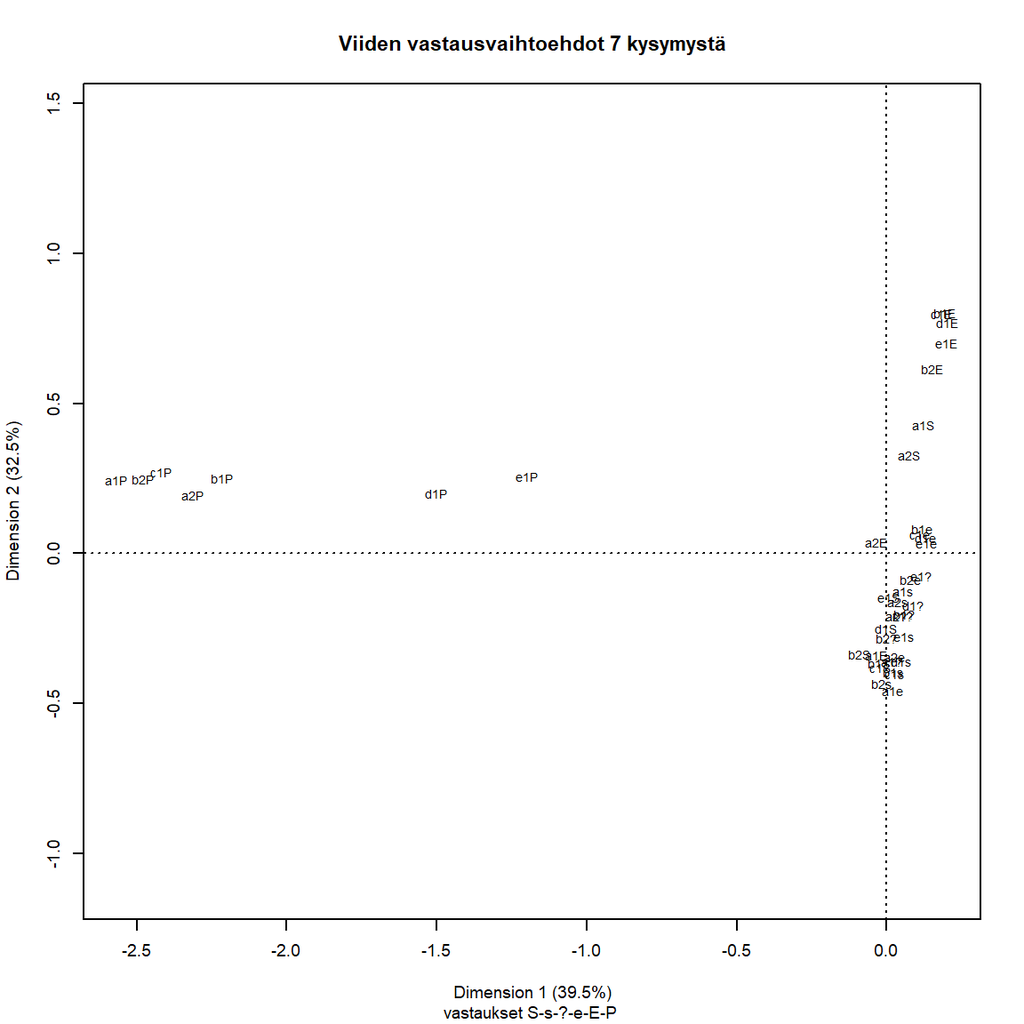

MCA-kartta: viiden vastausvaihtoehdon kysymykset

```r
plot.mjca(Qmuuttujat1.mca, labels = c(2,1),
          main = "Viiden vastausvaihtoehdot 7 kysymystä",
          sub = "vastaukset S-s-?-e-E-P ")
```

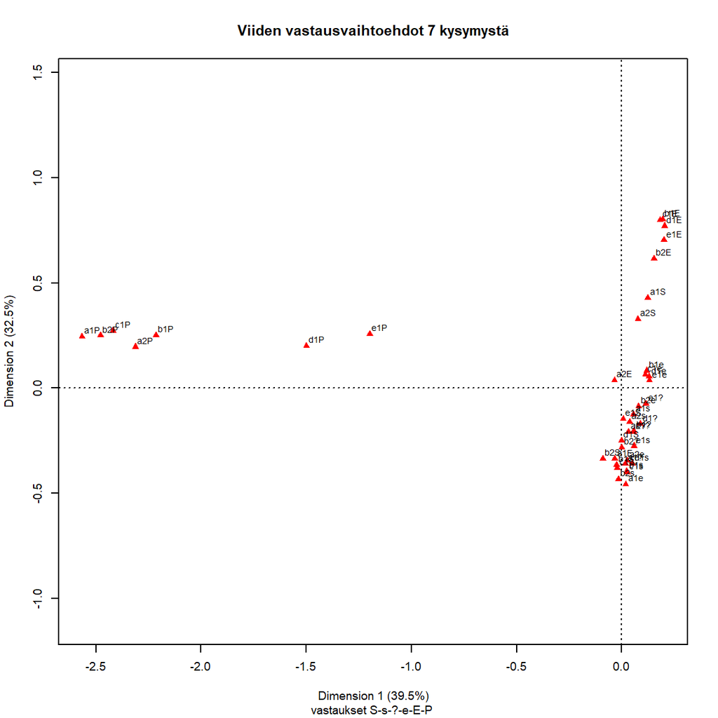

MCA-kartta: viiden vastausvaihtoehdon kysymykset

```r
plot.mjca(Qmuuttujat1.mca, labels = c(1,2),
          main = "Viiden vastausvaihtoehdot 7 kysymystä",
          sub = "vastaukset S-s-?-e-E-P "
          )
```

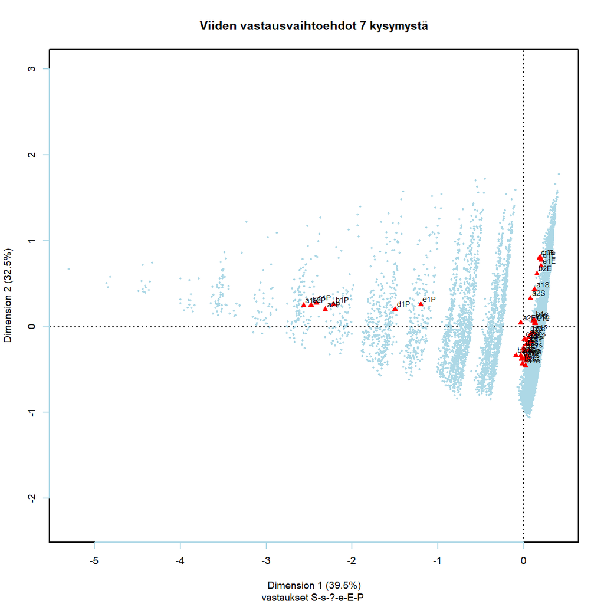

MCA-kartta: viiden vastausvaihtoehdon kysymykset

```r
# EI TOIMI pch = c(19, 1, 17,24)(pisteen symboli) 16.10.20
#
# pch Vector of length 4 giving the type of points to be used for row active and
# supplementary, column active and supplementary points

par(cex=0.6)
plot.mjca(Qmuuttujat1.mca, what = c("all","all"),labels = c(0,2),
          col = c("lightblue", "red"),
          main = "Viiden vastausvaihtoehdot 7 kysymystä",
          sub = "vastaukset S-s-?-e-E-P "
          )
```

```r
summary(Qmuuttujat1.mca)
```

```
##
## Principal inertias (eigenvalues):
##
##  dim    value      %   cum%   scree plot
##  1      0.156867  39.5  39.5  **********
##  2      0.129043  32.5  71.9  *********
##  3      0.064154  16.1  88.0  ****
##  4      0.014818   3.7  91.8  *
##  5      0.008877   2.2  94.0  *
##  6      0.000538   0.1  94.1
##  7      0.000171   0.0  94.2
##  8      7.3e-050   0.0  94.2
##  9      2e-06000   0.0  94.2
##         -------- -----
##  Total: 0.397574
```

[output cut: 46 more lines]

```r
#X11()
# subsetcat = (6,12,18,24,30,36,42) - väärä formaatti
# subsetcat=(1:42)[-c(1:5,7:11,13:17,19:23,24:29,31:35, 37:41)]) väärä formaatti

#subsetcat viittaa muuttujan luokkien indeksiin

eiPvastaukset <- (1:42)[-c(6,12,18,24,30,36,42)]
# eiPvastaukset
#  puuttuva tieto on kuudes kategora kaikilla kysymyksillä
# 1  2  3  4  5  7  8  9 10 11 13 14 15 16 17 19 20 21 22 23 25 26 27 28 29 31
# 32 33 34 35 37 38 39 40 41

mcaDat11jh.dat[1:5,]
```

| a1 | b1 | c1 | d1 | e1 | a2 | b2 |
| --- | --- | --- | --- | --- | --- | --- |
| E | S | ? | ? | ? | S | ? |
| S | E | E | E | S | ? | E |
| s | e | s | E | s | e | e |
| s | e | e | s | ? | s | e |
| S | e | e | e | e | s | e |

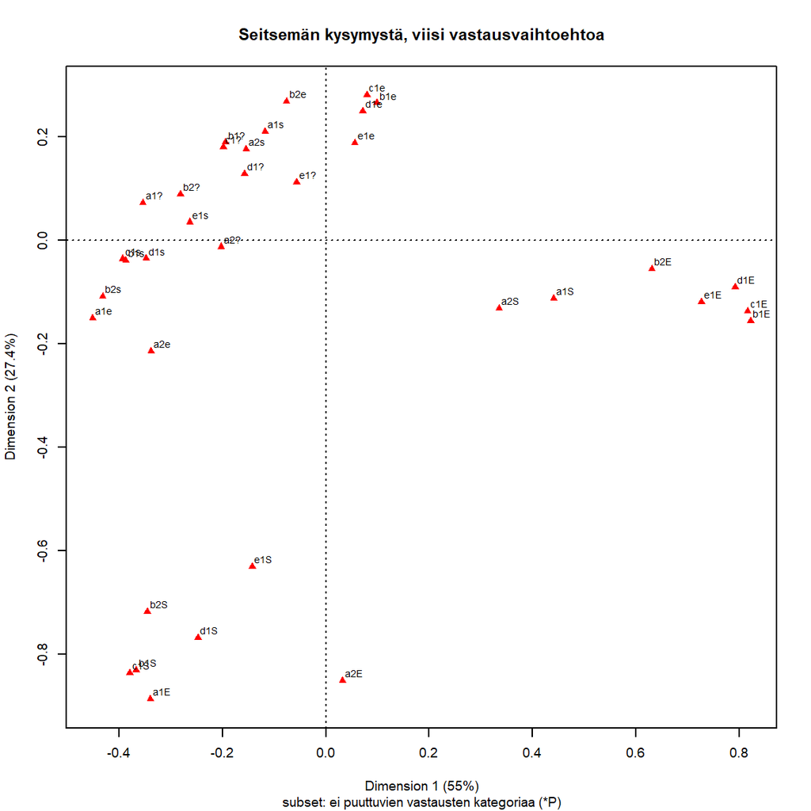

MCA-kartta: viiden vastausvaihtoehdon kysymykset

```r
Qmuuttujat2.mca <- mjca(mcaDat11jh.dat, ps="", subsetcat=eiPvastaukset)

plot.mjca(Qmuuttujat2.mca,
          main="Seitsemän kysymystä, viisi vastausvaihtoehtoa",
          sub = "subset: ei puuttuvien vastausten kategoriaa (*P)")
```

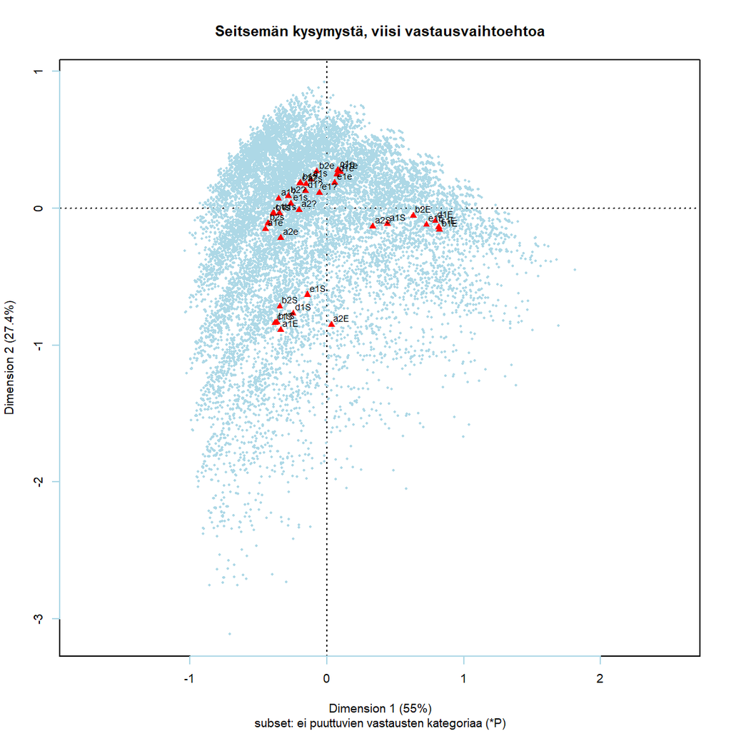

MCA-kartta: viiden vastausvaihtoehdon kysymykset

```r
plot.mjca(Qmuuttujat2.mca,
          what = c("all","all"),labels = c(0,2),
          col = c("lightblue", "red"),
          main="Seitsemän kysymystä, viisi vastausvaihtoehtoa",
          sub = "subset: ei puuttuvien vastausten kategoriaa (*P)")
```

```r
summary(Qmuuttujat2.mca)
```

```
##
## Principal inertias (eigenvalues):
##
##  dim    value      %   cum%   scree plot
##  1      0.129087  55.0  55.0  ***************
##  2      0.064296  27.4  82.4  *******
##  3      0.014807   6.3  88.7  **
##  4      0.008871   3.8  92.5  *
##  5      0.000538   0.2  92.7
##  6      0.000221   0.1  92.8
##  7      0.000156   0.1  92.9
##  8      6.9e-050   0.0  92.9
##  9      1e-06000   0.0  92.9
##         -------- -----
##  Total: 0.234728
```

[output cut: 39 more lines]

```r
# mutta ei hyväksy viimeisiä sarakkeita poistettaviksi (37:41)
#Qmuuttujat3.mca <- mjca(mcaDataJH2.dat, ps="", subsetcat=(1:42)[-c(1:5, 7:11, 13:17, 19:23,25:29,31:35)])

#plot.mjca(mca1Qmuuttujat3)
#summary(mca1Qmuuttujat3)

#mca1Qmuuttujat3 <- mjca(mcaDataJH2.dat, ps="", subsetcat=(1:42)[-c(1:5, 7:11, 13:17, 19:23,25:29,31:35, 37:41)])

#pchlist()
```

### 5.3.1 subset MCA ja täydentävät sarakkeet (19.10.20)

**Jostain syystä en saa toimimaan mjca-funktiossa subsecat - parametrin kanssa täydentäviä muuttujia supcol. Niinpä kartat ovat vähän kehnoja, sillä puuttuvien tietojen kategoriat määrittävät omalta osaltaan koordinaatistoa**

Niiden kontribuutiot ovat isot, ja massat aika pieniä. Esimerkkitapaus, jossa jotkut havainnot vaikuttavat karttaan aivan liikaa!

Käsityönä voisi lisäillä pisteitä karttaan, joka on piirretty ilman puuttuvia tietoja.

```r
# Täydentävät sarakkeet - ei toimi! (19.20.20)
# dim(mcaDat11jh.dat) 7 kysymystä
dim(MCAdata1jh.dat)
```

```
## [1] 32823    26
```

```r
str(MCAdata1jh.dat)
```

```
## tibble [32,823 x 26] (S3: tbl_df/tbl/data.frame)
##  $ Q1am   : Factor w/ 6 levels "S","s","?","e",..: 5 1 2 2 1 6 2 4 2 2 ...
##   ..- attr(*, "label")= chr "Q1a Working mom: warm relationship with children as a not working mom"
##  $ Q1bm   : Factor w/ 6 levels "S","s","?","e",..: 1 5 4 4 4 6 4 3 4 3 ...
##   ..- attr(*, "label")= chr "Q1b Working mom: Preschool child is likely to suffer"
##  $ Q1cm   : Factor w/ 6 levels "S","s","?","e",..: 3 5 2 4 4 6 4 2 4 2 ...
##   ..- attr(*, "label")= chr "Q1c Working woman: Family life suffers when woman has full-time job"
##  $ Q1dm   : Factor w/ 6 levels "S","s","?","e",..: 3 5 5 2 4 6 4 5 4 5 ...
##   ..- attr(*, "label")= chr "Q1d Working woman: What women really want is home and kids"
##  $ Q1em   : Factor w/ 6 levels "S","s","?","e",..: 3 1 2 3 4 6 2 4 4 1 ...
##   ..- attr(*, "label")= chr "Q1e Working woman: Being housewife is as fulfilling as working for pay"
##  $ Q2am   : Factor w/ 6 levels "S","s","?","e",..: 1 3 4 2 2 6 2 5 2 1 ...
##   ..- attr(*, "label")= chr "Q2a Both should contribute to household income"
##  $ Q2bm   : Factor w/ 6 levels "S","s","?","e",..: 3 5 4 4 4 6 2 5 4 1 ...
##   ..- attr(*, "label")= chr "Q2b Men's job earn money, women's job look after home"
##  $ edum   : Factor w/ 8 levels "No formal education",..: 3 6 6 4 3 8 8 7 6 7 ...
##   ..- attr(*, "label")= chr "Highest completed degree of education: Categories for international comparison"
##  $ sostam : Factor w/ 11 levels "Lowest, Bottom, 01",..: 3 7 8 11 7 2 7 11 10 6 ...
##   ..- attr(*, "label")= chr "Top-Bottom self-placement"
##  $ urbrum : Factor w/ 6 levels "A big city","The suburbs or outskirts of a big city",..: 1 1 1 6 1 2 6 2 2 6 ...
##   ..- attr(*, "label")= chr "Place of living: urban - rural"
##  $ maa    : Factor w/ 25 levels "AU","AT","BG",..: 1 1 1 1 1 1 1 1 1 1 ...
##   ..- attr(*, "label")= chr "Country Prefix ISO 3166 Code - alphanumeric"
##  $ ika    : dbl+lbl [1:32823] 58, 59, 40, 20, 72, 68, 64, 57, 45, 71, 19, 41, 68, ...
##    ..@ label      : chr "Age of respondent"
##    ..@ format.spss: chr "F3.0"
##    ..@ labels     : Named num [1:6] 15 16 17 18 102 999
##    .. ..- attr(*, "names")= chr [1:6] "15 years" "16 years" "17 years" "18 years" ...
##  $ sp     : Factor w/ 2 levels "m","f": 1 2 2 2 2 1 2 1 2 2 ...
##   ..- attr(*, "label")= chr "Sex of Respondent"
##  $ age_cat: Factor w/ 6 levels "1","2","3","4",..: 5 5 3 1 6 6 5 5 3 6 ...
##  $ ga     : chr [1:32823] "m5" "f5" "f3" "f1" ...
##  $ E      : Factor w/ 8 levels "1","2","3","4",..: 3 6 6 4 3 8 8 7 6 7 ...
##   ..- attr(*, "label")= chr "Highest completed degree of education: Categories for international comparison"
##  $ S      : Factor w/ 11 levels "1","2","3","4",..: 3 7 8 11 7 2 7 11 10 6 ...
##   ..- attr(*, "label")= chr "Top-Bottom self-placement"
##  $ U      : Factor w/ 6 levels "1","2","3","4",..: 1 1 1 6 1 2 6 2 2 6 ...
##   ..- attr(*, "label")= chr "Place of living: urban - rural"
##  $ gaf    : Factor w/ 12 levels "f1","f2","f3",..: 11 5 3 1 6 12 5 11 3 6 ...
##  $ a1     : Factor w/ 6 levels "S","s","?","e",..: 5 1 2 2 1 6 2 4 2 2 ...
##   ..- attr(*, "label")= chr "Q1a Working mom: warm relationship with children as a not working mom"
##  $ b1     : Factor w/ 6 levels "S","s","?","e",..: 1 5 4 4 4 6 4 3 4 3 ...
##   ..- attr(*, "label")= chr "Q1b Working mom: Preschool child is likely to suffer"
##  $ c1     : Factor w/ 6 levels "S","s","?","e",..: 3 5 2 4 4 6 4 2 4 2 ...
##   ..- attr(*, "label")= chr "Q1c Working woman: Family life suffers when woman has full-time job"
##  $ d1     : Factor w/ 6 levels "S","s","?","e",..: 3 5 5 2 4 6 4 5 4 5 ...
##   ..- attr(*, "label")= chr "Q1d Working woman: What women really want is home and kids"
##  $ e1     : Factor w/ 6 levels "S","s","?","e",..: 3 1 2 3 4 6 2 4 4 1 ...
##   ..- attr(*, "label")= chr "Q1e Working woman: Being housewife is as fulfilling as working for pay"
##  $ a2     : Factor w/ 6 levels "S","s","?","e",..: 1 3 4 2 2 6 2 5 2 1 ...
##   ..- attr(*, "label")= chr "Q2a Both should contribute to household income"
##  $ b2     : Factor w/ 6 levels "S","s","?","e",..: 3 5 4 4 4 6 2 5 4 1 ...
##   ..- attr(*, "label")= chr "Q2b Men's job earn money, women's job look after home"
##  - attr(*, "notes")= chr [1:45] "document Plan File: /Users/marcic/Desktop/old/GPS2011 sampling/ISSP2013.sampling" "         .csplan" "         Weight Variable: SampleWeight_Final_" "         Stage 1" ...
```

```r
# Data: 7 kysymystä, täydentävät muuttujat maa, sp, S (status), U (asuinpaikka),
# E (koulutustaso)

mcaDat21jh.dat <- MCAdata1jh.dat %>% select(a1,b1,c1, d1, e1,a2,b2,E,S,U,maa,gaf)
str(mcaDat21jh.dat)
```

```
## tibble [32,823 x 12] (S3: tbl_df/tbl/data.frame)
##  $ a1 : Factor w/ 6 levels "S","s","?","e",..: 5 1 2 2 1 6 2 4 2 2 ...
##   ..- attr(*, "label")= chr "Q1a Working mom: warm relationship with children as a not working mom"
##  $ b1 : Factor w/ 6 levels "S","s","?","e",..: 1 5 4 4 4 6 4 3 4 3 ...
##   ..- attr(*, "label")= chr "Q1b Working mom: Preschool child is likely to suffer"
##  $ c1 : Factor w/ 6 levels "S","s","?","e",..: 3 5 2 4 4 6 4 2 4 2 ...
##   ..- attr(*, "label")= chr "Q1c Working woman: Family life suffers when woman has full-time job"
##  $ d1 : Factor w/ 6 levels "S","s","?","e",..: 3 5 5 2 4 6 4 5 4 5 ...
##   ..- attr(*, "label")= chr "Q1d Working woman: What women really want is home and kids"
##  $ e1 : Factor w/ 6 levels "S","s","?","e",..: 3 1 2 3 4 6 2 4 4 1 ...
##   ..- attr(*, "label")= chr "Q1e Working woman: Being housewife is as fulfilling as working for pay"
##  $ a2 : Factor w/ 6 levels "S","s","?","e",..: 1 3 4 2 2 6 2 5 2 1 ...
##   ..- attr(*, "label")= chr "Q2a Both should contribute to household income"
##  $ b2 : Factor w/ 6 levels "S","s","?","e",..: 3 5 4 4 4 6 2 5 4 1 ...
##   ..- attr(*, "label")= chr "Q2b Men's job earn money, women's job look after home"
##  $ E  : Factor w/ 8 levels "1","2","3","4",..: 3 6 6 4 3 8 8 7 6 7 ...
##   ..- attr(*, "label")= chr "Highest completed degree of education: Categories for international comparison"
##  $ S  : Factor w/ 11 levels "1","2","3","4",..: 3 7 8 11 7 2 7 11 10 6 ...
##   ..- attr(*, "label")= chr "Top-Bottom self-placement"
##  $ U  : Factor w/ 6 levels "1","2","3","4",..: 1 1 1 6 1 2 6 2 2 6 ...
##   ..- attr(*, "label")= chr "Place of living: urban - rural"
##  $ maa: Factor w/ 25 levels "AU","AT","BG",..: 1 1 1 1 1 1 1 1 1 1 ...
##   ..- attr(*, "label")= chr "Country Prefix ISO 3166 Code - alphanumeric"
##  $ gaf: Factor w/ 12 levels "f1","f2","f3",..: 11 5 3 1 6 12 5 11 3 6 ...
##  - attr(*, "notes")= chr [1:45] "document Plan File: /Users/marcic/Desktop/old/GPS2011 sampling/ISSP2013.sampling" "         .csplan" "         Weight Variable: SampleWeight_Final_" "         Stage 1" ...
```

```r
dim(mcaDat21jh.dat)
```

```
## [1] 32823    12
```

```r
glimpse(mcaDat21jh.dat)
```

```
## Rows: 32,823
## Columns: 12
## $ a1  <fct> E, S, s, s, S, P, s, e, s, s, e, s, s, s, S, P, s, ?, s, s, s, ...
## $ b1  <fct> S, E, e, e, e, P, e, ?, e, ?, ?, E, e, e, ?, ?, e, ?, P, e, e, ...
## $ c1  <fct> ?, E, s, e, e, P, e, s, e, s, s, ?, e, e, ?, s, e, s, ?, e, e, ...
## $ d1  <fct> ?, E, E, s, e, P, e, E, e, E, ?, e, e, E, ?, s, ?, e, s, P, e, ...
## $ e1  <fct> ?, S, s, ?, e, P, s, e, e, S, e, s, s, e, s, s, S, s, s, s, e, ...
## $ a2  <fct> S, ?, e, s, s, P, s, E, s, S, s, s, s, s, S, s, s, ?, s, s, s, ...
## $ b2  <fct> ?, E, e, e, e, P, s, E, e, S, e, e, e, e, E, e, ?, E, s, e, e, ...
## $ E   <fct> 3, 6, 6, 4, 3, P, P, 7, 6, 7, 4, 6, 3, 6, 6, 2, 2, 7, 6, 6, 3, ...
## $ S   <fct> 3, 7, 8, P, 7, 2, 7, P, 10, 6, 4, 5, P, 7, 9, 3, P, 8, 7, 6, 5,...
## $ U   <fct> 1, 1, 1, P, 1, 2, P, 2, 2, P, 2, 2, 3, 2, 2, 5, 5, 1, 2, 5, 4, ...
## $ maa <fct> AU, AU, AU, AU, AU, AU, AU, AU, AU, AU, AU, AU, AU, AU, AU, AU,...
## $ gaf <fct> m5, f5, f3, f1, f6, m6, f5, m5, f3, f6, m1, m3, f6, f2, m1, m6,...
```

```r
# kysymysten puuttuvat pois subsetcat=(1:42)[-c(6,12,18,24,30,36,42)]
# subset2 <- (1:50)[-c(6,12,18,24,30,36,42)]
# eiPvastvastaukset : vastauskategorioiden indeksit ilman P-luokkaa
# subsetcat=(1:50)[-c(6,12,18,24,30,36,42,50)],
# maa ja gaf - ei puuttuvia tietoja
#
mcaDat21jh.dat$E %>% fct_count() # P-kategoria 50
```

| f | n |
| --- | --- |
| 1 | 491 |
| 2 | 1531 |
| 3 | 7811 |
| 4 | 7115 |
| 5 | 5658 |
| 6 | 5147 |
| 7 | 4762 |
| P | 308 |

```r
mcaDat21jh.dat$S %>% fct_count() # P-kategoria 61
```

| f | n |
| --- | --- |
| 1 | 562 |
| 2 | 866 |
| 3 | 2221 |
| 4 | 3346 |
| 5 | 6798 |
| 6 | 6889 |
| 7 | 5778 |
| 8 | 3477 |
| 9 | 667 |
| 10 | 442 |
| P | 1777 |

```r
mcaDat21jh.dat$U %>% fct_count() # P-kategoria 67
```

| f | n |
| --- | --- |
| 1 | 8442 |
| 2 | 4386 |
| 3 | 9203 |
| 4 | 8646 |
| 5 | 1902 |
| P | 244 |

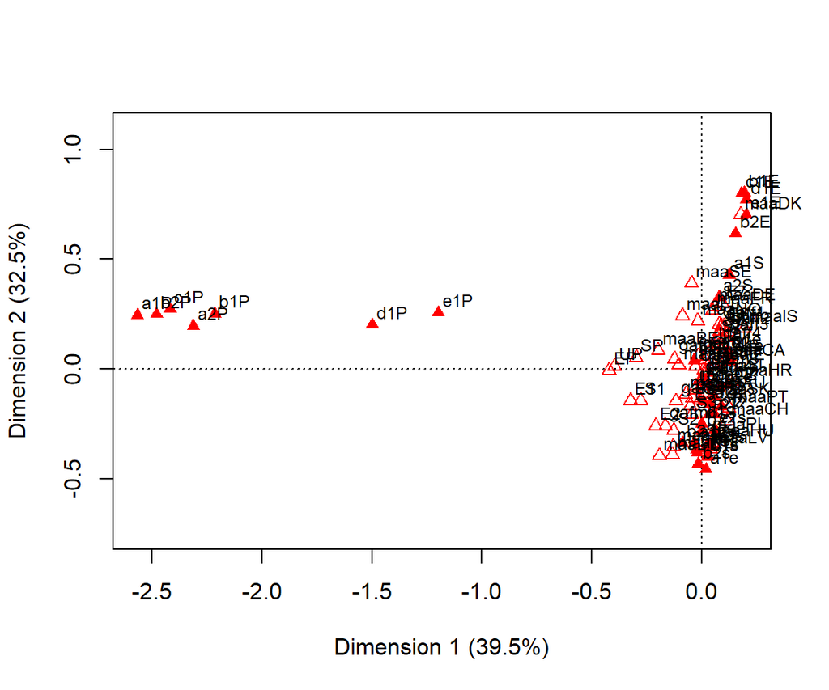

```r
# Täydäntävät sarakkeet, koko aineisto

 # mcaDat21jh.dat[1:10,1:8]

 QjaMuut1.mca <- mjca(mcaDat21jh.dat, ps = "",
               supcol = 8:12
               )

plot(QjaMuut1.mca)
```

```r
# QjaMuut1.mca - ei toimi
summary(QjaMuut1.mca)
```

```
##
## Principal inertias (eigenvalues):
##
##  dim    value      %   cum%   scree plot
##  1      0.156867  39.5  39.5  **********
##  2      0.129043  32.5  71.9  *********
##  3      0.064154  16.1  88.0  ****
##  4      0.014818   3.7  91.8  *
##  5      0.008877   2.2  94.0  *
##  6      0.000538   0.1  94.1
##  7      0.000171   0.0  94.2
##  8      7.3e-050   0.0  94.2
##  9      2e-06000   0.0  94.2
##         -------- -----
##  Total: 0.397574
```

[output cut: 108 more lines]

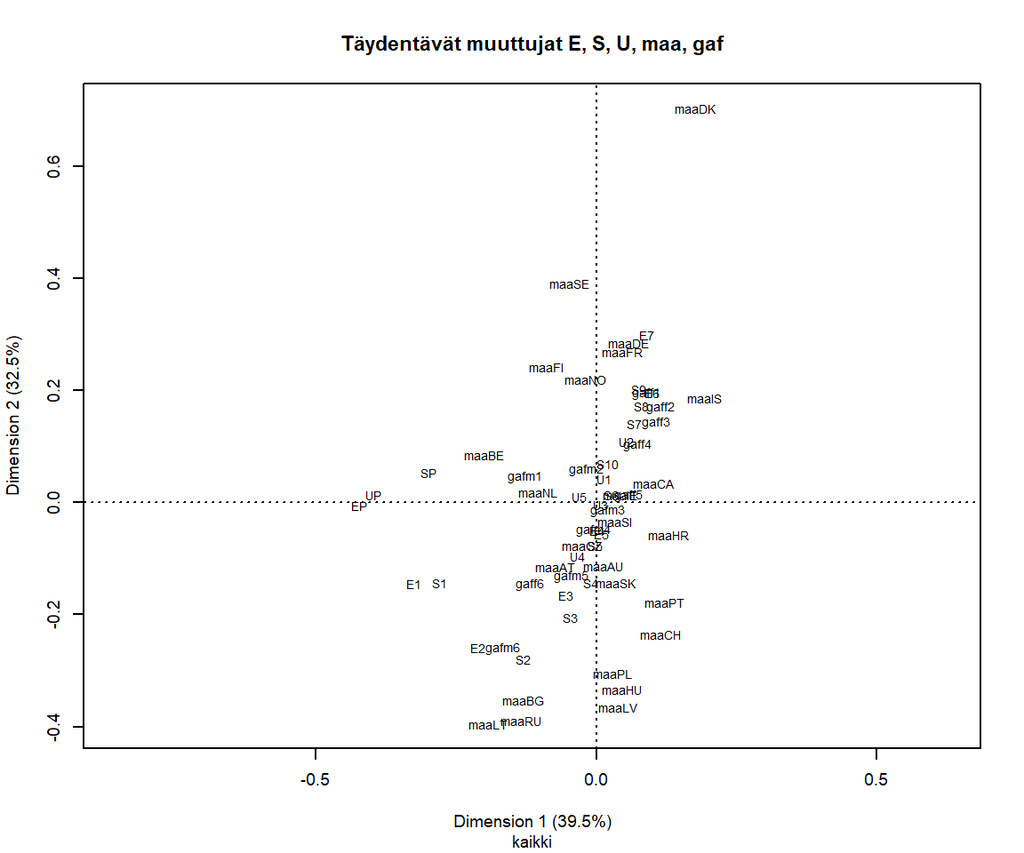

```r
par(cex = 0.6)
plot(QjaMuut1.mca,
     what = c("none", "passive"),
     labels = c(1,1),
     collabels = c("both"),
     main = "Täydentävät muuttujat E, S, U, maa, gaf",
     sub = "kaikki")
```

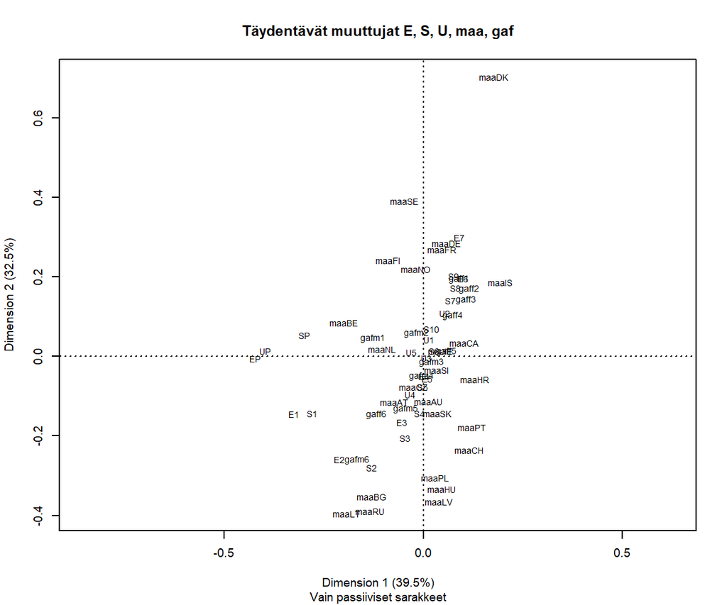

```r
par(cex = 0.6)
plot(QjaMuut1.mca,
     what = c("none", "passive"),
     labels = c(0,1),
     collabels = c("both"),
     main = "Täydentävät muuttujat E, S, U, maa, gaf",
     sub = "Vain passiiviset sarakkeet")
```

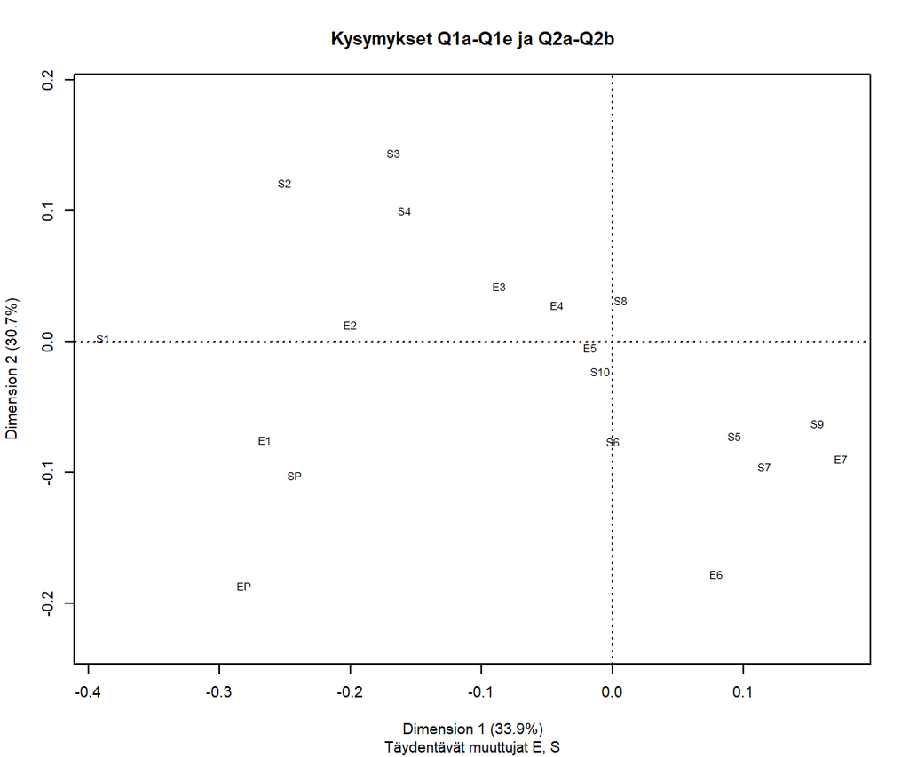

```r
#str(eiPvastaukset)

# Täydentävät pisteet kuva kerrallaan E ja S
QjaMuut2.mca <- mjca(mcaDat21jh.dat, ps = "",
               supcol = 8:9)

plot(QjaMuut2.mca,
     what = c("none", "passive"),
     labels = c(0,1),
     collabels = c("both"),
     main = "Kysymykset Q1a-Q1e ja Q2a-Q2b",
     sub = "Täydentävät muuttujat E, S"
     )
```

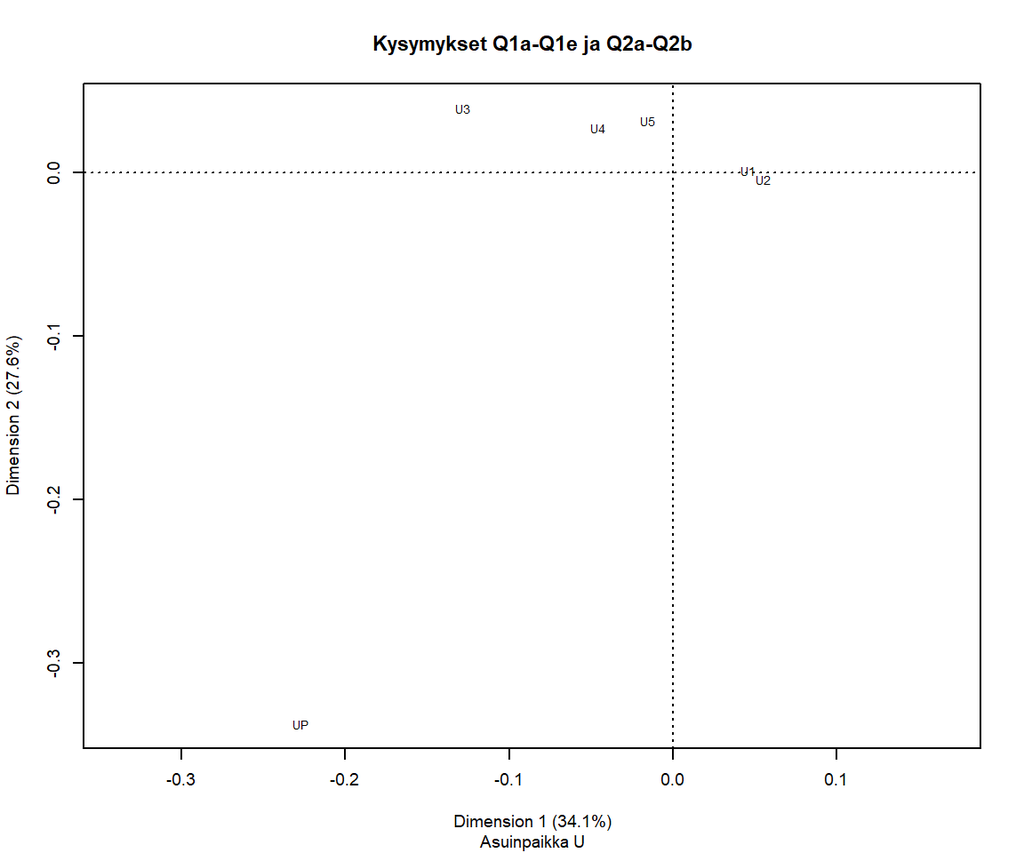

```r
# Täydentävät pisteet kuva kerrallaan: asuinpaikka U
QjaMuut3.mca <- mjca(mcaDat21jh.dat, ps = "",
               supcol = 10)

plot(QjaMuut3.mca,
     what = c("none", "passive"),
     labels = c(0,1),
     collabels = c("both"),
     main = "Kysymykset Q1a-Q1e ja Q2a-Q2b",
     sub = "Asuinpaikka U"
     )
```

```r
dim(mcaDat21jh.dat)
```

```
## [1] 32823    12
```

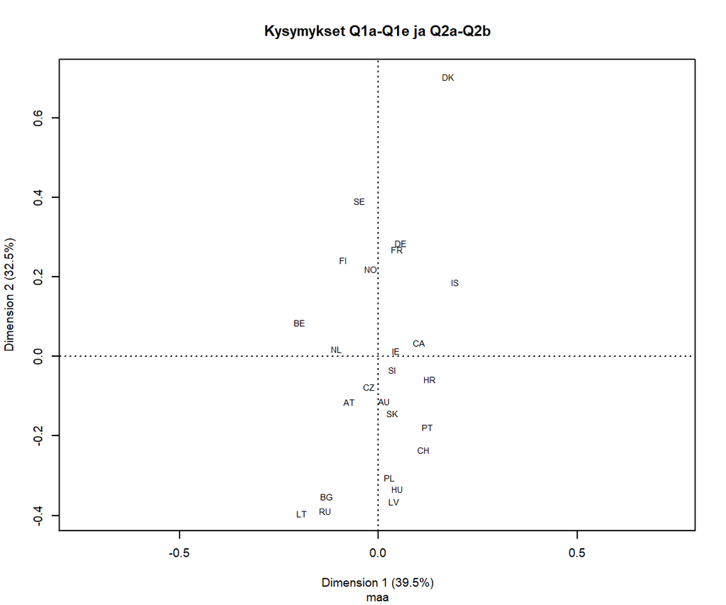

```r
# Täydentävät pisteet kuva kerrallaan: maa

QjaMuut4.mca <- mjca(mcaDat21jh.dat[,c(1:7,11)], ps = "",
               supcol = 8)
plot(QjaMuut4.mca,
     what = c("none", "passive"),
     labels = c(0,1),
     collabels = c("level"),
     main = "Kysymykset Q1a-Q1e ja Q2a-Q2b",
     sub = "maa"
     )
```

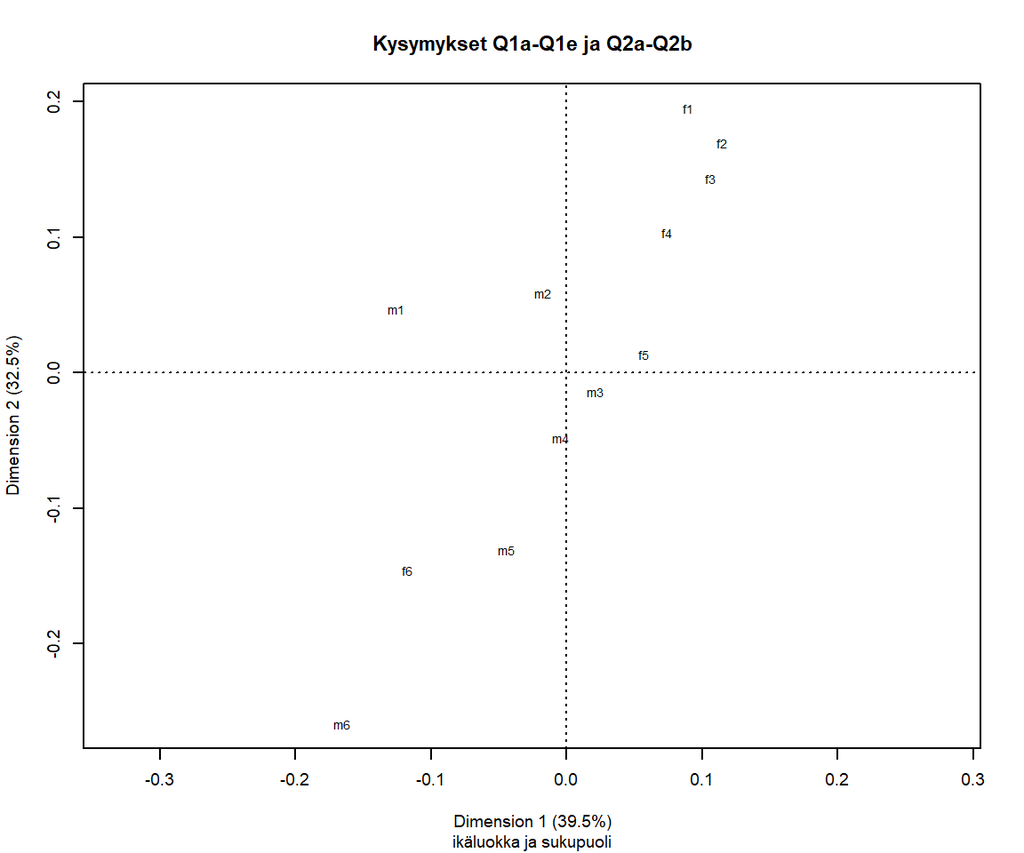

```r
# Täydentävät pisteet kuva kerrallaan: maa

QjaMuut5.mca <- mjca(mcaDat21jh.dat[,c(1:7,12)], ps = "",
               supcol = 8)
plot(QjaMuut5.mca,
     what = c("none", "passive"),
     labels = c(0,1),
     collabels = c("level"),
     main = "Kysymykset Q1a-Q1e ja Q2a-Q2b",
     sub = "ikäluokka ja sukupuoli"
     )
```

```r
# Osajoukon analyysi ja täydentävät sarakkeet supcol = 8:12 ei toiminut
#eikä toimi tämä
#TestsubQjaMuut1.mca <- mjca(mcaDat21jh.dat[,c(1:7, 8)], ps="",
#                       subsetcat = c(eiPvastaukset),
#                       supcol=8
#                       )
#plot(TestsubQjaMuut1.mca)
#TestsubQjaMuut1.mca

# plot(subQjaMuut1.mca)
# summary(subQjaMuut1.mca)
```